# Validating a Human-AI Trust Scale

Oliver Lack Data61 CSIRO

2022 - 2023

# Analyses

## Summary Statistics

### Study 1 - Performance

#### Group Count

| Condition | Autonomous_Car | Cell_Select | DataDoc |
| --- | --- | --- | --- |
| HP | 44 | 45 | 45 |
| LP | 46 | 45 | 45 |

#### Demographics

**Age**

| Mean | SD | Min | Max | Median |
| --- | --- | --- | --- | --- |
| 34.86 | 13.17 | 18 | 79 | 32 |

**Gender**

| Gender | n |
| --- | --- |
| 4 | 1 |
| Female | 128 |
| Male | 136 |
| Other | 5 |

**Education**

| Education | n |
| --- | --- |
| 1 | 3 |
| 2 | 28 |
| 3 | 68 |
| 4 | 30 |
| 5 | 105 |
| 6 | 36 |

#### Full Summary

| AI_Application | Condition | Mean | SD | Min | Max | Median | Score |
| --- | --- | --- | --- | --- | --- | --- | --- |
| Car | HP | 4.57 | 1.46 | 1.00 | 7.00 | 5.00 | Human_Trust_Propensity |
| Car | LP | 4.53 | 1.26 | 1.75 | 7.00 | 4.75 | Human_Trust_Propensity |
| CellSelect | HP | 4.09 | 1.56 | 1.00 | 7.00 | 4.00 | Human_Trust_Propensity |
| CellSelect | LP | 4.40 | 1.41 | 1.25 | 6.50 | 4.50 | Human_Trust_Propensity |
| DataDoc | HP | 4.18 | 1.68 | 1.00 | 6.75 | 4.50 | Human_Trust_Propensity |
| DataDoc | LP | 4.28 | 1.54 | 1.00 | 7.00 | 4.50 | Human_Trust_Propensity |
| Car | HP | 4.67 | 1.22 | 1.33 | 7.00 | 4.83 | Machine_Trust_Propensity |
| Car | LP | 5.00 | 0.87 | 2.50 | 6.17 | 5.25 | Machine_Trust_Propensity |
| CellSelect | HP | 4.82 | 1.14 | 1.00 | 6.17 | 5.00 | Machine_Trust_Propensity |
| CellSelect | LP | 4.95 | 0.84 | 2.00 | 6.17 | 5.00 | Machine_Trust_Propensity |
| DataDoc | HP | 4.61 | 1.11 | 1.33 | 6.17 | 4.83 | Machine_Trust_Propensity |
| DataDoc | LP | 4.67 | 1.13 | 1.33 | 6.17 | 5.00 | Machine_Trust_Propensity |
| Car | HP | 4.55 | 1.17 | 2.08 | 7.00 | 4.54 | TIAS |
| Car | LP | 2.95 | 0.79 | 1.50 | 4.33 | 2.96 | TIAS |
| CellSelect | HP | 5.03 | 0.87 | 3.50 | 6.58 | 5.25 | TIAS |
| CellSelect | LP | 3.38 | 0.85 | 1.92 | 5.83 | 3.25 | TIAS |
| DataDoc | HP | 4.66 | 1.03 | 2.50 | 7.00 | 4.67 | TIAS |
| DataDoc | LP | 2.66 | 1.05 | 1.00 | 5.58 | 2.58 | TIAS |
| Car | HP | 4.23 | 1.88 | 1.00 | 7.00 | 4.67 | Behavioural_Measure |
| Car | LP | 2.90 | 1.44 | 1.00 | 5.33 | 2.67 | Behavioural_Measure |
| CellSelect | HP | 5.04 | 1.15 | 1.00 | 7.00 | 5.00 | Behavioural_Measure |
| CellSelect | LP | 2.82 | 1.53 | 1.00 | 7.00 | 2.33 | Behavioural_Measure |
| DataDoc | HP | 5.21 | 0.85 | 3.33 | 7.00 | 5.00 | Behavioural_Measure |
| DataDoc | LP | 2.10 | 1.52 | 1.00 | 6.67 | 1.00 | Behavioural_Measure |

#### Application Summary

| Score | AI_Application | Mean | SD | Median | Min | Max |
| --- | --- | --- | --- | --- | --- | --- |
| Human Trust Propensity | Car | 4.55 | 1.36 | 4.75 | 1.00 | 7.00 |
| Human Trust Propensity | Cell Select | 4.24 | 1.49 | 4.25 | 1.00 | 7.00 |
| Human Trust Propensity | DataDoc | 4.23 | 1.60 | 4.50 | 1.00 | 7.00 |
| Human Trust Propensity | Airline | 4.47 | 1.48 | 4.75 | 1.00 | 7.00 |
| Machine Trust Propensity | Car | 4.84 | 1.06 | 5.00 | 1.33 | 7.00 |
| Machine Trust Propensity | Cell Select | 4.89 | 1.00 | 5.00 | 1.00 | 6.17 |
| Machine Trust Propensity | DataDoc | 4.64 | 1.12 | 5.00 | 1.33 | 6.17 |
| Machine Trust Propensity | Airline | 4.69 | 1.13 | 4.83 | 1.17 | 7.00 |
| TIAS Score | Car | 3.73 | 1.27 | 3.62 | 1.50 | 7.00 |
| TIAS Score | Cell Select | 4.20 | 1.19 | 3.96 | 1.92 | 6.58 |
| TIAS Score | DataDoc | 3.66 | 1.44 | 3.62 | 1.00 | 7.00 |
| TIAS Score | Airline | 4.00 | 1.36 | 4.17 | 1.00 | 6.83 |
| Behavioural Measure | Car | 3.55 | 1.79 | 3.67 | 1.00 | 7.00 |
| Behavioural Measure | Cell Select | 3.93 | 1.75 | 4.33 | 1.00 | 7.00 |
| Behavioural Measure | DataDoc | 3.65 | 1.99 | 4.00 | 1.00 | 7.00 |
| Behavioural Measure | Airline | 4.18 | 1.95 | 5.00 | 1.00 | 7.00 |

#### Means Comparison

| AI_Application_H | Condition_H | TIAS_Mean1 | Behavioural_Mean1 | AI_Application_L | Condition_L | TIAS_Mean2 | Behavioural_Mean2 |
| --- | --- | --- | --- | --- | --- | --- | --- |
| Car | HP | 4.55 | 4.23 | Car | LP | 2.95 | 2.90 |
| CellSelect | HP | 5.03 | 5.04 | CellSelect | LP | 3.38 | 2.82 |
| DataDoc | HP | 4.66 | 5.21 | DataDoc | LP | 2.66 | 2.10 |

### Study 2 - Integrity

#### Group Count

| Condition | Autonomous_Car | Cell_Select | Airline |
| --- | --- | --- | --- |
| HI | 45 | 45 | 45 |
| LI | 46 | 44 | 45 |

#### Demographics

**Age**

| Mean | SD | Min | Max | Median |
| --- | --- | --- | --- | --- |
| 37.43 | 13.83 | 18 | 77 | 34 |

**Gender**

| Gender | n |
| --- | --- |
| 4 | 2 |
| Female | 130 |
| Male | 135 |
| Other | 3 |

**Education**

| Education | n |
| --- | --- |
| 1 | 2 |
| 2 | 37 |
| 3 | 45 |
| 4 | 32 |
| 5 | 118 |
| 6 | 36 |

#### Full Summary

| AI_Application | Condition | Mean | SD | Min | Max | Median | Score |
| --- | --- | --- | --- | --- | --- | --- | --- |
| Airline | HI | 4.45 | 1.47 | 1.00 | 7.00 | 4.75 | Human_Trust_Propensity |
| Airline | LI | 4.49 | 1.50 | 1.00 | 7.00 | 4.75 | Human_Trust_Propensity |
| Car | HI | 3.92 | 1.47 | 1.00 | 7.00 | 4.25 | Human_Trust_Propensity |
| Car | LI | 4.23 | 1.49 | 1.25 | 7.00 | 4.50 | Human_Trust_Propensity |
| CellSelect | HI | 4.83 | 1.41 | 1.00 | 7.00 | 5.00 | Human_Trust_Propensity |
| CellSelect | LI | 4.12 | 1.67 | 1.00 | 7.00 | 4.00 | Human_Trust_Propensity |
| Airline | HI | 4.72 | 1.00 | 1.17 | 6.33 | 4.67 | Machine_Trust_Propensity |
| Airline | LI | 4.65 | 1.25 | 2.00 | 7.00 | 5.00 | Machine_Trust_Propensity |
| Car | HI | 4.62 | 0.89 | 2.00 | 6.33 | 4.50 | Machine_Trust_Propensity |
| Car | LI | 4.68 | 1.08 | 2.50 | 7.00 | 5.00 | Machine_Trust_Propensity |
| CellSelect | HI | 4.94 | 1.16 | 1.83 | 7.00 | 5.17 | Machine_Trust_Propensity |
| CellSelect | LI | 4.74 | 1.27 | 1.17 | 7.00 | 5.00 | Machine_Trust_Propensity |
| Airline | HI | 4.83 | 0.77 | 3.17 | 6.83 | 4.75 | TIAS |
| Airline | LI | 3.18 | 1.32 | 1.00 | 6.33 | 2.92 | TIAS |
| Car | HI | 4.78 | 1.08 | 2.58 | 6.83 | 4.83 | TIAS |
| Car | LI | 3.03 | 1.10 | 1.08 | 5.67 | 3.17 | TIAS |
| CellSelect | HI | 5.09 | 0.84 | 3.58 | 7.00 | 5.00 | TIAS |
| CellSelect | LI | 2.83 | 0.98 | 1.08 | 5.58 | 2.67 | TIAS |
| Airline | HI | 5.44 | 1.12 | 1.67 | 7.00 | 5.67 | Behaviuoral_Measure |
| Airline | LI | 2.93 | 1.80 | 1.00 | 7.00 | 2.67 | Behaviuoral_Measure |
| Car | HI | 5.04 | 1.62 | 1.00 | 7.00 | 6.00 | Behaviuoral_Measure |
| Car | LI | 3.42 | 1.71 | 1.00 | 7.00 | 3.17 | Behaviuoral_Measure |
| CellSelect | HI | 5.22 | 0.91 | 3.00 | 7.00 | 5.00 | Behaviuoral_Measure |
| CellSelect | LI | 2.92 | 1.51 | 1.00 | 6.00 | 2.67 | Behaviuoral_Measure |

#### Application Summary

| Score | AI_Application | Mean | SD | Median | Min | Max |
| --- | --- | --- | --- | --- | --- | --- |
| Human Trust Propensity | Car | 4.07 | 1.48 | 4.25 | 1.00 | 7.00 |
| Human Trust Propensity | Cell Select | 4.48 | 1.57 | 5.00 | 1.00 | 7.00 |
| Human Trust Propensity | DataDoc | 4.23 | 1.60 | 4.50 | 1.00 | 7.00 |
| Human Trust Propensity | Airline | 4.47 | 1.48 | 4.75 | 1.00 | 7.00 |
| Machine Trust Propensity | Car | 4.65 | 0.98 | 4.83 | 2.00 | 7.00 |
| Machine Trust Propensity | Cell Select | 4.84 | 1.22 | 5.00 | 1.17 | 7.00 |
| Machine Trust Propensity | DataDoc | 4.64 | 1.12 | 5.00 | 1.33 | 6.17 |
| Machine Trust Propensity | Airline | 4.69 | 1.13 | 4.83 | 1.17 | 7.00 |
| TIAS Score | Car | 3.90 | 1.40 | 3.92 | 1.08 | 6.83 |
| TIAS Score | Cell Select | 3.97 | 1.45 | 4.00 | 1.08 | 7.00 |
| TIAS Score | DataDoc | 3.66 | 1.44 | 3.62 | 1.00 | 7.00 |
| TIAS Score | Airline | 4.00 | 1.36 | 4.17 | 1.00 | 6.83 |
| Behavioural Measure | Car | 4.22 | 1.84 | 4.33 | 1.00 | 7.00 |
| Behavioural Measure | Cell Select | 4.08 | 1.69 | 4.33 | 1.00 | 7.00 |
| Behavioural Measure | DataDoc | 3.65 | 1.99 | 4.00 | 1.00 | 7.00 |
| Behavioural Measure | Airline | 4.18 | 1.95 | 5.00 | 1.00 | 7.00 |

#### Means Comparison

| AI_Application_H | Condition_H | TIAS_Mean1 | Behavioural_Mean1 | AI_Application_L | Condition_L | TIAS_Mean2 | Behavioural_Mean2 |
| --- | --- | --- | --- | --- | --- | --- | --- |
| Airline | HI | 4.83 | 5.44 | Airline | LI | 3.18 | 2.93 |
| Car | HI | 4.78 | 5.04 | Car | LI | 3.03 | 3.42 |
| CellSelect | HI | 5.09 | 5.22 | CellSelect | LI | 2.83 | 2.92 |

## Violin/Box-Plot Visualisation

**Measure**

### TIAS

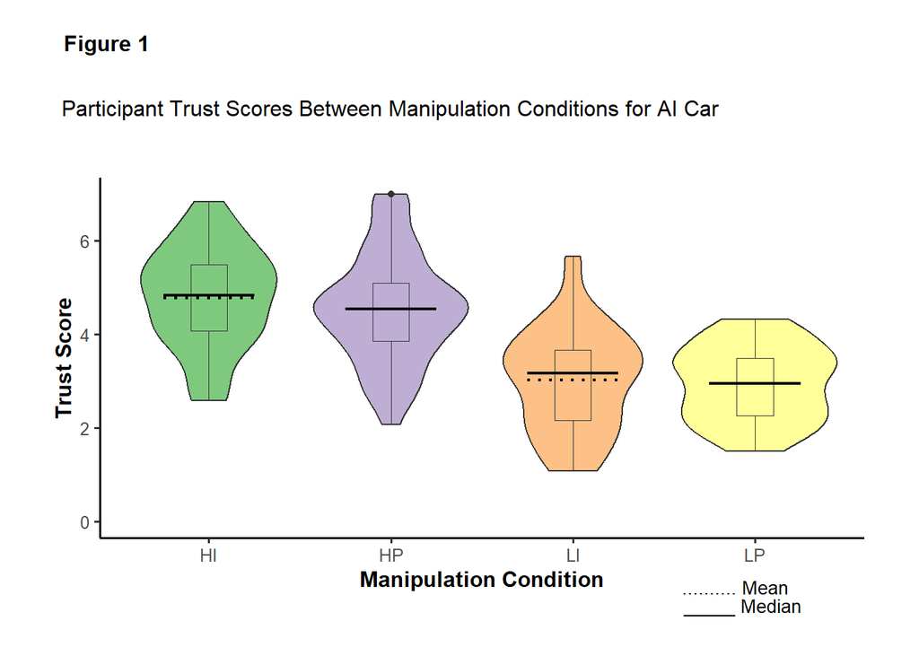

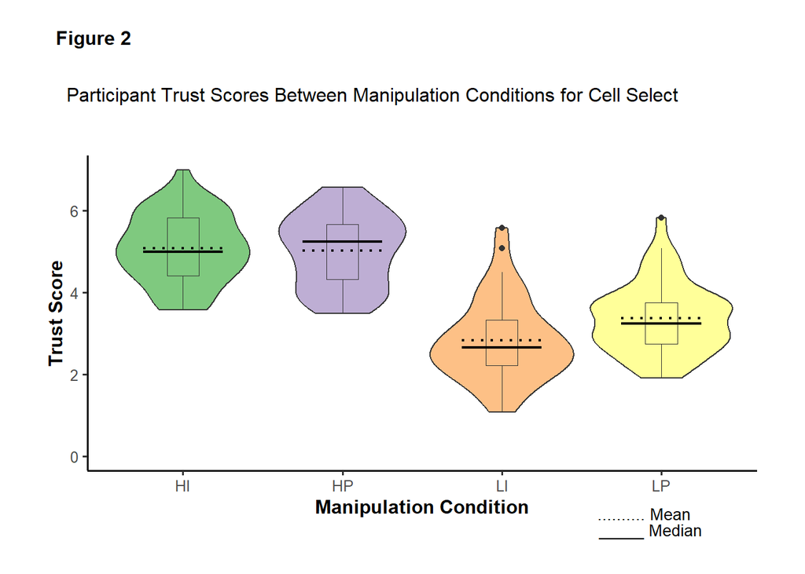

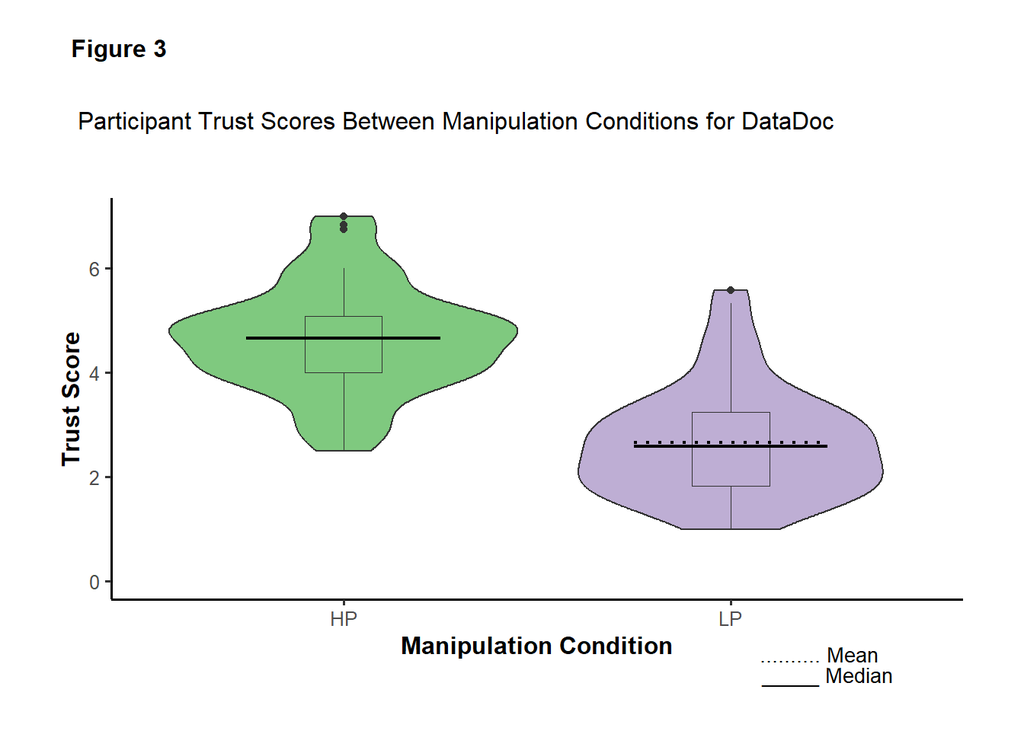

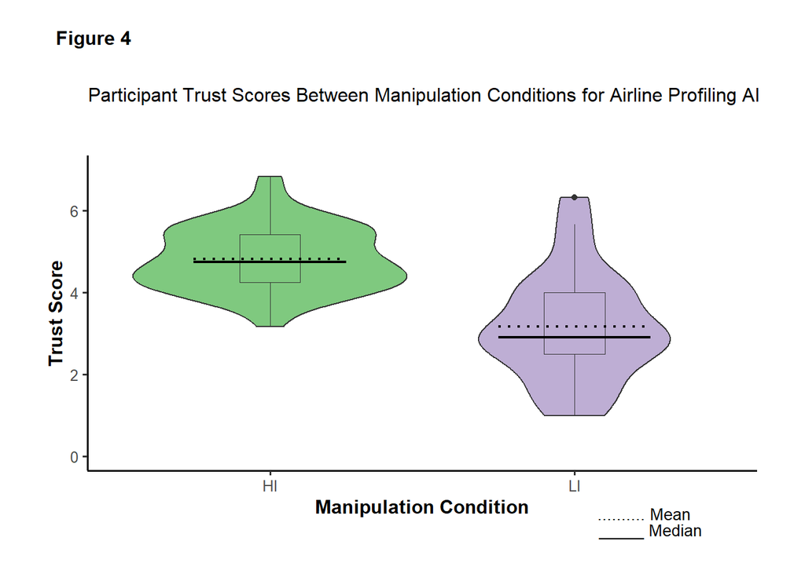

### Behavioural Measure

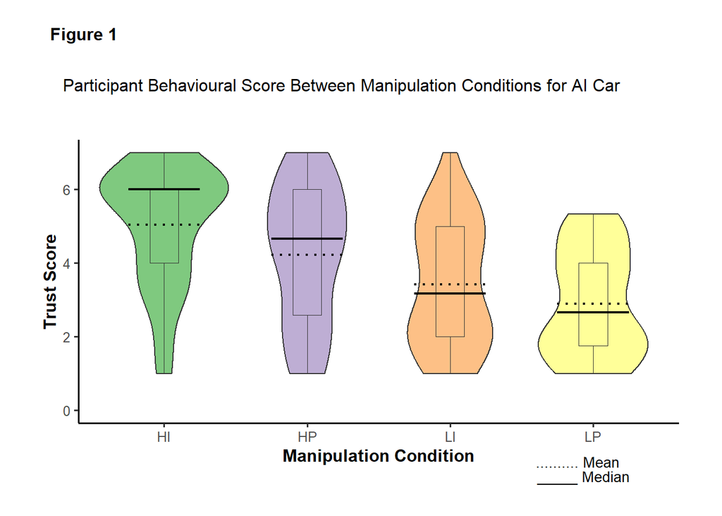

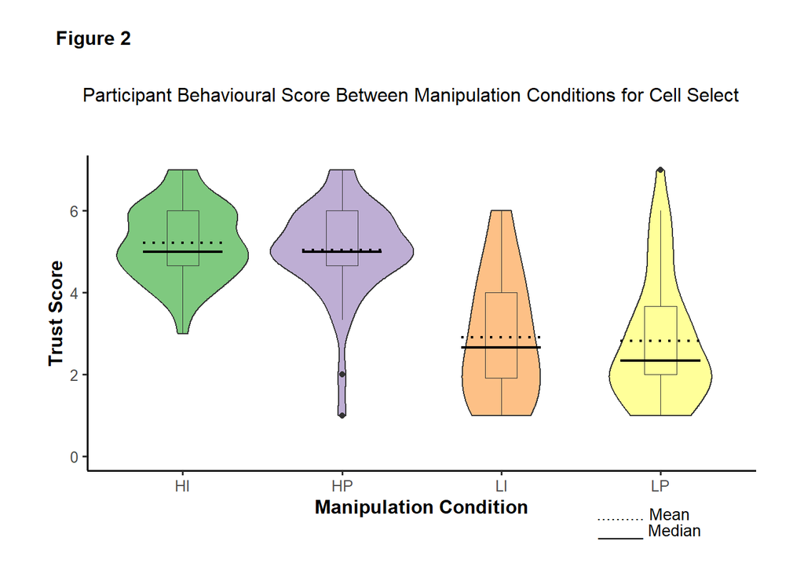

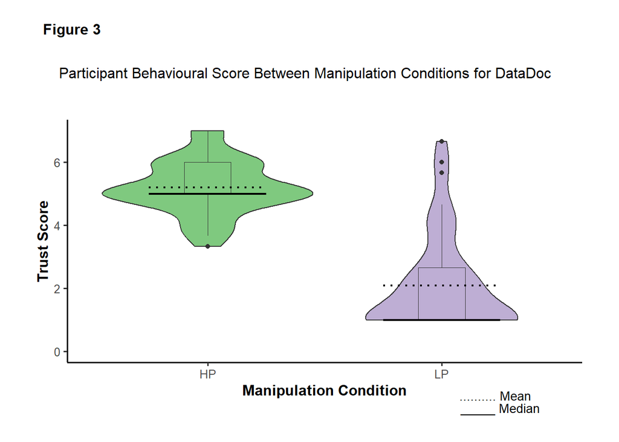

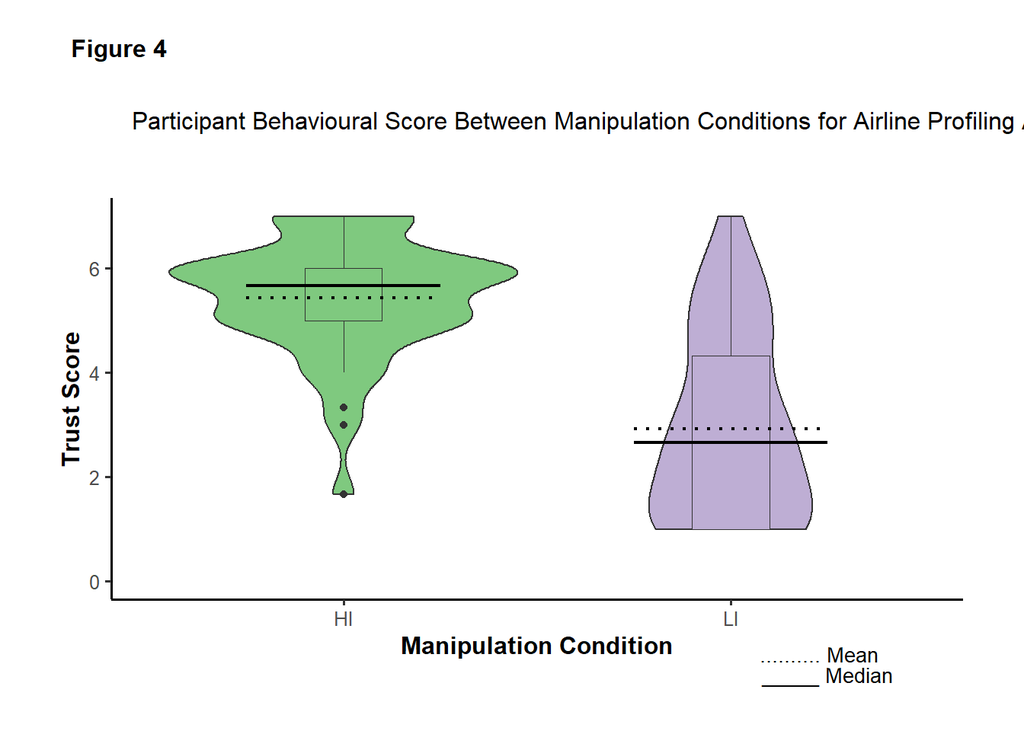

## Jitter-Plot Visualisation

**Meausre**

### TIAS

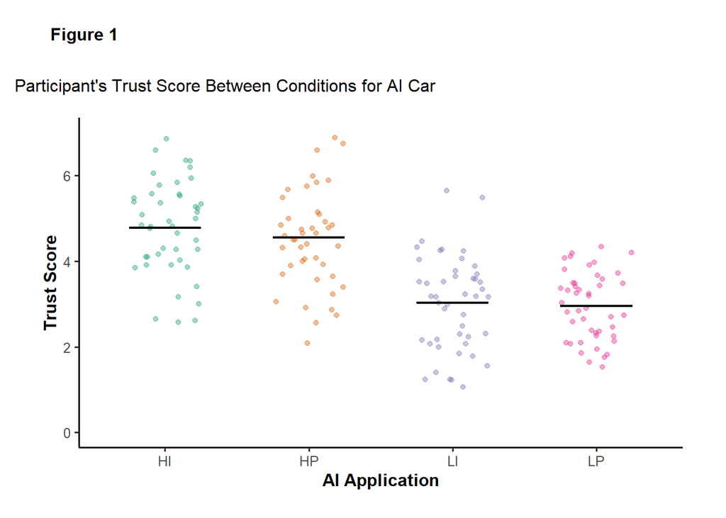

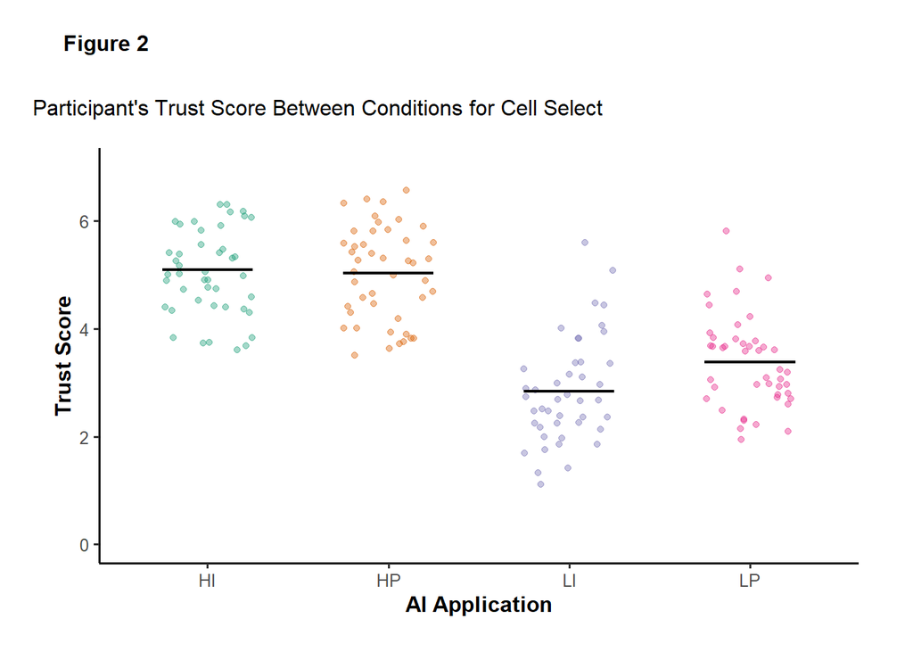

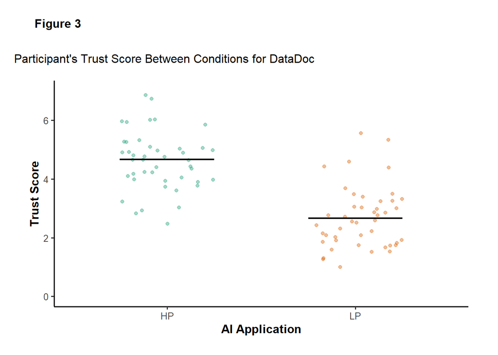

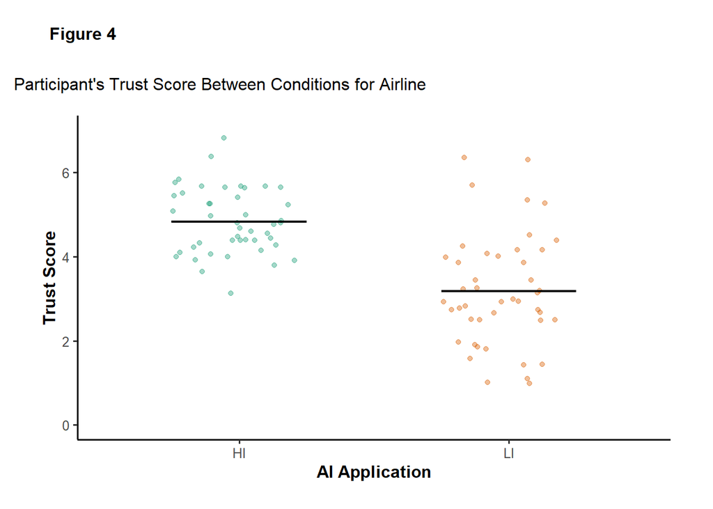

### Behaviuoral Measure

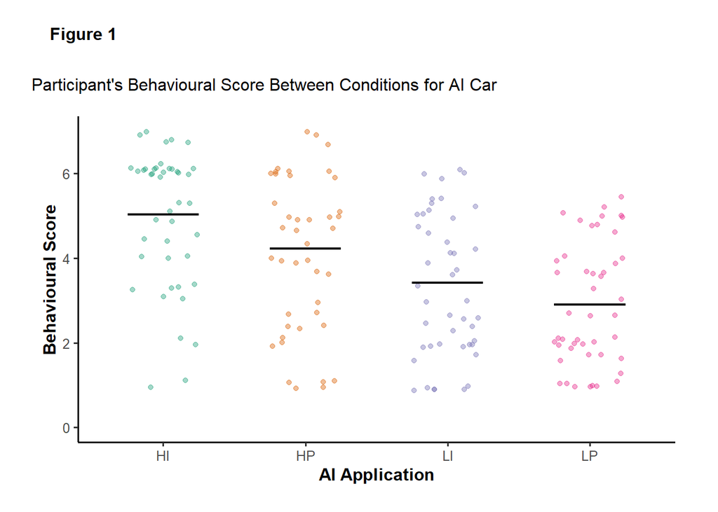

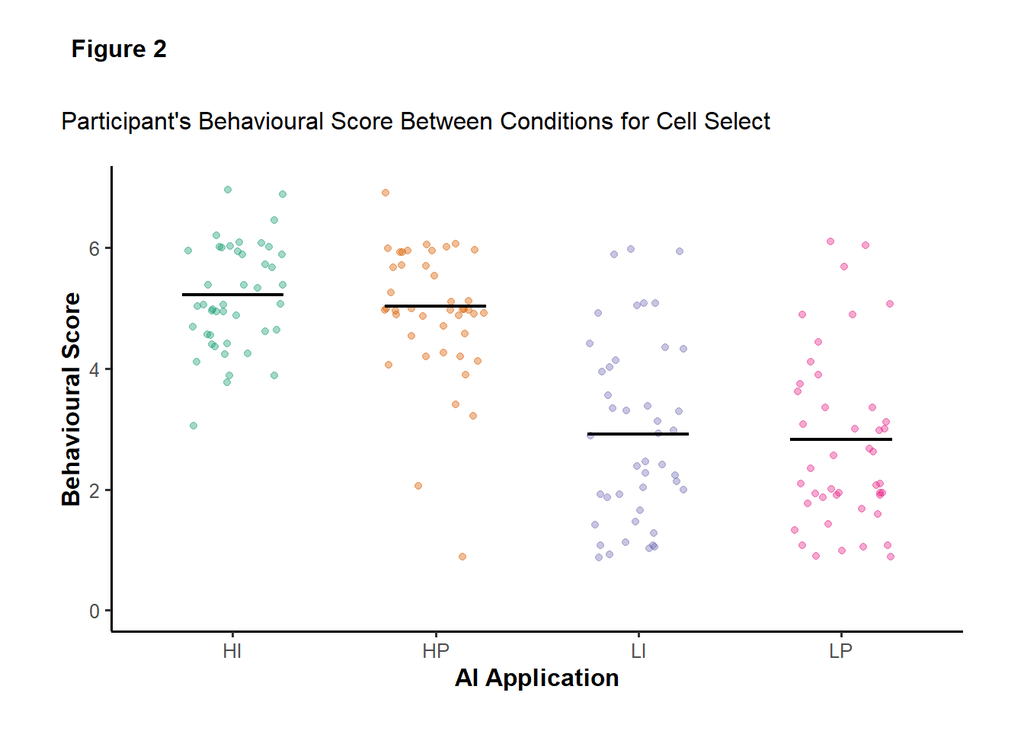

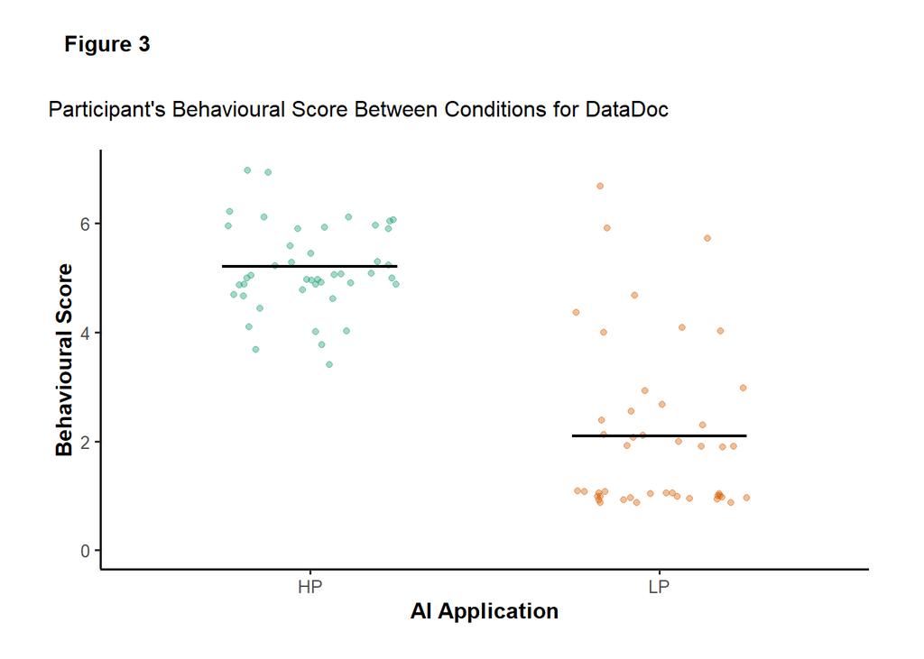

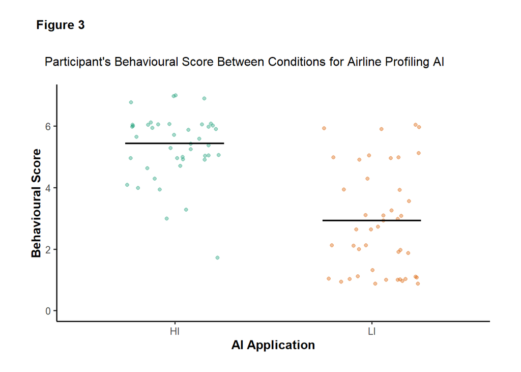

## Scatterplot Visualisation

### TIAS/Behavioural_Measure

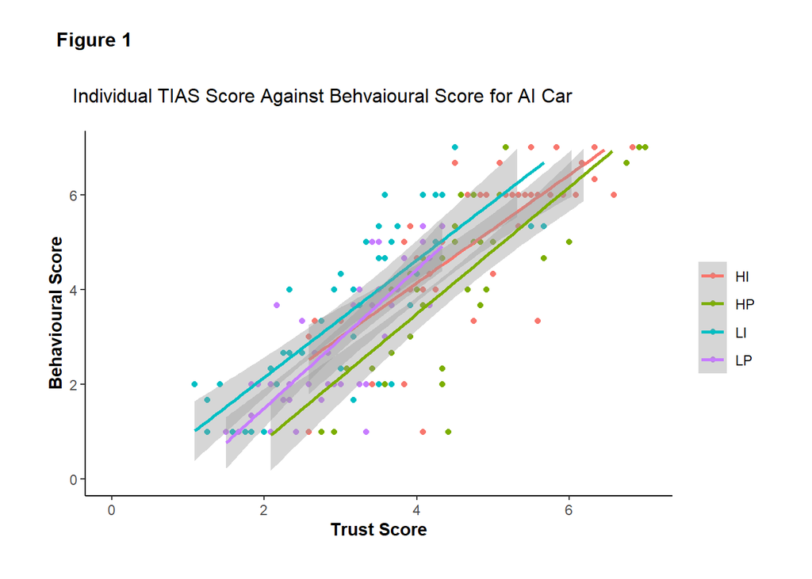

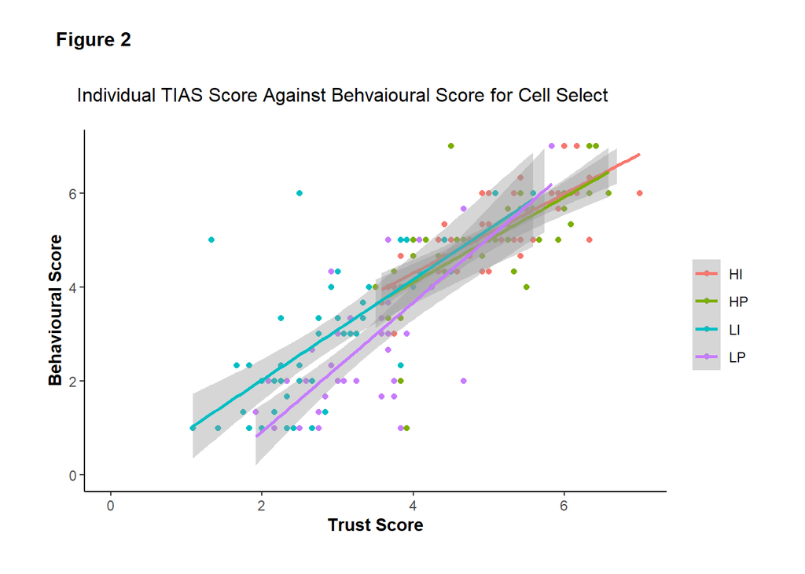

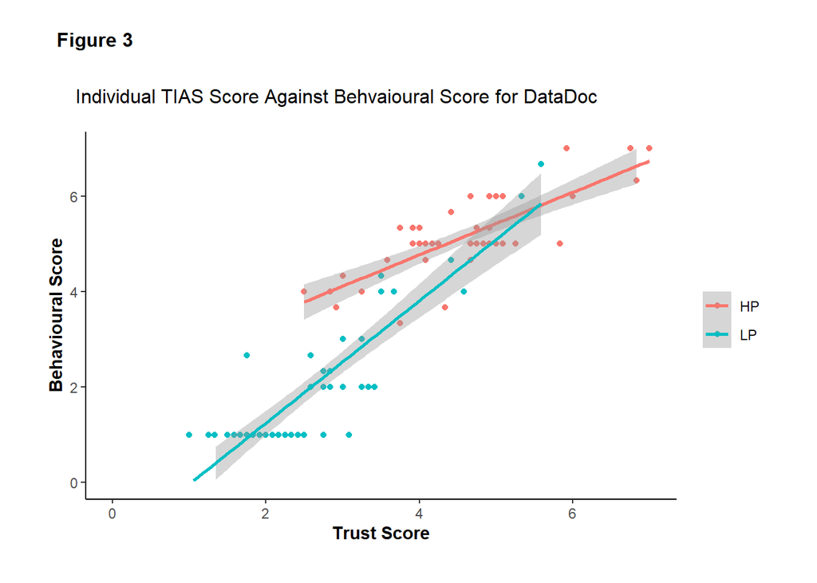

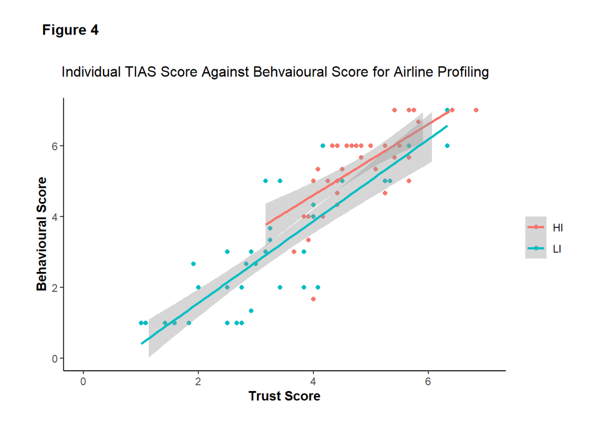

### TIAS/Human_Trust_Propensity

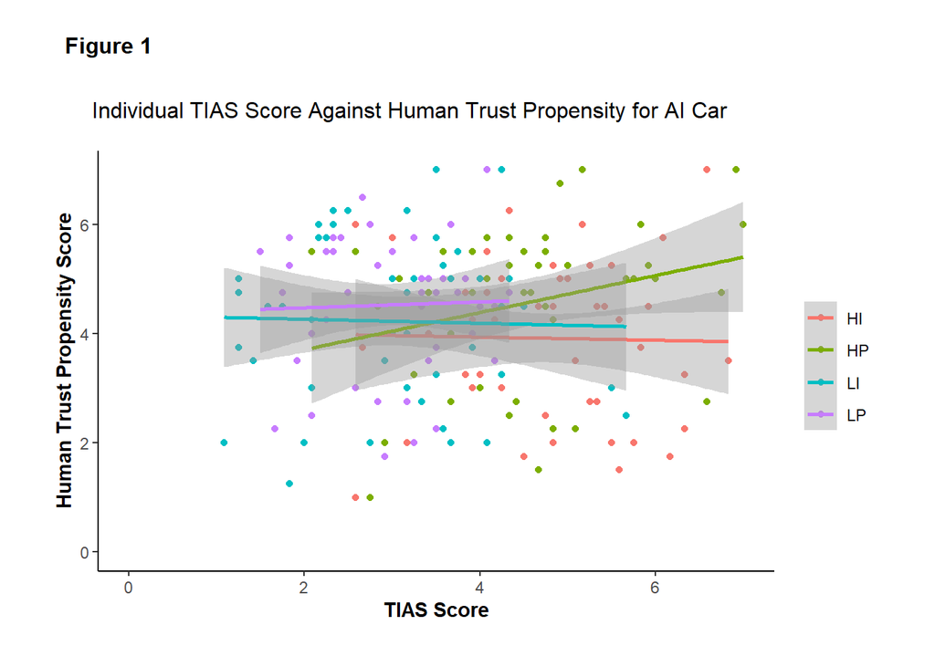

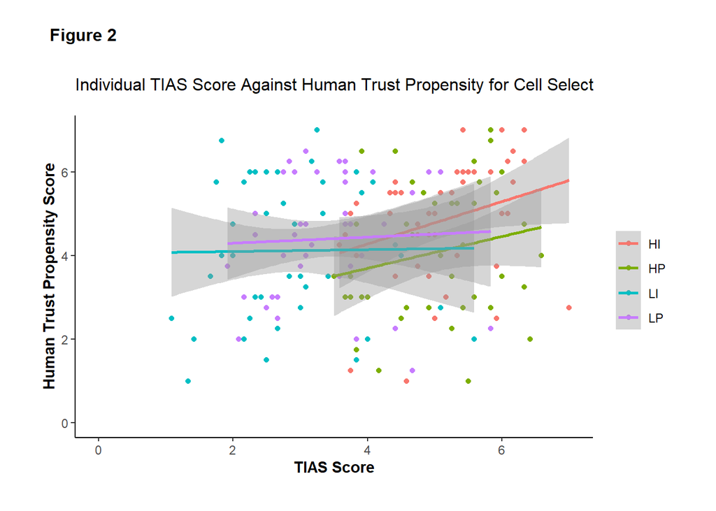

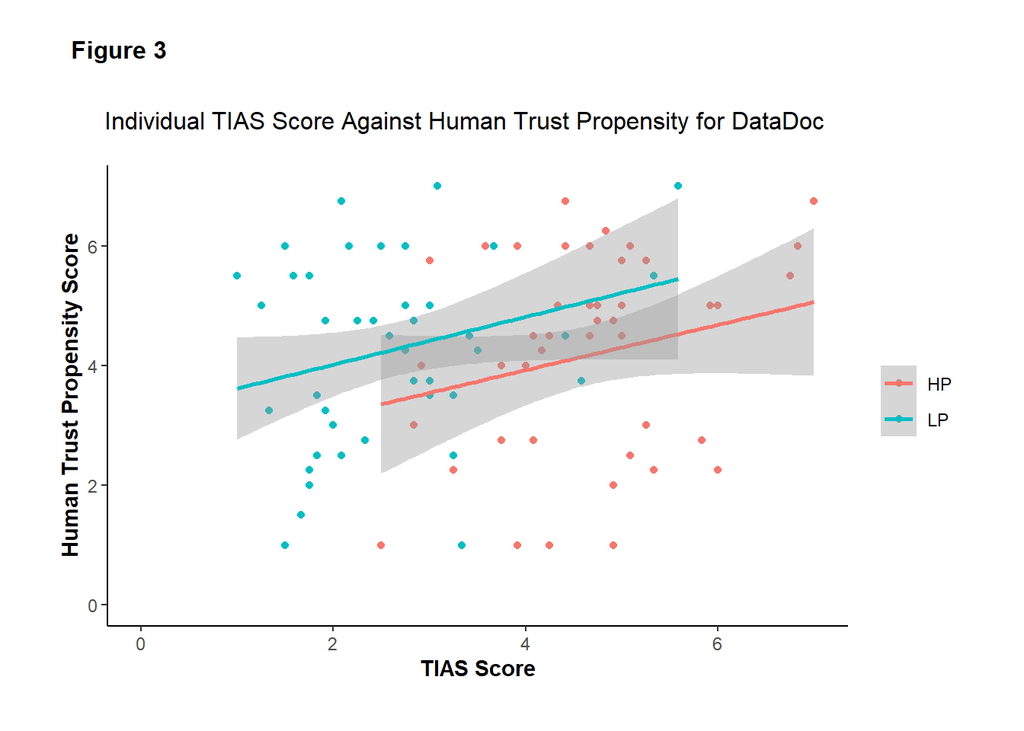

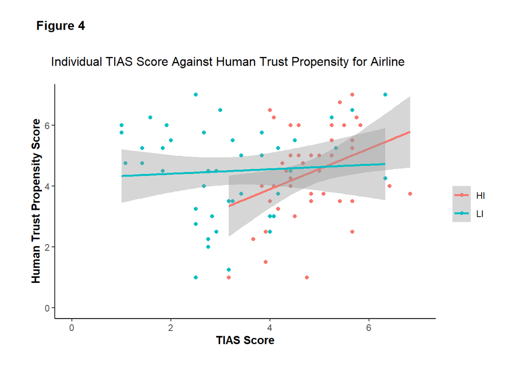

### TIAS/Machine_Trust_Propensity

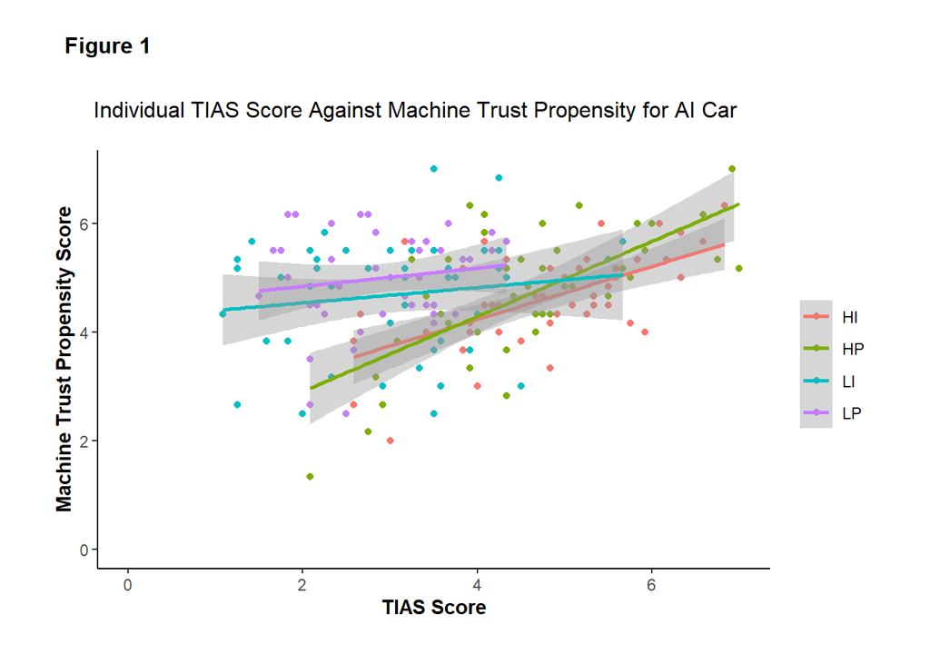

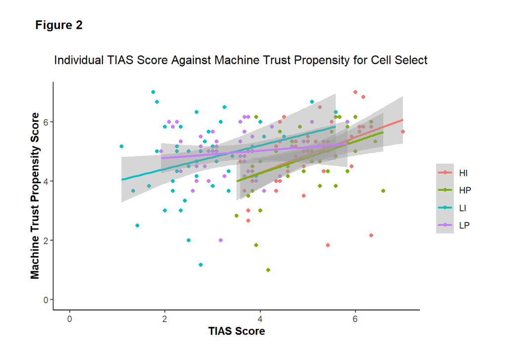

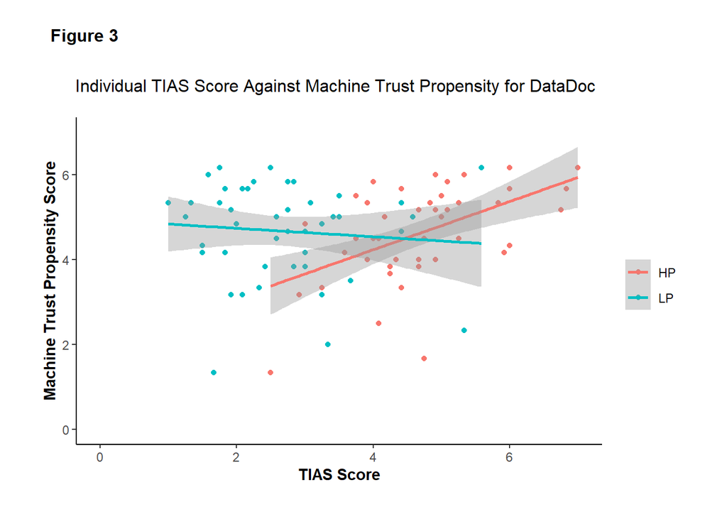

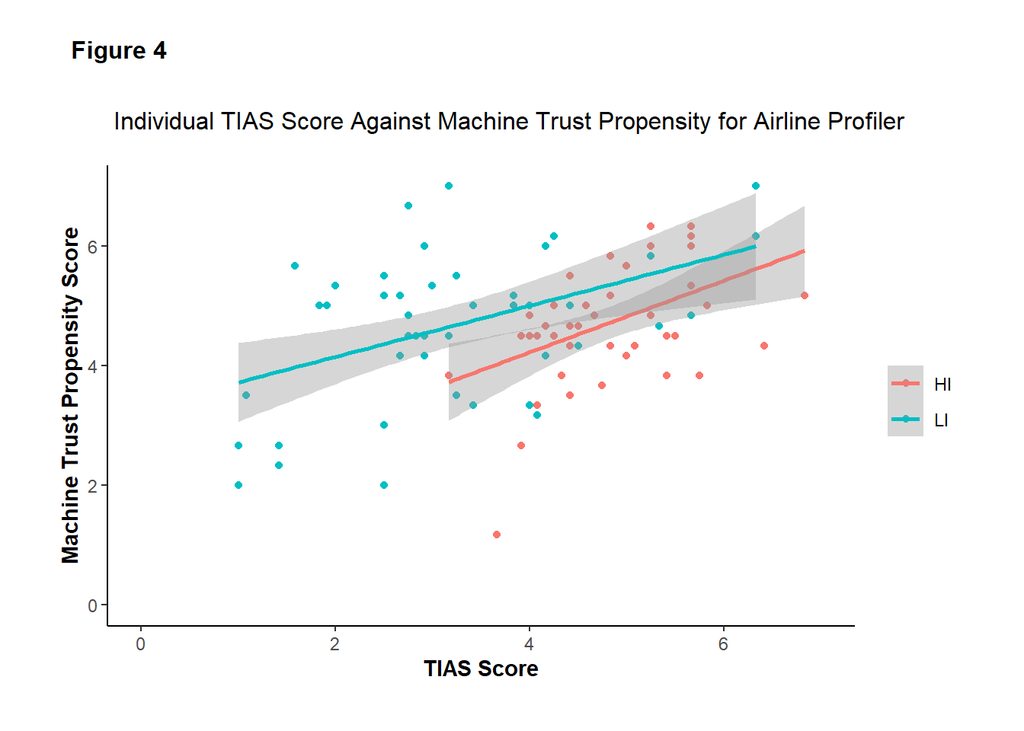

## T-Tests

**Analysis 1**  
**One Tailed T-Tests**

High generalisability across AI applications if each applications TIAS score distributions adaquately respond to the manipulation conditions.  
**Research Question:**Is the TIAS applicable across various AI systems?  
**Research Hypotheses:**Firstly, we hypothesise that the TIAS scores of the high performance/integrity conditions will be significantly higher than the low performance/integrity conditions for each AI application.  
**One-Tailed T-Tests** with bonferroni correction between the TIAS distributions of the high/low conditions for each application

### Study 1 - Performance

**Car HP/LP**

```
##
##  Welch Two Sample t-test
##
## data:  TIAS by Condition
## t = 7.538, df = 74.867, p-value = 4.538e-11
## alternative hypothesis: true difference in means between group HP and group LP is greater than 0
## 95 percent confidence interval:
##  1.243643      Inf
## sample estimates:
## mean in group HP mean in group LP
##         4.549242         2.952899
```

**Cell Select HP/LP**

```
##
##  Welch Two Sample t-test
##
## data:  TIAS by Condition
## t = 9.0862, df = 87.971, p-value = 1.367e-14
## alternative hypothesis: true difference in means between group HP and group LP is greater than 0
## 95 percent confidence interval:
##  1.346613      Inf
## sample estimates:
## mean in group HP mean in group LP
##         5.027778         3.379630
```

**DataDoc HP/LP**

```
##
##  Welch Two Sample t-test
##
## data:  TIAS by Condition
## t = 9.1121, df = 87.984, p-value = 1.208e-14
## alternative hypothesis: true difference in means between group HP and group LP is greater than 0
## 95 percent confidence interval:
##  1.63513     Inf
## sample estimates:
## mean in group HP mean in group LP
##         4.662963         2.662963
```

### Study 2 - Integrity

**Car HI/LI**

```
##
##  Welch Two Sample t-test
##
## data:  TIAS by Condition
## t = 7.6835, df = 89, p-value = 9.644e-12
## alternative hypothesis: true difference in means between group HI and group LI is greater than 0
## 95 percent confidence interval:
##  1.376252      Inf
## sample estimates:
## mean in group HI mean in group LI
##         4.783333         3.027174
```

**Cell Select HI/LI**

```
##
##  Welch Two Sample t-test
##
## data:  TIAS by Condition
## t = 11.667, df = 84.159, p-value < 2.2e-16
## alternative hypothesis: true difference in means between group HI and group LI is greater than 0
## 95 percent confidence interval:
##  1.935613      Inf
## sample estimates:
## mean in group HI mean in group LI
##         5.090741         2.833333
```

**Airline HI/LI**

```
##
##  Welch Two Sample t-test
##
## data:  TIAS by Condition
## t = 7.2275, df = 70.755, p-value = 2.279e-10
## alternative hypothesis: true difference in means between group HI and group LI is greater than 0
## 95 percent confidence interval:
##  1.269509      Inf
## sample estimates:
## mean in group HI mean in group LI
##          4.82963          3.17963
```

## Correlations

**Analysis 2**  
**Correlations**

The convergent validity is assesed through the correlations between the TIAS scores and measures of similar constructs below.  
**Research Question:**Is the TIAS a valid measure of trust in AI?  
**Research Hypotheses:**Secondly, it is hypothesised that there will be a positive association between the TIAS scores and the following measures: the Human Trust propensity scale and the Machine Trust propensity scale.

### Collapsed Overall Correlations

**Study 1**

```
##
##  Pearson's product-moment correlation
##
## data:  Study_1_DF$TIAS and Study_1_DF$Behavioural_Measure
## t = 27.926, df = 268, p-value < 2.2e-16
## alternative hypothesis: true correlation is not equal to 0
## 95 percent confidence interval:
##  0.8286560 0.8903739
## sample estimates:
##       cor
## 0.8626929
```

```
##
##  Pearson's product-moment correlation
##
## data:  Study_1_DF$TIAS and Study_1_DF$Human_Trust_Propensity
## t = 1.7296, df = 268, p-value = 0.08485
## alternative hypothesis: true correlation is not equal to 0
## 95 percent confidence interval:
##  -0.01449002  0.22166328
## sample estimates:
##       cor
## 0.1050676
```

```
##
##  Pearson's product-moment correlation
##
## data:  Study_1_DF$TIAS and Study_1_DF$Machine_Trust_Propensity
## t = 3.2918, df = 268, p-value = 0.001129
## alternative hypothesis: true correlation is not equal to 0
## 95 percent confidence interval:
##  0.07963046 0.30923122
## sample estimates:
##       cor
## 0.1971324
```

**Study 2**

```
##
##  Pearson's product-moment correlation
##
## data:  Study_2_DF$TIAS and Study_2_DF$Behavioural_Measure
## t = 26.42, df = 268, p-value < 2.2e-16
## alternative hypothesis: true correlation is not equal to 0
## 95 percent confidence interval:
##  0.8131829 0.8801088
## sample estimates:
##       cor
## 0.8500415
```

```
##
##  Pearson's product-moment correlation
##
## data:  Study_2_DF$TIAS and Study_2_DF$Human_Trust_Propensity
## t = 1.7353, df = 268, p-value = 0.08383
## alternative hypothesis: true correlation is not equal to 0
## 95 percent confidence interval:
##  -0.01414299  0.22199330
## sample estimates:
##       cor
## 0.1054109
```

```
##
##  Pearson's product-moment correlation
##
## data:  Study_2_DF$TIAS and Study_2_DF$Machine_Trust_Propensity
## t = 5.1788, df = 268, p-value = 4.391e-07
## alternative hypothesis: true correlation is not equal to 0
## 95 percent confidence interval:
##  0.1890457 0.4063596
## sample estimates:
##       cor
## 0.3016149
```

### Between Conditions

#### **Car**

```
##
##  Pearson's product-moment correlation
##
## data:  Car_HP_DF$TIAS and Car_HP_DF$Behavioural_Measure
## t = 9.8292, df = 42, p-value = 1.872e-12
## alternative hypothesis: true correlation is not equal to 0
## 95 percent confidence interval:
##  0.7152641 0.9069515
## sample estimates:
##       cor
## 0.8348631
```

```
##
##  Pearson's product-moment correlation
##
## data:  Car_LP_DF$TIAS and Car_LP_DF$Behavioural_Measure
## t = 8.9467, df = 44, p-value = 1.842e-11
## alternative hypothesis: true correlation is not equal to 0
## 95 percent confidence interval:
##  0.6690077 0.8867973
## sample estimates:
##       cor
## 0.8032963
```

```
##
##  Pearson's product-moment correlation
##
## data:  Car_HI_DF$TIAS and Car_HI_DF$Behavioural_Measure
## t = 7.6775, df = 43, p-value = 1.364e-09
## alternative hypothesis: true correlation is not equal to 0
## 95 percent confidence interval:
##  0.6010032 0.8616135
## sample estimates:
##       cor
## 0.7603926
```

```
##
##  Pearson's product-moment correlation
##
## data:  Car_LI_DF$TIAS and Car_LI_DF$Behavioural_Measure
## t = 8.8167, df = 44, p-value = 2.798e-11
## alternative hypothesis: true correlation is not equal to 0
## 95 percent confidence interval:
##  0.6624796 0.8842668
## sample estimates:
##       cor
## 0.7990979
```

```
##
##  Pearson's product-moment correlation
##
## data:  Car_HP_DF$TIAS and Car_HP_DF$Human_Trust_Propensity
## t = 1.8349, df = 42, p-value = 0.07361
## alternative hypothesis: true correlation is not equal to 0
## 95 percent confidence interval:
##  -0.02660786  0.52670619
## sample estimates:
##       cor
## 0.2724245
```

```
##
##  Pearson's product-moment correlation
##
## data:  Car_LP_DF$TIAS and Car_LP_DF$Human_Trust_Propensity
## t = 0.22467, df = 44, p-value = 0.8233
## alternative hypothesis: true correlation is not equal to 0
## 95 percent confidence interval:
##  -0.2589928  0.3209940
## sample estimates:
##        cor
## 0.03385029
```

```
##
##  Pearson's product-moment correlation
##
## data:  Car_HI_DF$TIAS and Car_HI_DF$Human_Trust_Propensity
## t = -0.13948, df = 43, p-value = 0.8897
## alternative hypothesis: true correlation is not equal to 0
## 95 percent confidence interval:
##  -0.3128462  0.2739791
## sample estimates:
##         cor
## -0.02126504
```

```
##
##  Pearson's product-moment correlation
##
## data:  Car_LI_DF$TIAS and Car_LI_DF$Human_Trust_Propensity
## t = -0.17926, df = 44, p-value = 0.8586
## alternative hypothesis: true correlation is not equal to 0
## 95 percent confidence interval:
##  -0.3148435  0.2653645
## sample estimates:
##         cor
## -0.02701459
```

```
##
##  Pearson's product-moment correlation
##
## data:  Car_HP_DF$TIAS and Car_HP_DF$Machine_Trust_Propensity
## t = 5.8005, df = 42, p-value = 7.687e-07
## alternative hypothesis: true correlation is not equal to 0
## 95 percent confidence interval:
##  0.461396 0.804512
## sample estimates:
##       cor
## 0.6669218
```

```
##
##  Pearson's product-moment correlation
##
## data:  Car_LP_DF$TIAS and Car_LP_DF$Machine_Trust_Propensity
## t = 1.0167, df = 44, p-value = 0.3149
## alternative hypothesis: true correlation is not equal to 0
## 95 percent confidence interval:
##  -0.1451822  0.4231871
## sample estimates:
##      cor
## 0.151501
```

```
##
##  Pearson's product-moment correlation
##
## data:  Car_HI_DF$TIAS and Car_HI_DF$Machine_Trust_Propensity
## t = 4.8237, df = 43, p-value = 1.799e-05
## alternative hypothesis: true correlation is not equal to 0
## 95 percent confidence interval:
##  0.3619810 0.7548016
## sample estimates:
##       cor
## 0.5925538
```

```
##
##  Pearson's product-moment correlation
##
## data:  Car_LI_DF$TIAS and Car_LI_DF$Machine_Trust_Propensity
## t = 0.96634, df = 44, p-value = 0.3392
## alternative hypothesis: true correlation is not equal to 0
## 95 percent confidence interval:
##  -0.1525215  0.4170061
## sample estimates:
##       cor
## 0.1441594
```

#### **Cell Select**

```
##
##  Pearson's product-moment correlation
##
## data:  CellSelect_HP_DF$TIAS and CellSelect_HP_DF$Behavioural_Measure
## t = 6.201, df = 43, p-value = 1.864e-07
## alternative hypothesis: true correlation is not equal to 0
## 95 percent confidence interval:
##  0.4929768 0.8160386
## sample estimates:
##       cor
## 0.6870857
```

```
##
##  Pearson's product-moment correlation
##
## data:  CellSelect_LP_DF$TIAS and CellSelect_LP_DF$Behavioural_Measure
## t = 7.7994, df = 43, p-value = 9.137e-10
## alternative hypothesis: true correlation is not equal to 0
## 95 percent confidence interval:
##  0.6086258 0.8646781
## sample estimates:
##       cor
## 0.7654163
```

```
##
##  Pearson's product-moment correlation
##
## data:  CellSelect_HI_DF$TIAS and CellSelect_HI_DF$Behavioural_Measure
## t = 8.1354, df = 43, p-value = 3.051e-10
## alternative hypothesis: true correlation is not equal to 0
## 95 percent confidence interval:
##  0.6287222 0.8726674
## sample estimates:
##     cor
## 0.77857
```

```
##
##  Pearson's product-moment correlation
##
## data:  CellSelect_LI_DF$TIAS and CellSelect_LI_DF$Behavioural_Measure
## t = 6.2955, df = 42, p-value = 1.492e-07
## alternative hypothesis: true correlation is not equal to 0
## 95 percent confidence interval:
##  0.5042014 0.8233447
## sample estimates:
##       cor
## 0.6967822
```

```
##
##  Pearson's product-moment correlation
##
## data:  CellSelect_HP_DF$TIAS and CellSelect_HP_DF$Human_Trust_Propensity
## t = 1.4167, df = 43, p-value = 0.1638
## alternative hypothesis: true correlation is not equal to 0
## 95 percent confidence interval:
##  -0.08779984  0.47525087
## sample estimates:
##       cor
## 0.2111766
```

```
##
##  Pearson's product-moment correlation
##
## data:  CellSelect_LP_DF$TIAS and CellSelect_LP_DF$Human_Trust_Propensity
## t = 0.28862, df = 43, p-value = 0.7743
## alternative hypothesis: true correlation is not equal to 0
## 95 percent confidence interval:
##  -0.2528255  0.3332049
## sample estimates:
##       cor
## 0.0439717
```

```
##
##  Pearson's product-moment correlation
##
## data:  CellSelect_HI_DF$TIAS and CellSelect_HI_DF$Human_Trust_Propensity
## t = 2.0705, df = 43, p-value = 0.04444
## alternative hypothesis: true correlation is not equal to 0
## 95 percent confidence interval:
##  0.008300406 0.546346706
## sample estimates:
##       cor
## 0.3011007
```

```
##
##  Pearson's product-moment correlation
##
## data:  CellSelect_LI_DF$TIAS and CellSelect_LI_DF$Human_Trust_Propensity
## t = 0.084242, df = 42, p-value = 0.9333
## alternative hypothesis: true correlation is not equal to 0
## 95 percent confidence interval:
##  -0.2849824  0.3086869
## sample estimates:
##        cor
## 0.01299769
```

```
##
##  Pearson's product-moment correlation
##
## data:  CellSelect_HP_DF$TIAS and CellSelect_HP_DF$Machine_Trust_Propensity
## t = 2.9358, df = 43, p-value = 0.005323
## alternative hypothesis: true correlation is not equal to 0
## 95 percent confidence interval:
##  0.1307784 0.6269590
## sample estimates:
##      cor
## 0.408626
```

```
##
##  Pearson's product-moment correlation
##
## data:  CellSelect_LP_DF$TIAS and CellSelect_LP_DF$Machine_Trust_Propensity
## t = 0.82374, df = 43, p-value = 0.4146
## alternative hypothesis: true correlation is not equal to 0
## 95 percent confidence interval:
##  -0.1753078  0.4034145
## sample estimates:
##       cor
## 0.1246399
```

```
##
##  Pearson's product-moment correlation
##
## data:  CellSelect_HI_DF$TIAS and CellSelect_HI_DF$Machine_Trust_Propensity
## t = 3.114, df = 43, p-value = 0.003279
## alternative hypothesis: true correlation is not equal to 0
## 95 percent confidence interval:
##  0.1549453 0.6417018
## sample estimates:
##      cor
## 0.428969
```

```
##
##  Pearson's product-moment correlation
##
## data:  CellSelect_LI_DF$TIAS and CellSelect_LI_DF$Machine_Trust_Propensity
## t = 2.0888, df = 42, p-value = 0.04282
## alternative hypothesis: true correlation is not equal to 0
## 95 percent confidence interval:
##  0.01088261 0.55326396
## sample estimates:
##       cor
## 0.3067719
```

#### **DataDoc and Airline**

```
##
##  Pearson's product-moment correlation
##
## data:  DataDoc_HP_DF$TIAS and DataDoc_HP_DF$Behavioural_Measure
## t = 8.6057, df = 43, p-value = 6.693e-11
## alternative hypothesis: true correlation is not equal to 0
## 95 percent confidence interval:
##  0.6547287 0.8828159
## sample estimates:
##       cor
## 0.7953988
```

```
##
##  Pearson's product-moment correlation
##
## data:  DataDoc_LP_DF$TIAS and DataDoc_LP_DF$Behavioural_Measure
## t = 12.474, df = 43, p-value = 7.012e-16
## alternative hypothesis: true correlation is not equal to 0
## 95 percent confidence interval:
##  0.7992877 0.9355957
## sample estimates:
##       cor
## 0.8851496
```

```
##
##  Pearson's product-moment correlation
##
## data:  Airline_HI_DF$TIAS and Airline_HI_DF$Behavioural_Measure
## t = 6.1965, df = 43, p-value = 1.893e-07
## alternative hypothesis: true correlation is not equal to 0
## 95 percent confidence interval:
##  0.4925935 0.8158694
## sample estimates:
##       cor
## 0.6868184
```

```
##
##  Pearson's product-moment correlation
##
## data:  Airline_LI_DF$TIAS and Airline_LI_DF$Behavioural_Measure
## t = 10.583, df = 43, p-value = 1.503e-13
## alternative hypothesis: true correlation is not equal to 0
## 95 percent confidence interval:
##  0.7415450 0.9152195
## sample estimates:
##       cor
## 0.8500498
```

```
##
##  Pearson's product-moment correlation
##
## data:  DataDoc_HP_DF$TIAS and DataDoc_HP_DF$Human_Trust_Propensity
## t = 1.5781, df = 43, p-value = 0.1219
## alternative hypothesis: true correlation is not equal to 0
## 95 percent confidence interval:
##  -0.06394852  0.49361002
## sample estimates:
##       cor
## 0.2339774
```

```
##
##  Pearson's product-moment correlation
##
## data:  DataDoc_LP_DF$TIAS and DataDoc_LP_DF$Human_Trust_Propensity
## t = 1.8541, df = 43, p-value = 0.07059
## alternative hypothesis: true correlation is not equal to 0
## 95 percent confidence interval:
##  -0.02331309  0.52378435
## sample estimates:
##       cor
## 0.2720827
```

```
##
##  Pearson's product-moment correlation
##
## data:  Airline_HI_DF$TIAS and Airline_HI_DF$Human_Trust_Propensity
## t = 2.443, df = 43, p-value = 0.01875
## alternative hypothesis: true correlation is not equal to 0
## 95 percent confidence interval:
##  0.0619255 0.5829125
## sample estimates:
##       cor
## 0.3491135
```

```
##
##  Pearson's product-moment correlation
##
## data:  Airline_LI_DF$TIAS and Airline_LI_DF$Human_Trust_Propensity
## t = 0.43038, df = 43, p-value = 0.6691
## alternative hypothesis: true correlation is not equal to 0
## 95 percent confidence interval:
##  -0.2325117  0.3522542
## sample estimates:
##        cor
## 0.06549203
```

```
##
##  Pearson's product-moment correlation
##
## data:  DataDoc_HP_DF$TIAS and DataDoc_HP_DF$Machine_Trust_Propensity
## t = 4.0891, df = 43, p-value = 0.0001862
## alternative hypothesis: true correlation is not equal to 0
## 95 percent confidence interval:
##  0.2789234 0.7120709
## sample estimates:
##       cor
## 0.5291352
```

```
##
##  Pearson's product-moment correlation
##
## data:  DataDoc_LP_DF$TIAS and DataDoc_LP_DF$Machine_Trust_Propensity
## t = -0.60484, df = 43, p-value = 0.5485
## alternative hypothesis: true correlation is not equal to 0
## 95 percent confidence interval:
##  -0.3752647  0.2072741
## sample estimates:
##         cor
## -0.09184807
```

```
##
##  Pearson's product-moment correlation
##
## data:  Airline_HI_DF$TIAS and Airline_HI_DF$Machine_Trust_Propensity
## t = 3.4219, df = 43, p-value = 0.001375
## alternative hypothesis: true correlation is not equal to 0
## 95 percent confidence interval:
##  0.1956689 0.6657568
## sample estimates:
##       cor
## 0.4626314
```

```
##
##  Pearson's product-moment correlation
##
## data:  Airline_LI_DF$TIAS and Airline_LI_DF$Machine_Trust_Propensity
## t = 3.3117, df = 43, p-value = 0.001886
## alternative hypothesis: true correlation is not equal to 0
## 95 percent confidence interval:
##  0.1812464 0.6573479
## sample estimates:
##      cor
## 0.450797
```

### Study 1 - Performance

First table of results represents the r values  
Second table of results represents the p values

**Car**

```
##                          TIAS Human_Trust_Propensity Machine_Trust_Propensity
## TIAS                     1.00                   0.15                     0.28
## Human_Trust_Propensity   0.15                   1.00                     0.36
## Machine_Trust_Propensity 0.28                   0.36                     1.00
## Behavioural_Measure      0.83                   0.28                     0.37
##                          Behavioural_Measure
## TIAS                                    0.83
## Human_Trust_Propensity                  0.28
## Machine_Trust_Propensity                0.37
## Behavioural_Measure                     1.00
##
## n= 90
##
##
## P
##                          TIAS   Human_Trust_Propensity Machine_Trust_Propensity
## TIAS                            0.1542                 0.0077
## Human_Trust_Propensity   0.1542                        0.0005
## Machine_Trust_Propensity 0.0077 0.0005
## Behavioural_Measure      0.0000 0.0076                 0.0003
##                          Behavioural_Measure
## TIAS                     0.0000
## Human_Trust_Propensity   0.0076
## Machine_Trust_Propensity 0.0003
## Behavioural_Measure
```

**Cell Select**

```
##                          TIAS Human_Trust_Propensity Machine_Trust_Propensity
## TIAS                     1.00                   0.02                     0.16
## Human_Trust_Propensity   0.02                   1.00                     0.35
## Machine_Trust_Propensity 0.16                   0.35                     1.00
## Behavioural_Measure      0.84                  -0.02                     0.03
##                          Behavioural_Measure
## TIAS                                    0.84
## Human_Trust_Propensity                 -0.02
## Machine_Trust_Propensity                0.03
## Behavioural_Measure                     1.00
##
## n= 90
##
##
## P
##                          TIAS   Human_Trust_Propensity Machine_Trust_Propensity
## TIAS                            0.8399                 0.1350
## Human_Trust_Propensity   0.8399                        0.0006
## Machine_Trust_Propensity 0.1350 0.0006
## Behavioural_Measure      0.0000 0.8522                 0.7895
##                          Behavioural_Measure
## TIAS                     0.0000
## Human_Trust_Propensity   0.8522
## Machine_Trust_Propensity 0.7895
## Behavioural_Measure
```

**DataDoc**

```
##                          TIAS Human_Trust_Propensity Machine_Trust_Propensity
## TIAS                     1.00                   0.16                     0.13
## Human_Trust_Propensity   0.16                   1.00                     0.29
## Machine_Trust_Propensity 0.13                   0.29                     1.00
## Behavioural_Measure      0.91                   0.11                     0.07
##                          Behavioural_Measure
## TIAS                                    0.91
## Human_Trust_Propensity                  0.11
## Machine_Trust_Propensity                0.07
## Behavioural_Measure                     1.00
##
## n= 90
##
##
## P
##                          TIAS   Human_Trust_Propensity Machine_Trust_Propensity
## TIAS                            0.1380                 0.2103
## Human_Trust_Propensity   0.1380                        0.0058
## Machine_Trust_Propensity 0.2103 0.0058
## Behavioural_Measure      0.0000 0.2827                 0.5387
##                          Behavioural_Measure
## TIAS                     0.0000
## Human_Trust_Propensity   0.2827
## Machine_Trust_Propensity 0.5387
## Behavioural_Measure
```

### Study 2 - Integrity

First table of results represents the r values  
Second table of results represents the p values

**Car**

```
##                           TIAS Human_Trust_Propensity Machine_Trust_Propensity
## TIAS                      1.00                  -0.09                     0.24
## Human_Trust_Propensity   -0.09                   1.00                     0.30
## Machine_Trust_Propensity  0.24                   0.30                     1.00
## Behavioural_Measure       0.82                  -0.03                     0.18
##                          Behavioural_Measure
## TIAS                                    0.82
## Human_Trust_Propensity                 -0.03
## Machine_Trust_Propensity                0.18
## Behavioural_Measure                     1.00
##
## n= 91
##
##
## P
##                          TIAS   Human_Trust_Propensity Machine_Trust_Propensity
## TIAS                            0.4196                 0.0204
## Human_Trust_Propensity   0.4196                        0.0037
## Machine_Trust_Propensity 0.0204 0.0037
## Behavioural_Measure      0.0000 0.7788                 0.0834
##                          Behavioural_Measure
## TIAS                     0.0000
## Human_Trust_Propensity   0.7788
## Machine_Trust_Propensity 0.0834
## Behavioural_Measure
```

**Cell Select**

```
##                          TIAS Human_Trust_Propensity Machine_Trust_Propensity
## TIAS                     1.00                   0.26                     0.29
## Human_Trust_Propensity   0.26                   1.00                     0.15
## Machine_Trust_Propensity 0.29                   0.15                     1.00
## Behavioural_Measure      0.86                   0.25                     0.26
##                          Behavioural_Measure
## TIAS                                    0.86
## Human_Trust_Propensity                  0.25
## Machine_Trust_Propensity                0.26
## Behavioural_Measure                     1.00
##
## n= 89
##
##
## P
##                          TIAS   Human_Trust_Propensity Machine_Trust_Propensity
## TIAS                            0.0138                 0.0064
## Human_Trust_Propensity   0.0138                        0.1524
## Machine_Trust_Propensity 0.0064 0.1524
## Behavioural_Measure      0.0000 0.0177                 0.0150
##                          Behavioural_Measure
## TIAS                     0.0000
## Human_Trust_Propensity   0.0177
## Machine_Trust_Propensity 0.0150
## Behavioural_Measure
```

**Airline**

```
##                          TIAS Human_Trust_Propensity Machine_Trust_Propensity
## TIAS                     1.00                   0.12                     0.37
## Human_Trust_Propensity   0.12                   1.00                     0.27
## Machine_Trust_Propensity 0.37                   0.27                     1.00
## Behavioural_Measure      0.88                   0.06                     0.29
##                          Behavioural_Measure
## TIAS                                    0.88
## Human_Trust_Propensity                  0.06
## Machine_Trust_Propensity                0.29
## Behavioural_Measure                     1.00
##
## n= 90
##
##
## P
##                          TIAS   Human_Trust_Propensity Machine_Trust_Propensity
## TIAS                            0.2592                 0.0003
## Human_Trust_Propensity   0.2592                        0.0108
## Machine_Trust_Propensity 0.0003 0.0108
## Behavioural_Measure      0.0000 0.5872                 0.0052
##                          Behavioural_Measure
## TIAS                     0.0000
## Human_Trust_Propensity   0.5872
## Machine_Trust_Propensity 0.0052
## Behavioural_Measure
```

## Regression

**Analysis 3**  
**Hierarchical Regression**

The predictve and divergent validity is assesed through the proportion of variance in the behavioural intent measure that is explained by the TIAS scores.  
**Research Question:**Is the TIAS a valid measure of trust in AI?  
**Research Hypotheses:**Thirdly, it is hypothesised that the TIAS scores will be an independent positive predictor of intention to use the system.  
**Hierarchical Regression**  
For each AI Application and Condition:  
Dependent variable: Behavioural Intent measure from Condition X - Application X  
Independent variables: Condition X - Application X TIAS Score , Human Trust Propensity, Machine Trust Propensity, Age, Gender, Level of education

### Study 1 - Performance

#### Collapsed Regression

##### Regression Models

```
##
## Call:
## lm(formula = Behavioural_Measure ~ Gender, data = Study_1_Regression_DF)
##
## Residuals:
##     Min      1Q  Median      3Q     Max
## -2.8211 -1.6068  0.1789  1.3932  3.3932
##
## Coefficients:
##             Estimate Std. Error t value Pr(>|t|)
## (Intercept)   3.6068     0.1635  22.054   <2e-16 ***
## GenderMale    0.2143     0.2279   0.941    0.348
## ---
## Signif. codes:  0 '***' 0.001 '**' 0.01 '*' 0.05 '.' 0.1 ' ' 1
##
## Residual standard error: 1.85 on 262 degrees of freedom
## Multiple R-squared:  0.003365,   Adjusted R-squared:  -0.000439
## F-statistic: 0.8846 on 1 and 262 DF,  p-value: 0.3478
```

```
##                    b       beta
## GenderMale 0.2143076 0.05800834
```

```
##
## Call:
## lm(formula = Behavioural_Measure ~ Gender + Education, data = Study_1_Regression_DF)
##
## Residuals:
##     Min      1Q  Median      3Q     Max
## -2.8846 -1.6404  0.2155  1.4096  3.5014
##
## Coefficients:
##             Estimate Std. Error t value Pr(>|t|)
## (Intercept)  3.46529    0.41092   8.433 2.32e-15 ***
## GenderMale   0.21920    0.22860   0.959    0.339
## Education    0.03335    0.08883   0.375    0.708
## ---
## Signif. codes:  0 '***' 0.001 '**' 0.01 '*' 0.05 '.' 0.1 ' ' 1
##
## Residual standard error: 1.853 on 261 degrees of freedom
## Multiple R-squared:  0.003903,   Adjusted R-squared:  -0.00373
## F-statistic: 0.5113 on 2 and 261 DF,  p-value: 0.6003
```

```
##                     b       beta
## GenderMale 0.21919686 0.05933175
## Education  0.03335118 0.02323093
```

```
##
## Call:
## lm(formula = Behavioural_Measure ~ Gender + Education + Age,
##     data = Study_1_Regression_DF)
##
## Residuals:
##     Min      1Q  Median      3Q     Max
## -2.8918 -1.6542  0.2325  1.4178  3.5111
##
## Coefficients:
##             Estimate Std. Error t value Pr(>|t|)
## (Intercept) 3.376680   0.469748   7.188 6.95e-12 ***
## GenderMale  0.225065   0.229466   0.981    0.328
## Education   0.024213   0.091991   0.263    0.793
## Age         0.003521   0.008996   0.391    0.696
## ---
## Signif. codes:  0 '***' 0.001 '**' 0.01 '*' 0.05 '.' 0.1 ' ' 1
##
## Residual standard error: 1.856 on 260 degrees of freedom
## Multiple R-squared:  0.004489,   Adjusted R-squared:  -0.006997
## F-statistic: 0.3908 on 3 and 260 DF,  p-value: 0.7597
```

```
##                      b       beta
## GenderMale 0.225065053 0.06092014
## Education  0.024213376 0.01686595
## Age        0.003520573 0.02511266
```

```
##
## Call:
## lm(formula = Behavioural_Measure ~ Gender + Education + Age +
##     Machine_Trust_Propensity, data = Study_1_Regression_DF)
##
## Residuals:
##    Min     1Q Median     3Q    Max
## -3.242 -1.763  0.357  1.466  3.539
##
## Coefficients:
##                           Estimate Std. Error t value Pr(>|t|)
## (Intercept)               2.212550   0.648909   3.410 0.000754 ***
## GenderMale                0.137384   0.229579   0.598 0.550083
## Education                -0.008175   0.091883  -0.089 0.929174
## Age                       0.003004   0.008902   0.337 0.736082
## Machine_Trust_Propensity  0.283618   0.110330   2.571 0.010711 *
## ---
## Signif. codes:  0 '***' 0.001 '**' 0.01 '*' 0.05 '.' 0.1 ' ' 1
##
## Residual standard error: 1.837 on 259 degrees of freedom
## Multiple R-squared:  0.02926,    Adjusted R-squared:  0.01426
## F-statistic: 1.951 on 4 and 259 DF,  p-value: 0.1024
```

```
##                                     b         beta
## GenderMale                0.137384214  0.037186875
## Education                -0.008174927 -0.005694286
## Age                       0.003003757  0.021426146
## Machine_Trust_Propensity  0.283617751  0.160691315
```

```
##
## Call:
## lm(formula = Behavioural_Measure ~ Gender + Education + Age +
##     Machine_Trust_Propensity + Human_Trust_Propensity, data = Study_1_Regression_DF)
##
## Residuals:
##     Min      1Q  Median      3Q     Max
## -3.3143 -1.7046  0.3714  1.4784  3.4395
##
## Coefficients:
##                           Estimate Std. Error t value Pr(>|t|)
## (Intercept)               2.095343   0.658697   3.181  0.00165 **
## GenderMale                0.128006   0.229730   0.557  0.57787
## Education                -0.011816   0.091939  -0.129  0.89784
## Age                       0.002005   0.008954   0.224  0.82302
## Machine_Trust_Propensity  0.243664   0.116914   2.084  0.03813 *
## Human_Trust_Propensity    0.084292   0.081693   1.032  0.30312
## ---
## Signif. codes:  0 '***' 0.001 '**' 0.01 '*' 0.05 '.' 0.1 ' ' 1
##
## Residual standard error: 1.836 on 258 degrees of freedom
## Multiple R-squared:  0.03325,    Adjusted R-squared:  0.01451
## F-statistic: 1.775 on 5 and 258 DF,  p-value: 0.1184
```

```
##                                    b        beta
## GenderMale                0.12800638  0.03464850
## Education                -0.01181617 -0.00823061
## Age                       0.00200465  0.01429940
## Machine_Trust_Propensity  0.24366394  0.13805440
## Human_Trust_Propensity    0.08429211  0.06795761
```

```
##
## Call:
## lm(formula = Behavioural_Measure ~ Gender + Education + Age +
##     Machine_Trust_Propensity + Human_Trust_Propensity + TIAS,
##     data = Study_1_Regression_DF)
##
## Residuals:
##     Min      1Q  Median      3Q     Max
## -3.3420 -0.5706  0.0124  0.6576  2.6640
##
## Coefficients:
##                           Estimate Std. Error t value Pr(>|t|)
## (Intercept)              -0.809550   0.351373  -2.304    0.022 *
## GenderMale                0.070864   0.116783   0.607    0.545
## Education                 0.010971   0.046737   0.235    0.815
## Age                      -0.004175   0.004557  -0.916    0.360
## Machine_Trust_Propensity -0.073857   0.060556  -1.220    0.224
## Human_Trust_Propensity    0.055179   0.041535   1.328    0.185
## TIAS                      1.216923   0.044683  27.234   <2e-16 ***
## ---
## Signif. codes:  0 '***' 0.001 '**' 0.01 '*' 0.05 '.' 0.1 ' ' 1
##
## Residual standard error: 0.9334 on 257 degrees of freedom
## Multiple R-squared:  0.7512, Adjusted R-squared:  0.7454
## F-statistic: 129.3 on 6 and 257 DF,  p-value: < 2.2e-16
```

```
##                                     b        beta
## GenderMale                0.070864221  0.01918138
## Education                 0.010970693  0.00764169
## Age                      -0.004175199 -0.02978218
## Machine_Trust_Propensity -0.073856559 -0.04184543
## Human_Trust_Propensity    0.055178933  0.04448612
## TIAS                      1.216923214  0.86994292
```

##### Regression Comparison

Collapsed Regression Model Comparison

|  | Behavioural_Measure | Behavioural_Measure | Behavioural_Measure | Behavioural_Measure | Behavioural_Measure | Behavioural_Measure | Behavioural_Measure |
| --- | --- | --- | --- | --- | --- | --- | --- |
| Predictors | p | p | p | p | p | p | p |
| (Intercept) | **<0.001** | **<0.001** | **<0.001** | **<0.001** | **0.001** | **0.002** | **0.022** |
| Gender [Male] |  | 0.348 | 0.339 | 0.328 | 0.550 | 0.578 | 0.545 |
| Education |  |  | 0.708 | 0.793 | 0.929 | 0.898 | 0.815 |
| Age |  |  |  | 0.696 | 0.736 | 0.823 | 0.360 |
| Machine Trust Propensity |  |  |  |  | **0.011** | **0.038** | 0.224 |
| Human Trust Propensity |  |  |  |  |  | 0.303 | 0.185 |
| TIAS |  |  |  |  |  |  | **<0.001** |
| Observations | 264 | 264 | 264 | 264 | 264 | 264 | 264 |
| R<sup>2</sup> / R<sup>2</sup> adjusted | 0.000 / 0.000 | 0.003 / -0.000 | 0.004 / -0.004 | 0.004 / -0.007 | 0.029 / 0.014 | 0.033 / 0.015 | 0.751 / 0.745 |
| AIC | 1076.979 | 1078.089 | 1079.947 | 1081.791 | 1077.140 | 1078.053 | 721.703 |

ANOVA between models *Significance interpreted as improvement in model due to addition of variable*

| Res.Df | RSS | Df | Sum.of.Sq | F | Pr..F. |
| --- | --- | --- | --- | --- | --- |
| 263 | 899.99 | NA | NA | NA | NA |
| 262 | 896.96 | 1 | 3.03 | 3.48 | 0.06 |
| 261 | 896.48 | 1 | 0.48 | 0.56 | 0.46 |
| 260 | 895.95 | 1 | 0.53 | 0.61 | 0.44 |
| 259 | 873.66 | 1 | 22.29 | 25.59 | 0.00 |
| 258 | 870.07 | 1 | 3.59 | 4.12 | 0.04 |
| 257 | 223.90 | 1 | 646.17 | 741.71 | 0.00 |

#### Car

##### Regression Models

```
##
## Call:
## lm(formula = Behavioural_Measure ~ Gender, data = Study_1_Car_Regression_DF)
##
## Residuals:
##     Min      1Q  Median      3Q     Max
## -2.7163 -1.3821  0.2837  1.2846  3.6179
##
## Coefficients:
##             Estimate Std. Error t value Pr(>|t|)
## (Intercept)   3.3821     0.2819  11.999   <2e-16 ***
## GenderMale    0.3342     0.3857   0.867    0.389
## ---
## Signif. codes:  0 '***' 0.001 '**' 0.01 '*' 0.05 '.' 0.1 ' ' 1
##
## Residual standard error: 1.805 on 86 degrees of freedom
## Multiple R-squared:  0.008655,   Adjusted R-squared:  -0.002872
## F-statistic: 0.7509 on 1 and 86 DF,  p-value: 0.3886
```

```
##                    b       beta
## GenderMale 0.3341982 0.09303449
```

```
##
## Call:
## lm(formula = Behavioural_Measure ~ Gender + Education, data = Study_1_Car_Regression_DF)
##
## Residuals:
##     Min      1Q  Median      3Q     Max
## -2.7210 -1.3835  0.2814  1.2865  3.6193
##
## Coefficients:
##              Estimate Std. Error t value Pr(>|t|)
## (Intercept)  3.391747   0.723048   4.691 1.03e-05 ***
## GenderMale   0.333626   0.389947   0.856    0.395
## Education   -0.002206   0.152352  -0.014    0.988
## ---
## Signif. codes:  0 '***' 0.001 '**' 0.01 '*' 0.05 '.' 0.1 ' ' 1
##
## Residual standard error: 1.815 on 85 degrees of freedom
## Multiple R-squared:  0.008658,   Adjusted R-squared:  -0.01467
## F-statistic: 0.3712 on 2 and 85 DF,  p-value: 0.691
```

```
##                       b         beta
## GenderMale  0.333625735  0.092875118
## Education  -0.002206416 -0.001572117
```

```
##
## Call:
## lm(formula = Behavioural_Measure ~ Gender + Education + Age,
##     data = Study_1_Car_Regression_DF)
##
## Residuals:
##     Min      1Q  Median      3Q     Max
## -2.8002 -1.4528  0.1994  1.3557  3.6597
##
## Coefficients:
##              Estimate Std. Error t value Pr(>|t|)
## (Intercept)  3.177701   0.889202   3.574 0.000586 ***
## GenderMale   0.370707   0.401791   0.923 0.358839
## Education   -0.010830   0.154484  -0.070 0.944278
## Age          0.006374   0.015264   0.418 0.677325
## ---
## Signif. codes:  0 '***' 0.001 '**' 0.01 '*' 0.05 '.' 0.1 ' ' 1
##
## Residual standard error: 1.824 on 84 degrees of freedom
## Multiple R-squared:  0.01071,    Adjusted R-squared:  -0.02462
## F-statistic: 0.3032 on 3 and 84 DF,  p-value: 0.823
```

```
##                      b         beta
## GenderMale  0.37070709  0.103197868
## Education  -0.01082987 -0.007716503
## Age         0.00637398  0.047018487
```

```
##
## Call:
## lm(formula = Behavioural_Measure ~ Gender + Education + Age +
##     Machine_Trust_Propensity, data = Study_1_Car_Regression_DF)
##
## Residuals:
##     Min      1Q  Median      3Q     Max
## -3.3093 -1.4768  0.1147  1.2360  3.4451
##
## Coefficients:
##                           Estimate Std. Error t value Pr(>|t|)
## (Intercept)               0.675440   1.098833   0.615 0.540442
## GenderMale                0.227943   0.379473   0.601 0.549688
## Education                -0.091560   0.146878  -0.623 0.534749
## Age                       0.003262   0.014361   0.227 0.820882
## Machine_Trust_Propensity  0.624461   0.178271   3.503 0.000744 ***
## ---
## Signif. codes:  0 '***' 0.001 '**' 0.01 '*' 0.05 '.' 0.1 ' ' 1
##
## Residual standard error: 1.713 on 83 degrees of freedom
## Multiple R-squared:  0.1381, Adjusted R-squared:  0.09659
## F-statistic: 3.325 on 4 and 83 DF,  p-value: 0.0141
```

```
##                                     b        beta
## GenderMale                0.227942924  0.06345501
## Education                -0.091559890 -0.06523831
## Age                       0.003261712  0.02406044
## Machine_Trust_Propensity  0.624461096  0.36379164
```

```
##
## Call:
## lm(formula = Behavioural_Measure ~ Gender + Education + Age +
##     Machine_Trust_Propensity + Human_Trust_Propensity, data = Study_1_Car_Regression_DF)
##
## Residuals:
##     Min      1Q  Median      3Q     Max
## -3.2638 -1.3652  0.0013  1.2124  3.0982
##
## Coefficients:
##                            Estimate Std. Error t value Pr(>|t|)
## (Intercept)               0.2545734  1.1188225   0.228  0.82057
## GenderMale                0.2105548  0.3759673   0.560  0.57698
## Education                -0.0816512  0.1455906  -0.561  0.57644
## Age                      -0.0004466  0.0144052  -0.031  0.97534
## Machine_Trust_Propensity  0.5088350  0.1904354   2.672  0.00909 **
## Human_Trust_Propensity    0.2402754  0.1483281   1.620  0.10910
## ---
## Signif. codes:  0 '***' 0.001 '**' 0.01 '*' 0.05 '.' 0.1 ' ' 1
##
## Residual standard error: 1.696 on 82 degrees of freedom
## Multiple R-squared:  0.1649, Adjusted R-squared:  0.1139
## F-statistic: 3.237 on 5 and 82 DF,  p-value: 0.01021
```

```
##                                      b         beta
## GenderMale                0.2105547870  0.058614485
## Education                -0.0816511629 -0.058178141
## Age                      -0.0004466015 -0.003294414
## Machine_Trust_Propensity  0.5088349546  0.296431442
## Human_Trust_Propensity    0.2402753692  0.179166374
```

```
##
## Call:
## lm(formula = Behavioural_Measure ~ Gender + Education + Age +
##     Machine_Trust_Propensity + Human_Trust_Propensity + TIAS,
##     data = Study_1_Car_Regression_DF)
##
## Residuals:
##      Min       1Q   Median       3Q      Max
## -2.79834 -0.52332 -0.01509  0.57695  1.90119
##
## Coefficients:
##                           Estimate Std. Error t value Pr(>|t|)
## (Intercept)              -1.678191   0.634957  -2.643  0.00986 **
## GenderMale                0.049927   0.208345   0.240  0.81122
## Education                -0.071025   0.080555  -0.882  0.38055
## Age                      -0.008231   0.007990  -1.030  0.30603
## Machine_Trust_Propensity  0.125458   0.109032   1.151  0.25326
## Human_Trust_Propensity    0.225546   0.082073   2.748  0.00739 **
## TIAS                      1.126701   0.082420  13.670  < 2e-16 ***
## ---
## Signif. codes:  0 '***' 0.001 '**' 0.01 '*' 0.05 '.' 0.1 ' ' 1
##
## Residual standard error: 0.9386 on 81 degrees of freedom
## Multiple R-squared:  0.7475, Adjusted R-squared:  0.7288
## F-statistic: 39.96 on 6 and 81 DF,  p-value: < 2.2e-16
```

```
##                                     b        beta
## GenderMale                0.049926878  0.01389870
## Education                -0.071024856 -0.05060668
## Age                      -0.008230763 -0.06071529
## Machine_Trust_Propensity  0.125458143  0.07308802
## Human_Trust_Propensity    0.225545971  0.16818309
## TIAS                      1.126701079  0.80089638
```

##### Regression Comparison

Car Regression Model Comparison

|  | Behavioural_Measure | Behavioural_Measure | Behavioural_Measure | Behavioural_Measure | Behavioural_Measure | Behavioural_Measure | Behavioural_Measure |
| --- | --- | --- | --- | --- | --- | --- | --- |
| Predictors | p | p | p | p | p | p | p |
| (Intercept) | **<0.001** | **<0.001** | **<0.001** | **0.001** | 0.540 | 0.821 | **0.010** |
| Gender [Male] |  | 0.389 | 0.395 | 0.359 | 0.550 | 0.577 | 0.811 |
| Education |  |  | 0.988 | 0.944 | 0.535 | 0.576 | 0.381 |
| Age |  |  |  | 0.677 | 0.821 | 0.975 | 0.306 |
| Machine Trust Propensity |  |  |  |  | **0.001** | **0.009** | 0.253 |
| Human Trust Propensity |  |  |  |  |  | 0.109 | **0.007** |
| TIAS |  |  |  |  |  |  | **<0.001** |
| Observations | 88 | 88 | 88 | 88 | 88 | 88 | 88 |
| R<sup>2</sup> / R<sup>2</sup> adjusted | 0.000 / 0.000 | 0.009 / -0.003 | 0.009 / -0.015 | 0.011 / -0.025 | 0.138 / 0.097 | 0.165 / 0.114 | 0.747 / 0.729 |
| AIC | 356.392 | 357.627 | 359.626 | 361.444 | 351.311 | 350.539 | 247.285 |

ANOVA between models *Significance interpreted as improvement in model due to addition of variable*

| Res.Df | RSS | Df | Sum.of.Sq | F | Pr..F. |
| --- | --- | --- | --- | --- | --- |
| 87 | 282.57 | NA | NA | NA | NA |
| 86 | 280.12 | 1 | 2.45 | 2.78 | 0.10 |
| 85 | 280.12 | 1 | 0.00 | 0.00 | 0.98 |
| 84 | 279.54 | 1 | 0.58 | 0.66 | 0.42 |
| 83 | 243.54 | 1 | 36.00 | 40.87 | 0.00 |
| 82 | 235.98 | 1 | 7.55 | 8.57 | 0.00 |
| 81 | 71.36 | 1 | 164.63 | 186.88 | 0.00 |

#### Cell Select

##### Regression Models

```
##
## Call:
## lm(formula = Behavioural_Measure ~ Gender, data = Study_1_CellSelect_Regression_DF)
##
## Residuals:
##     Min      1Q  Median      3Q     Max
## -3.0136 -1.8500  0.3197  1.1500  3.1500
##
## Coefficients:
##             Estimate Std. Error t value Pr(>|t|)
## (Intercept)   3.8500     0.2786  13.817   <2e-16 ***
## GenderMale    0.1636     0.3755   0.436    0.664
## ---
## Signif. codes:  0 '***' 0.001 '**' 0.01 '*' 0.05 '.' 0.1 ' ' 1
##
## Residual standard error: 1.762 on 87 degrees of freedom
## Multiple R-squared:  0.002177,   Adjusted R-squared:  -0.009292
## F-statistic: 0.1898 on 1 and 87 DF,  p-value: 0.6642
```

```
##                    b       beta
## GenderMale 0.1636054 0.04665662
```

```
##
## Call:
## lm(formula = Behavioural_Measure ~ Gender + Education, data = Study_1_CellSelect_Regression_DF)
##
## Residuals:
##     Min      1Q  Median      3Q     Max
## -3.2139 -1.7467  0.3261  1.2533  3.2533
##
## Coefficients:
##             Estimate Std. Error t value Pr(>|t|)
## (Intercept)   4.2632     0.6506   6.553 3.97e-09 ***
## GenderMale    0.1573     0.3767   0.417    0.677
## Education    -0.1033     0.1469  -0.703    0.484
## ---
## Signif. codes:  0 '***' 0.001 '**' 0.01 '*' 0.05 '.' 0.1 ' ' 1
##
## Residual standard error: 1.767 on 86 degrees of freedom
## Multiple R-squared:  0.007883,   Adjusted R-squared:  -0.01519
## F-statistic: 0.3417 on 2 and 86 DF,  p-value: 0.7115
```

```
##                     b        beta
## GenderMale  0.1572811  0.04485306
## Education  -0.1032976 -0.07556233
```

```
##
## Call:
## lm(formula = Behavioural_Measure ~ Gender + Education + Age,
##     data = Study_1_CellSelect_Regression_DF)
##
## Residuals:
##    Min     1Q Median     3Q    Max
## -3.200 -1.748  0.322  1.298  3.253
##
## Coefficients:
##              Estimate Std. Error t value Pr(>|t|)
## (Intercept)  4.321018   0.707196   6.110  2.9e-08 ***
## GenderMale   0.159265   0.378957   0.420    0.675
## Education   -0.091115   0.158161  -0.576    0.566
## Age         -0.003167   0.014708  -0.215    0.830
## ---
## Signif. codes:  0 '***' 0.001 '**' 0.01 '*' 0.05 '.' 0.1 ' ' 1
##
## Residual standard error: 1.777 on 85 degrees of freedom
## Multiple R-squared:  0.008424,   Adjusted R-squared:  -0.02657
## F-statistic: 0.2407 on 3 and 85 DF,  p-value: 0.8677
```

```
##                       b        beta
## GenderMale  0.159264520  0.04541868
## Education  -0.091115329 -0.06665096
## Age        -0.003166622 -0.02490526
```

```
##
## Call:
## lm(formula = Behavioural_Measure ~ Gender + Education + Age +
##     Machine_Trust_Propensity, data = Study_1_CellSelect_Regression_DF)
##
## Residuals:
##     Min      1Q  Median      3Q     Max
## -3.1855 -1.7385  0.3309  1.3392  3.2340
##
## Coefficients:
##                           Estimate Std. Error t value Pr(>|t|)
## (Intercept)               4.142252   1.106974   3.742 0.000333 ***
## GenderMale                0.128336   0.408388   0.314 0.754111
## Education                -0.093963   0.159630  -0.589 0.557692
## Age                      -0.003245   0.014796  -0.219 0.826939
## Machine_Trust_Propensity  0.042961   0.203858   0.211 0.833601
## ---
## Signif. codes:  0 '***' 0.001 '**' 0.01 '*' 0.05 '.' 0.1 ' ' 1
##
## Residual standard error: 1.787 on 84 degrees of freedom
## Multiple R-squared:  0.008948,   Adjusted R-squared:  -0.03824
## F-statistic: 0.1896 on 4 and 84 DF,  p-value: 0.9432
```

```
##                                     b        beta
## GenderMale                0.128335755  0.03659849
## Education                -0.093962604 -0.06873375
## Age                      -0.003244846 -0.02552048
## Machine_Trust_Propensity  0.042960930  0.02463080
```

```
##
## Call:
## lm(formula = Behavioural_Measure ~ Gender + Education + Age +
##     Machine_Trust_Propensity + Human_Trust_Propensity, data = Study_1_CellSelect_Regression_DF)
##
## Residuals:
##     Min      1Q  Median      3Q     Max
## -3.2376 -1.7102  0.4011  1.3519  3.2249
##
## Coefficients:
##                           Estimate Std. Error t value Pr(>|t|)
## (Intercept)               4.212967   1.133861   3.716 0.000367 ***
## GenderMale                0.141107   0.412444   0.342 0.733123
## Education                -0.092827   0.160524  -0.578 0.564645
## Age                      -0.003113   0.014880  -0.209 0.834807
## Machine_Trust_Propensity  0.064212   0.215073   0.299 0.766021
## Human_Trust_Propensity   -0.044816   0.137499  -0.326 0.745293
## ---
## Signif. codes:  0 '***' 0.001 '**' 0.01 '*' 0.05 '.' 0.1 ' ' 1
##
## Residual standard error: 1.797 on 83 degrees of freedom
## Multiple R-squared:  0.01021,    Adjusted R-squared:  -0.04941
## F-statistic: 0.1713 on 5 and 83 DF,  p-value: 0.9725
```

```
##                                     b        beta
## GenderMale                0.141106700  0.04024048
## Education                -0.092826901 -0.06790298
## Age                      -0.003112945 -0.02448309
## Machine_Trust_Propensity  0.064212415  0.03681492
## Human_Trust_Propensity   -0.044815946 -0.03828565
```

```
##
## Call:
## lm(formula = Behavioural_Measure ~ Gender + Education + Age +
##     Machine_Trust_Propensity + Human_Trust_Propensity + TIAS,
##     data = Study_1_CellSelect_Regression_DF)
##
## Residuals:
##     Min      1Q  Median      3Q     Max
## -2.5972 -0.5271  0.1130  0.5215  2.8260
##
## Coefficients:
##                           Estimate Std. Error t value Pr(>|t|)
## (Intercept)              -0.218195   0.664195  -0.329   0.7434
## GenderMale                0.304635   0.216176   1.409   0.1626
## Education                -0.009605   0.084214  -0.114   0.9095
## Age                      -0.004501   0.007790  -0.578   0.5650
## Machine_Trust_Propensity -0.239640   0.114422  -2.094   0.0393 *
## Human_Trust_Propensity   -0.005098   0.072024  -0.071   0.9437
## TIAS                      1.273977   0.085714  14.863   <2e-16 ***
## ---
## Signif. codes:  0 '***' 0.001 '**' 0.01 '*' 0.05 '.' 0.1 ' ' 1
##
## Residual standard error: 0.9407 on 82 degrees of freedom
## Multiple R-squared:  0.7321, Adjusted R-squared:  0.7125
## F-statistic: 37.34 on 6 and 82 DF,  p-value: < 2.2e-16
```

```
##                                     b         beta
## GenderMale                0.304635455  0.086875228
## Education                -0.009604964 -0.007026042
## Age                      -0.004500587 -0.035396800
## Machine_Trust_Propensity -0.239639901 -0.137392816
## Human_Trust_Propensity   -0.005097706 -0.004354900
## TIAS                      1.273976872  0.864871823
```

##### Regression Comparison

Cell Select Regression Model Comparison

|  | Behavioural_Measure | Behavioural_Measure | Behavioural_Measure | Behavioural_Measure | Behavioural_Measure | Behavioural_Measure | Behavioural_Measure |
| --- | --- | --- | --- | --- | --- | --- | --- |
| Predictors | p | p | p | p | p | p | p |
| (Intercept) | **<0.001** | **<0.001** | **<0.001** | **<0.001** | **<0.001** | **<0.001** | 0.743 |
| Gender [Male] |  | 0.664 | 0.677 | 0.675 | 0.754 | 0.733 | 0.163 |
| Education |  |  | 0.484 | 0.566 | 0.558 | 0.565 | 0.909 |
| Age |  |  |  | 0.830 | 0.827 | 0.835 | 0.565 |
| Machine Trust Propensity |  |  |  |  | 0.834 | 0.766 | **0.039** |
| Human Trust Propensity |  |  |  |  |  | 0.745 | 0.944 |
| TIAS |  |  |  |  |  |  | **<0.001** |
| Observations | 89 | 89 | 89 | 89 | 89 | 89 | 89 |
| R<sup>2</sup> / R<sup>2</sup> adjusted | 0.000 / 0.000 | 0.002 / -0.009 | 0.008 / -0.015 | 0.008 / -0.027 | 0.009 / -0.038 | 0.010 / -0.049 | 0.732 / 0.712 |
| AIC | 355.603 | 357.409 | 358.898 | 360.850 | 362.803 | 364.689 | 250.390 |

ANOVA between models *Significance interpreted as improvement in model due to addition of variable*

| Res.Df | RSS | Df | Sum.of.Sq | F | Pr..F. |
| --- | --- | --- | --- | --- | --- |
| 88 | 270.79 | NA | NA | NA | NA |
| 87 | 270.20 | 1 | 0.59 | 0.67 | 0.42 |
| 86 | 268.66 | 1 | 1.55 | 1.75 | 0.19 |
| 85 | 268.51 | 1 | 0.15 | 0.17 | 0.69 |
| 84 | 268.37 | 1 | 0.14 | 0.16 | 0.69 |
| 83 | 268.03 | 1 | 0.34 | 0.39 | 0.54 |
| 82 | 72.56 | 1 | 195.47 | 220.91 | 0.00 |

#### DataDoc

##### Regression Models

```
##
## Call:
## lm(formula = Behavioural_Measure ~ Gender, data = Study_1_DataDoc_Regression_DF)
##
## Residuals:
##     Min      1Q  Median      3Q     Max
## -2.7083 -2.1520  0.4043  1.4043  3.4043
##
## Coefficients:
##             Estimate Std. Error t value Pr(>|t|)
## (Intercept)   3.5957     0.2915  12.337   <2e-16 ***
## GenderMale    0.1126     0.4298   0.262    0.794
## ---
## Signif. codes:  0 '***' 0.001 '**' 0.01 '*' 0.05 '.' 0.1 ' ' 1
##
## Residual standard error: 1.998 on 85 degrees of freedom
## Multiple R-squared:  0.0008065,  Adjusted R-squared:  -0.01095
## F-statistic: 0.06861 on 1 and 85 DF,  p-value: 0.794
```

```
##                    b       beta
## GenderMale 0.1125887 0.02839932
```

```
##
## Call:
## lm(formula = Behavioural_Measure ~ Gender + Education, data = Study_1_DataDoc_Regression_DF)
##
## Residuals:
##     Min      1Q  Median      3Q     Max
## -3.1401 -2.0105  0.5725  1.5080  4.2404
##
## Coefficients:
##             Estimate Std. Error t value Pr(>|t|)
## (Intercept)   2.5093     0.7769   3.230  0.00177 **
## GenderMale    0.1290     0.4268   0.302  0.76327
## Education     0.2503     0.1661   1.507  0.13564
## ---
## Signif. codes:  0 '***' 0.001 '**' 0.01 '*' 0.05 '.' 0.1 ' ' 1
##
## Residual standard error: 1.983 on 84 degrees of freedom
## Multiple R-squared:  0.0271, Adjusted R-squared:  0.003936
## F-statistic:  1.17 on 2 and 84 DF,  p-value: 0.3154
```

```
##                    b       beta
## GenderMale 0.1289654 0.03253018
## Education  0.2503113 0.16220554
```

```
##
## Call:
## lm(formula = Behavioural_Measure ~ Gender + Education + Age,
##     data = Study_1_DataDoc_Regression_DF)
##
## Residuals:
##     Min      1Q  Median      3Q     Max
## -3.0543 -1.9501  0.4831  1.5616  4.2761
##
## Coefficients:
##             Estimate Std. Error t value Pr(>|t|)
## (Intercept)  2.16269    0.89781   2.409   0.0182 *
## GenderMale   0.13024    0.42782   0.304   0.7616
## Education    0.21809    0.17163   1.271   0.2074
## Age          0.01372    0.01769   0.776   0.4400
## ---
## Signif. codes:  0 '***' 0.001 '**' 0.01 '*' 0.05 '.' 0.1 ' ' 1
##
## Residual standard error: 1.988 on 83 degrees of freedom
## Multiple R-squared:  0.03411,    Adjusted R-squared:  -0.0008055
## F-statistic: 0.9769 on 3 and 83 DF,  p-value: 0.4077
```

```
##                     b       beta
## GenderMale 0.13024434 0.03285278
## Education  0.21808852 0.14132469
## Age        0.01372371 0.08627072
```

```
##
## Call:
## lm(formula = Behavioural_Measure ~ Gender + Education + Age +
##     Machine_Trust_Propensity, data = Study_1_DataDoc_Regression_DF)
##
## Residuals:
##     Min      1Q  Median      3Q     Max
## -3.1684 -1.8866  0.7295  1.5383  4.2738
##
## Coefficients:
##                          Estimate Std. Error t value Pr(>|t|)
## (Intercept)               1.59970    1.21352   1.318    0.191
## GenderMale                0.13729    0.42928   0.320    0.750
## Education                 0.19425    0.17558   1.106    0.272
## Age                       0.01400    0.01775   0.789    0.432
## Machine_Trust_Propensity  0.13973    0.20186   0.692    0.491
##
## Residual standard error: 1.994 on 82 degrees of freedom
## Multiple R-squared:  0.03972,    Adjusted R-squared:  -0.007125
## F-statistic: 0.8479 on 4 and 82 DF,  p-value: 0.4989
```

```
##                                   b       beta
## GenderMale               0.13728879 0.03462967
## Education                0.19425265 0.12587868
## Age                      0.01400335 0.08802857
## Machine_Trust_Propensity 0.13972974 0.07644857
```

```
##
## Call:
## lm(formula = Behavioural_Measure ~ Gender + Education + Age +
##     Machine_Trust_Propensity + Human_Trust_Propensity, data = Study_1_DataDoc_Regression_DF)
##
## Residuals:
##     Min      1Q  Median      3Q     Max
## -3.3138 -1.8462  0.6116  1.6013  4.1341
##
## Coefficients:
##                          Estimate Std. Error t value Pr(>|t|)
## (Intercept)               1.51894    1.22660   1.238    0.219
## GenderMale                0.13986    0.43107   0.324    0.746
## Education                 0.18103    0.17780   1.018    0.312
## Age                       0.01269    0.01797   0.706    0.482
## Machine_Trust_Propensity  0.10474    0.21165   0.495    0.622
## Human_Trust_Propensity    0.08245    0.14357   0.574    0.567
##
## Residual standard error: 2.003 on 81 degrees of freedom
## Multiple R-squared:  0.04361,    Adjusted R-squared:  -0.01542
## F-statistic: 0.7387 on 5 and 81 DF,  p-value: 0.5966
```

```
##                                   b       beta
## GenderMale               0.13986121 0.03527853
## Education                0.18103263 0.11731190
## Age                      0.01268983 0.07977146
## Machine_Trust_Propensity 0.10474251 0.05730645
## Human_Trust_Propensity   0.08244891 0.06716026
```

```
##
## Call:
## lm(formula = Behavioural_Measure ~ Gender + Education + Age +
##     Machine_Trust_Propensity + Human_Trust_Propensity + TIAS,
##     data = Study_1_DataDoc_Regression_DF)
##
## Residuals:
##      Min       1Q   Median       3Q      Max
## -1.80315 -0.57936 -0.07461  0.65923  1.61617
##
## Coefficients:
##                           Estimate Std. Error t value Pr(>|t|)
## (Intercept)              -0.622684   0.522363  -1.192    0.237
## GenderMale               -0.011000   0.179710  -0.061    0.951
## Education                 0.088487   0.074203   1.193    0.237
## Age                      -0.002588   0.007523  -0.344    0.732
## Machine_Trust_Propensity -0.124770   0.088922  -1.403    0.164
## Human_Trust_Propensity   -0.030840   0.060076  -0.513    0.609
## TIAS                      1.280495   0.065099  19.670   <2e-16 ***
## ---
## Signif. codes:  0 '***' 0.001 '**' 0.01 '*' 0.05 '.' 0.1 ' ' 1
##
## Residual standard error: 0.8341 on 80 degrees of freedom
## Multiple R-squared:  0.8361, Adjusted R-squared:  0.8238
## F-statistic: 68.03 on 6 and 80 DF,  p-value: < 2.2e-16
```

```
##                                     b         beta
## GenderMale               -0.010999617 -0.002774539
## Education                 0.088487280  0.057341105
## Age                      -0.002588379 -0.016271205
## Machine_Trust_Propensity -0.124770267 -0.068263982
## Human_Trust_Propensity   -0.030840419 -0.025121624
## TIAS                      1.280494805  0.921599036
```

##### Regression Comparison

DataDoc Regression Model Comparison

|  | Behavioural_Measure | Behavioural_Measure | Behavioural_Measure | Behavioural_Measure | Behavioural_Measure | Behavioural_Measure | Behavioural_Measure |
| --- | --- | --- | --- | --- | --- | --- | --- |
| Predictors | p | p | p | p | p | p | p |
| (Intercept) | **<0.001** | **<0.001** | **0.002** | **0.018** | 0.191 | 0.219 | 0.237 |
| Gender [Male] |  | 0.794 | 0.763 | 0.762 | 0.750 | 0.746 | 0.951 |
| Education |  |  | 0.136 | 0.207 | 0.272 | 0.312 | 0.237 |
| Age |  |  |  | 0.440 | 0.432 | 0.482 | 0.732 |
| Machine Trust Propensity |  |  |  |  | 0.491 | 0.622 | 0.164 |
| Human Trust Propensity |  |  |  |  |  | 0.567 | 0.609 |
| TIAS |  |  |  |  |  |  | **<0.001** |
| Observations | 87 | 87 | 87 | 87 | 87 | 87 | 87 |
| R<sup>2</sup> / R<sup>2</sup> adjusted | 0.000 / 0.000 | 0.001 / -0.011 | 0.027 / 0.004 | 0.034 / -0.001 | 0.040 / -0.007 | 0.044 / -0.015 | 0.836 / 0.824 |
| AIC | 369.386 | 371.316 | 370.996 | 372.367 | 373.860 | 375.507 | 224.029 |

ANOVA between models *Significance interpreted as improvement in model due to addition of variable*

| Res.Df | RSS | Df | Sum.of.Sq | F | Pr..F. |
| --- | --- | --- | --- | --- | --- |
| 86 | 339.63 | NA | NA | NA | NA |
| 85 | 339.36 | 1 | 0.27 | 0.39 | 0.53 |
| 84 | 330.43 | 1 | 8.93 | 12.84 | 0.00 |
| 83 | 328.05 | 1 | 2.38 | 3.42 | 0.07 |
| 82 | 326.15 | 1 | 1.91 | 2.74 | 0.10 |
| 81 | 324.82 | 1 | 1.32 | 1.90 | 0.17 |
| 80 | 55.65 | 1 | 269.17 | 386.91 | 0.00 |

### Study 2 - Integrity

#### Collapsed Regression

##### Regression Models

[output not shown]

```
##                   b      beta
## GenderMale 0.159924 0.0437996
```

```
##
## Call:
## lm(formula = Behavioural_Measure ~ Gender + Education, data = Study_2_Regression_DF)
##
## Residuals:
##     Min      1Q  Median      3Q     Max
## -3.3737 -1.6493  0.3507  1.6868  2.9624
##
## Coefficients:
##             Estimate Std. Error t value Pr(>|t|)
## (Intercept)  4.32632    0.40135  10.780   <2e-16 ***
## GenderMale   0.16285    0.22521   0.723    0.470
## Education   -0.05774    0.08693  -0.664    0.507
## ---
## Signif. codes:  0 '***' 0.001 '**' 0.01 '*' 0.05 '.' 0.1 ' ' 1
##
## Residual standard error: 1.832 on 262 degrees of freedom
## Multiple R-squared:  0.003596,   Adjusted R-squared:  -0.00401
## F-statistic: 0.4728 on 2 and 262 DF,  p-value: 0.6238
```

```
##                      b        beta
## GenderMale  0.16285193  0.04460149
## Education  -0.05773564 -0.04096807
```

```
##
## Call:
## lm(formula = Behavioural_Measure ~ Gender + Education + Age,
##     data = Study_2_Regression_DF)
##
## Residuals:
##    Min     1Q Median     3Q    Max
## -3.509 -1.628  0.315  1.630  3.252
##
## Coefficients:
##              Estimate Std. Error t value Pr(>|t|)
## (Intercept)  4.813212   0.487487   9.874   <2e-16 ***
## GenderMale   0.118922   0.225746   0.527   0.5988
## Education   -0.040765   0.087132  -0.468   0.6403
## Age         -0.014317   0.008202  -1.745   0.0821 .
## ---
## Signif. codes:  0 '***' 0.001 '**' 0.01 '*' 0.05 '.' 0.1 ' ' 1
##
## Residual standard error: 1.825 on 261 degrees of freedom
## Multiple R-squared:  0.01509,    Adjusted R-squared:  0.003772
## F-statistic: 1.333 on 3 and 261 DF,  p-value: 0.264
```

```
##                      b        beta
## GenderMale  0.11892206  0.03257008
## Education  -0.04076506 -0.02892608
## Age        -0.01431699 -0.10853899
```

```
##
## Call:
## lm(formula = Behavioural_Measure ~ Gender + Education + Age +
##     Machine_Trust_Propensity, data = Study_2_Regression_DF)
##
## Residuals:
##     Min      1Q  Median      3Q     Max
## -3.8803 -1.6795  0.3825  1.4040  3.0562
##
## Coefficients:
##                           Estimate Std. Error t value Pr(>|t|)
## (Intercept)               3.057149   0.630445   4.849 2.14e-06 ***
## GenderMale                0.083731   0.219008   0.382   0.7025
## Education                -0.056960   0.084558  -0.674   0.5012
## Age                      -0.017267   0.007983  -2.163   0.0315 *
## Machine_Trust_Propensity  0.413263   0.098199   4.208 3.54e-05 ***
## ---
## Signif. codes:  0 '***' 0.001 '**' 0.01 '*' 0.05 '.' 0.1 ' ' 1
##
## Residual standard error: 1.77 on 260 degrees of freedom
## Multiple R-squared:  0.0779, Adjusted R-squared:  0.06372
## F-statistic: 5.492 on 4 and 260 DF,  p-value: 0.0002933
```

```
##                                    b        beta
## GenderMale                0.08373073  0.02293197
## Education                -0.05695964 -0.04041744
## Age                      -0.01726679 -0.13090185
## Machine_Trust_Propensity  0.41326344  0.25209133
```

```
##
## Call:
## lm(formula = Behavioural_Measure ~ Gender + Education + Age +
##     Machine_Trust_Propensity + Human_Trust_Propensity, data = Study_2_Regression_DF)
##
## Residuals:
##     Min      1Q  Median      3Q     Max
## -4.0163 -1.6741  0.3867  1.3706  3.1103
##
## Coefficients:
##                           Estimate Std. Error t value Pr(>|t|)
## (Intercept)               2.904870   0.663921   4.375 1.76e-05 ***
## GenderMale                0.085968   0.219222   0.392 0.695268
## Education                -0.053234   0.084783  -0.628 0.530628
## Age                      -0.017721   0.008013  -2.211 0.027882 *
## Machine_Trust_Propensity  0.395561   0.101174   3.910 0.000118 ***
## Human_Trust_Propensity    0.054533   0.073941   0.738 0.461474
## ---
## Signif. codes:  0 '***' 0.001 '**' 0.01 '*' 0.05 '.' 0.1 ' ' 1
##
## Residual standard error: 1.771 on 259 degrees of freedom
## Multiple R-squared:  0.07984,    Adjusted R-squared:  0.06207
## F-statistic: 4.494 on 5 and 259 DF,  p-value: 0.0006039
```

```
##                                    b        beta
## GenderMale                0.08596828  0.02354478
## Education                -0.05323435 -0.03777404
## Age                      -0.01772075 -0.13434334
## Machine_Trust_Propensity  0.39556051  0.24129252
## Human_Trust_Propensity    0.05453291  0.04549611
```

```
##
## Call:
## lm(formula = Behavioural_Measure ~ Gender + Education + Age +
##     Machine_Trust_Propensity + Human_Trust_Propensity + TIAS,
##     data = Study_2_Regression_DF)
##
## Residuals:
##     Min      1Q  Median      3Q     Max
## -3.2947 -0.4947 -0.0162  0.6260  3.7272
##
## Coefficients:
##                           Estimate Std. Error t value Pr(>|t|)
## (Intercept)              -0.329578   0.389782  -0.846    0.399
## GenderMale                0.094955   0.120991   0.785    0.433
## Education                 0.044788   0.046965   0.954    0.341
## Age                      -0.000544   0.004479  -0.121    0.903
## Machine_Trust_Propensity -0.037411   0.058605  -0.638    0.524
## Human_Trust_Propensity    0.005550   0.040858   0.136    0.892
## TIAS                      1.118965   0.045978  24.337   <2e-16 ***
## ---
## Signif. codes:  0 '***' 0.001 '**' 0.01 '*' 0.05 '.' 0.1 ' ' 1
##
## Residual standard error: 0.9775 on 258 degrees of freedom
## Multiple R-squared:  0.7208, Adjusted R-squared:  0.7143
## F-statistic:   111 on 6 and 258 DF,  p-value: < 2.2e-16
```

```
##                                      b         beta
## GenderMale                0.0949552551  0.026006111
## Education                 0.0447883581  0.031780937
## Age                      -0.0005440185 -0.004124277
## Machine_Trust_Propensity -0.0374108588 -0.022820681
## Human_Trust_Propensity    0.0055499343  0.004630239
## TIAS                      1.1189652536  0.855725646
```

##### Regression Comparison

Collapsed Regression Model Comparison

|  | Behavioural_Measure | Behavioural_Measure | Behavioural_Measure | Behavioural_Measure | Behavioural_Measure | Behavioural_Measure | Behavioural_Measure |
| --- | --- | --- | --- | --- | --- | --- | --- |
| Predictors | p | p | p | p | p | p | p |
| (Intercept) | **<0.001** | **<0.001** | **<0.001** | **<0.001** | **<0.001** | **<0.001** | 0.399 |
| Gender [Male] |  | 0.478 | 0.470 | 0.599 | 0.703 | 0.695 | 0.433 |
| Education |  |  | 0.507 | 0.640 | 0.501 | 0.531 | 0.341 |
| Age |  |  |  | 0.082 | **0.031** | **0.028** | 0.903 |
| Machine Trust Propensity |  |  |  |  | **<0.001** | **<0.001** | 0.524 |
| Human Trust Propensity |  |  |  |  |  | 0.461 | 0.892 |
| TIAS |  |  |  |  |  |  | **<0.001** |
| Observations | 265 | 265 | 265 | 265 | 265 | 265 | 265 |
| R<sup>2</sup> / R<sup>2</sup> adjusted | 0.000 / 0.000 | 0.002 / -0.002 | 0.004 / -0.004 | 0.015 / 0.004 | 0.078 / 0.064 | 0.080 / 0.062 | 0.721 / 0.714 |
| AIC | 1074.964 | 1076.456 | 1078.010 | 1076.934 | 1061.471 | 1062.915 | 748.873 |

ANOVA between models *Significance interpreted as improvement in model due to addition of variable*

| Res.Df | RSS | Df | Sum.of.Sq | F | Pr..F. |
| --- | --- | --- | --- | --- | --- |
| 264 | 882.91 | NA | NA | NA | NA |
| 263 | 881.22 | 1 | 1.69 | 1.77 | 0.18 |
| 262 | 879.74 | 1 | 1.48 | 1.55 | 0.21 |
| 261 | 869.59 | 1 | 10.15 | 10.62 | 0.00 |
| 260 | 814.13 | 1 | 55.46 | 58.04 | 0.00 |
| 259 | 812.42 | 1 | 1.71 | 1.79 | 0.18 |
| 258 | 246.51 | 1 | 565.91 | 592.29 | 0.00 |

#### Car

##### Regression Models

```
##
## Call:
## lm(formula = Behavioural_Measure ~ Gender, data = Study_2_Car_Regression_DF)
##
## Residuals:
##    Min     1Q Median     3Q    Max
## -3.600 -1.462  0.400  1.400  3.204
##
## Coefficients:
##             Estimate Std. Error t value Pr(>|t|)
## (Intercept)   3.7955     0.2744  13.833   <2e-16 ***
## GenderMale    0.8045     0.3859   2.085     0.04 *
## ---
## Signif. codes:  0 '***' 0.001 '**' 0.01 '*' 0.05 '.' 0.1 ' ' 1
##
## Residual standard error: 1.82 on 87 degrees of freedom
## Multiple R-squared:  0.04759,    Adjusted R-squared:  0.03664
## F-statistic: 4.347 on 1 and 87 DF,  p-value: 0.04
```

```
##                    b      beta
## GenderMale 0.8045455 0.2181558
```

```
##
## Call:
## lm(formula = Behavioural_Measure ~ Gender + Education, data = Study_2_Car_Regression_DF)
##
## Residuals:
##     Min      1Q  Median      3Q     Max
## -3.6388 -1.4853  0.3854  1.3854  3.2056
##
## Coefficients:
##             Estimate Std. Error t value Pr(>|t|)
## (Intercept)  3.69727    0.66693   5.544  3.2e-07 ***
## GenderMale   0.79594    0.39167   2.032   0.0452 *
## Education    0.02427    0.15009   0.162   0.8719
## ---
## Signif. codes:  0 '***' 0.001 '**' 0.01 '*' 0.05 '.' 0.1 ' ' 1
##
## Residual standard error: 1.83 on 86 degrees of freedom
## Multiple R-squared:  0.04788,    Adjusted R-squared:  0.02574
## F-statistic: 2.162 on 2 and 86 DF,  p-value: 0.1213
```

```
##                     b       beta
## GenderMale 0.79594082 0.21582264
## Education  0.02426947 0.01717328
```

```
##
## Call:
## lm(formula = Behavioural_Measure ~ Gender + Education + Age,
##     data = Study_2_Car_Regression_DF)
##
## Residuals:
##     Min      1Q  Median      3Q     Max
## -3.6708 -1.4712  0.3115  1.3519  3.4336
##
## Coefficients:
##             Estimate Std. Error t value Pr(>|t|)
## (Intercept)  4.07921    0.83024   4.913  4.3e-06 ***
## GenderMale   0.67983    0.42015   1.618    0.109
## Education    0.05040    0.15416   0.327    0.745
## Age         -0.01134    0.01462  -0.776    0.440
## ---
## Signif. codes:  0 '***' 0.001 '**' 0.01 '*' 0.05 '.' 0.1 ' ' 1
##
## Residual standard error: 1.835 on 85 degrees of freedom
## Multiple R-squared:  0.05457,    Adjusted R-squared:  0.02121
## F-statistic: 1.636 on 3 and 85 DF,  p-value: 0.1872
```

```
##                      b        beta
## GenderMale  0.67982848  0.18433829
## Education   0.05039525  0.03566010
## Age        -0.01134017 -0.08870033
```

```
##
## Call:
## lm(formula = Behavioural_Measure ~ Gender + Education + Age +
##     Machine_Trust_Propensity, data = Study_2_Car_Regression_DF)
##
## Residuals:
##     Min      1Q  Median      3Q     Max
## -3.8506 -1.5611  0.0296  1.4374  3.2672
##
## Coefficients:
##                          Estimate Std. Error t value Pr(>|t|)
## (Intercept)               2.32499    1.15948   2.005   0.0482 *
## GenderMale                0.70043    0.41185   1.701   0.0927 .
## Education                 0.04275    0.15112   0.283   0.7779
## Age                      -0.01555    0.01446  -1.075   0.2854
## Machine_Trust_Propensity  0.41557    0.19570   2.124   0.0367 *
## ---
## Signif. codes:  0 '***' 0.001 '**' 0.01 '*' 0.05 '.' 0.1 ' ' 1
##
## Residual standard error: 1.798 on 84 degrees of freedom
## Multiple R-squared:  0.1027, Adjusted R-squared:  0.06001
## F-statistic: 2.405 on 4 and 84 DF,  p-value: 0.05598
```

```
##                                    b        beta
## GenderMale                0.70043149  0.18992489
## Education                 0.04275141  0.03025126
## Age                      -0.01554835 -0.12161581
## Machine_Trust_Propensity  0.41557133  0.22243996
```

```
##
## Call:
## lm(formula = Behavioural_Measure ~ Gender + Education + Age +
##     Machine_Trust_Propensity + Human_Trust_Propensity, data = Study_2_Car_Regression_DF)
##
## Residuals:
##     Min      1Q  Median      3Q     Max
## -3.8164 -1.7514  0.1769  1.3748  3.1736
##
## Coefficients:
##                          Estimate Std. Error t value Pr(>|t|)
## (Intercept)               2.49506    1.17378   2.126   0.0365 *
## GenderMale                0.75578    0.41616   1.816   0.0730 .
## Education                 0.03766    0.15130   0.249   0.8040
## Age                      -0.01318    0.01468  -0.898   0.3720
## Machine_Trust_Propensity  0.47240    0.20469   2.308   0.0235 *
## Human_Trust_Propensity   -0.13097    0.13749  -0.953   0.3436
## ---
## Signif. codes:  0 '***' 0.001 '**' 0.01 '*' 0.05 '.' 0.1 ' ' 1
##
## Residual standard error: 1.799 on 83 degrees of freedom
## Multiple R-squared:  0.1124, Adjusted R-squared:  0.05898
## F-statistic: 2.103 on 5 and 83 DF,  p-value: 0.0731
```

```
##                                    b       beta
## GenderMale                0.75578394  0.2049339
## Education                 0.03766081  0.0266491
## Age                      -0.01318018 -0.1030925
## Machine_Trust_Propensity  0.47239687  0.2528566
## Human_Trust_Propensity   -0.13096703 -0.1053490
```

```
##
## Call:
## lm(formula = Behavioural_Measure ~ Gender + Education + Age +
##     Machine_Trust_Propensity + Human_Trust_Propensity + TIAS,
##     data = Study_2_Car_Regression_DF)
##
## Residuals:
##     Min      1Q  Median      3Q     Max
## -3.2990 -0.5437  0.1129  0.6407  1.9251
##
## Coefficients:
##                           Estimate Std. Error t value Pr(>|t|)
## (Intercept)              -0.225951   0.735978  -0.307    0.760
## GenderMale                0.354846   0.250926   1.414    0.161
## Education                 0.024949   0.090452   0.276    0.783
## Age                      -0.001614   0.008828  -0.183    0.855
## Machine_Trust_Propensity -0.047392   0.129508  -0.366    0.715
## Human_Trust_Propensity    0.057621   0.083620   0.689    0.493
## TIAS                      1.082970   0.088352  12.257   <2e-16 ***
## ---
## Signif. codes:  0 '***' 0.001 '**' 0.01 '*' 0.05 '.' 0.1 ' ' 1
##
## Residual standard error: 1.075 on 82 degrees of freedom
## Multiple R-squared:  0.6866, Adjusted R-squared:  0.6637
## F-statistic: 29.94 on 6 and 82 DF,  p-value: < 2.2e-16
```

```
##                                     b        beta
## GenderMale                0.354845863  0.09621792
## Education                 0.024949380  0.01765439
## Age                      -0.001614131 -0.01262539
## Machine_Trust_Propensity -0.047391595 -0.02536697
## Human_Trust_Propensity    0.057620880  0.04634985
## TIAS                      1.082969862  0.81601141
```

##### Regression Comparison

Car Regression Model Comparison

|  | Behavioural_Measure | Behavioural_Measure | Behavioural_Measure | Behavioural_Measure | Behavioural_Measure | Behavioural_Measure | Behavioural_Measure |
| --- | --- | --- | --- | --- | --- | --- | --- |
| Predictors | p | p | p | p | p | p | p |
| (Intercept) | **<0.001** | **<0.001** | **<0.001** | **<0.001** | **0.048** | **0.037** | 0.760 |
| Gender [Male] |  | **0.040** | **0.045** | 0.109 | 0.093 | 0.073 | 0.161 |
| Education |  |  | 0.872 | 0.745 | 0.778 | 0.804 | 0.783 |
| Age |  |  |  | 0.440 | 0.285 | 0.372 | 0.855 |
| Machine Trust Propensity |  |  |  |  | **0.037** | **0.023** | 0.715 |
| Human Trust Propensity |  |  |  |  |  | 0.344 | 0.493 |
| TIAS |  |  |  |  |  |  | **<0.001** |
| Observations | 89 | 89 | 89 | 89 | 89 | 89 | 89 |
| R<sup>2</sup> / R<sup>2</sup> adjusted | 0.000 / 0.000 | 0.048 / 0.037 | 0.048 / 0.026 | 0.055 / 0.021 | 0.103 / 0.060 | 0.112 / 0.059 | 0.687 / 0.664 |
| AIC | 365.482 | 363.142 | 365.115 | 366.487 | 363.833 | 364.865 | 274.210 |

ANOVA between models *Significance interpreted as improvement in model due to addition of variable*

| Res.Df | RSS | Df | Sum.of.Sq | F | Pr..F. |
| --- | --- | --- | --- | --- | --- |
| 88 | 302.58 | NA | NA | NA | NA |
| 87 | 288.18 | 1 | 14.40 | 12.45 | 0.00 |
| 86 | 288.09 | 1 | 0.09 | 0.08 | 0.78 |
| 85 | 286.07 | 1 | 2.03 | 1.75 | 0.19 |
| 84 | 271.49 | 1 | 14.57 | 12.60 | 0.00 |
| 83 | 268.56 | 1 | 2.94 | 2.54 | 0.11 |
| 82 | 94.82 | 1 | 173.74 | 150.24 | 0.00 |

#### Cell Select

##### Regression Models

```
##
## Call:
## lm(formula = Behavioural_Measure ~ Gender, data = Study_2_CellSelect_Regression_DF)
##
## Residuals:
##     Min      1Q  Median      3Q     Max
## -3.3556 -1.3556  0.3111  1.2857  3.1190
##
## Coefficients:
##             Estimate Std. Error t value Pr(>|t|)
## (Intercept)   4.3556     0.2499  17.427   <2e-16 ***
## GenderMale   -0.4746     0.3597  -1.319    0.191
## ---
## Signif. codes:  0 '***' 0.001 '**' 0.01 '*' 0.05 '.' 0.1 ' ' 1
##
## Residual standard error: 1.677 on 85 degrees of freedom
## Multiple R-squared:  0.02007,    Adjusted R-squared:  0.00854
## F-statistic: 1.741 on 1 and 85 DF,  p-value: 0.1906
```

```
##                     b       beta
## GenderMale -0.4746032 -0.1416632
```

```
##
## Call:
## lm(formula = Behavioural_Measure ~ Gender + Education, data = Study_2_CellSelect_Regression_DF)
##
## Residuals:
##    Min     1Q Median     3Q    Max
## -3.213 -1.213  0.328  1.308  3.289
##
## Coefficients:
##             Estimate Std. Error t value Pr(>|t|)
## (Intercept)   5.3610     0.6372   8.413 9.01e-13 ***
## GenderMale   -0.5012     0.3560  -1.408   0.1629
## Education    -0.2297     0.1342  -1.712   0.0906 .
## ---
## Signif. codes:  0 '***' 0.001 '**' 0.01 '*' 0.05 '.' 0.1 ' ' 1
##
## Residual standard error: 1.658 on 84 degrees of freedom
## Multiple R-squared:  0.0531, Adjusted R-squared:  0.03055
## F-statistic: 2.355 on 2 and 84 DF,  p-value: 0.1011
```

```
##                     b       beta
## GenderMale -0.5012145 -0.1496064
## Education  -0.2296594 -0.1819151
```

```
##
## Call:
## lm(formula = Behavioural_Measure ~ Gender + Education + Age,
##     data = Study_2_CellSelect_Regression_DF)
##
## Residuals:
##     Min      1Q  Median      3Q     Max
## -3.1083 -1.2440  0.3353  1.3860  3.2741
##
## Coefficients:
##              Estimate Std. Error t value Pr(>|t|)
## (Intercept)  5.575047   0.786788   7.086 4.15e-10 ***
## GenderMale  -0.487252   0.358949  -1.357   0.1783
## Education   -0.227965   0.134843  -1.691   0.0947 .
## Age         -0.006168   0.013177  -0.468   0.6409
## ---
## Signif. codes:  0 '***' 0.001 '**' 0.01 '*' 0.05 '.' 0.1 ' ' 1
##
## Residual standard error: 1.666 on 83 degrees of freedom
## Multiple R-squared:  0.05559,    Adjusted R-squared:  0.02146
## F-statistic: 1.629 on 3 and 83 DF,  p-value: 0.189
```

```
##                       b        beta
## GenderMale -0.487252098 -0.14543876
## Education  -0.227965167 -0.18057310
## Age        -0.006168304 -0.05012106
```

```
##
## Call:
## lm(formula = Behavioural_Measure ~ Gender + Education + Age +
##     Machine_Trust_Propensity, data = Study_2_CellSelect_Regression_DF)
##
## Residuals:
##     Min      1Q  Median      3Q     Max
## -3.6115 -0.9572  0.3595  1.1416  2.5103
##
## Coefficients:
##                          Estimate Std. Error t value Pr(>|t|)
## (Intercept)               3.98333    0.93911   4.242  5.8e-05 ***
## GenderMale               -0.59000    0.34635  -1.703  0.09226 .
## Education                -0.24620    0.12956  -1.900  0.06091 .
## Age                      -0.01407    0.01295  -1.087  0.28027
## Machine_Trust_Propensity  0.41472    0.14550   2.850  0.00552 **
## ---
## Signif. codes:  0 '***' 0.001 '**' 0.01 '*' 0.05 '.' 0.1 ' ' 1
##
## Residual standard error: 1.598 on 82 degrees of freedom
## Multiple R-squared:  0.1407, Adjusted R-squared:  0.09881
## F-statistic: 3.357 on 4 and 82 DF,  p-value: 0.01349
```

```
##                                    b       beta
## GenderMale               -0.59000310 -0.1761087
## Education                -0.24620494 -0.1950210
## Age                      -0.01407024 -0.1143289
## Machine_Trust_Propensity  0.41472215  0.3012254
```

```
##
## Call:
## lm(formula = Behavioural_Measure ~ Gender + Education + Age +
##     Machine_Trust_Propensity + Human_Trust_Propensity, data = Study_2_CellSelect_Regression_DF)
##
## Residuals:
##     Min      1Q  Median      3Q     Max
## -3.8274 -0.8658  0.3551  1.1811  2.3411
##
## Coefficients:
##                          Estimate Std. Error t value Pr(>|t|)
## (Intercept)               3.05036    1.05958   2.879   0.0051 **
## GenderMale               -0.51050    0.34442  -1.482   0.1422
## Education                -0.19088    0.13138  -1.453   0.1501
## Age                      -0.01456    0.01277  -1.140   0.2576
## Machine_Trust_Propensity  0.36611    0.14599   2.508   0.0141 *
## Human_Trust_Propensity    0.20406    0.11253   1.813   0.0735 .
## ---
## Signif. codes:  0 '***' 0.001 '**' 0.01 '*' 0.05 '.' 0.1 ' ' 1
##
## Residual standard error: 1.577 on 81 degrees of freedom
## Multiple R-squared:  0.1743, Adjusted R-squared:  0.1233
## F-statistic: 3.419 on 5 and 81 DF,  p-value: 0.007472
```

```
##                                    b       beta
## GenderMale               -0.51049617 -0.1523768
## Education                -0.19087816 -0.1511962
## Age                      -0.01455989 -0.1183076
## Machine_Trust_Propensity  0.36611171  0.2659181
## Human_Trust_Propensity    0.20405781  0.1920152
```

```
##
## Call:
## lm(formula = Behavioural_Measure ~ Gender + Education + Age +
##     Machine_Trust_Propensity + Human_Trust_Propensity + TIAS,
##     data = Study_2_CellSelect_Regression_DF)
##
## Residuals:
##     Min      1Q  Median      3Q     Max
## -1.7115 -0.4283 -0.0868  0.4904  3.6026
##
## Coefficients:
##                            Estimate Std. Error t value Pr(>|t|)
## (Intercept)              -0.0455704  0.6482964  -0.070    0.944
## GenderMale               -0.0563538  0.1991510  -0.283    0.778
## Education                 0.0160369  0.0764626   0.210    0.834
## Age                      -0.0006364  0.0073489  -0.087    0.931
## Machine_Trust_Propensity  0.0080411  0.0875354   0.092    0.927
## Human_Trust_Propensity    0.0410397  0.0652737   0.629    0.531
## TIAS                      0.9805300  0.0752220  13.035   <2e-16 ***
## ---
## Signif. codes:  0 '***' 0.001 '**' 0.01 '*' 0.05 '.' 0.1 ' ' 1
##
## Residual standard error: 0.8976 on 80 degrees of freedom
## Multiple R-squared:  0.7357, Adjusted R-squared:  0.7158
## F-statistic: 37.11 on 6 and 80 DF,  p-value: < 2.2e-16
```

```
##                                     b         beta
## GenderMale               -0.056353848 -0.016820931
## Education                 0.016036931  0.012702986
## Age                      -0.000636353 -0.005170738
## Machine_Trust_Propensity  0.008041147  0.005840530
## Human_Trust_Propensity    0.041039719  0.038617730
## TIAS                      0.980529955  0.844070732
```

##### Regression Comparison

Cell Select Regression Model Comparison

|  | Behavioural_Measure | Behavioural_Measure | Behavioural_Measure | Behavioural_Measure | Behavioural_Measure | Behavioural_Measure | Behavioural_Measure |
| --- | --- | --- | --- | --- | --- | --- | --- |
| Predictors | p | p | p | p | p | p | p |
| (Intercept) | **<0.001** | **<0.001** | **<0.001** | **<0.001** | **<0.001** | **0.005** | 0.944 |
| Gender [Male] |  | 0.191 | 0.163 | 0.178 | 0.092 | 0.142 | 0.778 |
| Education |  |  | 0.091 | 0.095 | 0.061 | 0.150 | 0.834 |
| Age |  |  |  | 0.641 | 0.280 | 0.258 | 0.931 |
| Machine Trust Propensity |  |  |  |  | **0.006** | **0.014** | 0.927 |
| Human Trust Propensity |  |  |  |  |  | 0.073 | 0.531 |
| TIAS |  |  |  |  |  |  | **<0.001** |
| Observations | 87 | 87 | 87 | 87 | 87 | 87 | 87 |
| R<sup>2</sup> / R<sup>2</sup> adjusted | 0.000 / 0.000 | 0.020 / 0.009 | 0.053 / 0.031 | 0.056 / 0.021 | 0.141 / 0.099 | 0.174 / 0.123 | 0.736 / 0.716 |
| AIC | 340.555 | 340.791 | 339.808 | 341.579 | 335.359 | 333.897 | 236.796 |

ANOVA between models *Significance interpreted as improvement in model due to addition of variable*

| Res.Df | RSS | Df | Sum.of.Sq | F | Pr..F. |
| --- | --- | --- | --- | --- | --- |
| 86 | 243.83 | NA | NA | NA | NA |
| 85 | 238.94 | 1 | 4.89 | 6.07 | 0.02 |
| 84 | 230.88 | 1 | 8.05 | 10.00 | 0.00 |
| 83 | 230.28 | 1 | 0.61 | 0.75 | 0.39 |
| 82 | 209.52 | 1 | 20.76 | 25.77 | 0.00 |
| 81 | 201.34 | 1 | 8.17 | 10.15 | 0.00 |
| 80 | 64.45 | 1 | 136.89 | 169.92 | 0.00 |

#### Airline

##### Regression Models

```
##
## Call:
## lm(formula = Behavioural_Measure ~ Gender, data = Study_2_Airline_Regression_DF)
##
## Residuals:
##     Min      1Q  Median      3Q     Max
## -3.2222 -1.5556  0.7778  1.7778  2.9106
##
## Coefficients:
##             Estimate Std. Error t value Pr(>|t|)
## (Intercept)   4.0894     0.3068  13.327   <2e-16 ***
## GenderMale    0.1328     0.4178   0.318    0.751
## ---
## Signif. codes:  0 '***' 0.001 '**' 0.01 '*' 0.05 '.' 0.1 ' ' 1
##
## Residual standard error: 1.965 on 87 degrees of freedom
## Multiple R-squared:  0.00116,    Adjusted R-squared:  -0.01032
## F-statistic: 0.101 on 1 and 87 DF,  p-value: 0.7514
```

```
##                    b      beta
## GenderMale 0.1327913 0.0340532
```

```
##
## Call:
## lm(formula = Behavioural_Measure ~ Gender + Education, data = Study_2_Airline_Regression_DF)
##
## Residuals:
##     Min      1Q  Median      3Q     Max
## -3.2324 -1.5611  0.7769  1.7769  2.9140
##
## Coefficients:
##              Estimate Std. Error t value Pr(>|t|)
## (Intercept)  4.109351   0.778317   5.280 9.59e-07 ***
## GenderMale   0.132414   0.420468   0.315    0.754
## Education   -0.004667   0.167400  -0.028    0.978
## ---
## Signif. codes:  0 '***' 0.001 '**' 0.01 '*' 0.05 '.' 0.1 ' ' 1
##
## Residual standard error: 1.976 on 86 degrees of freedom
## Multiple R-squared:  0.001169,   Adjusted R-squared:  -0.02206
## F-statistic: 0.05031 on 2 and 86 DF,  p-value: 0.951
```

```
##                       b        beta
## GenderMale  0.132414264  0.03395650
## Education  -0.004667053 -0.00300614
```

```
##
## Call:
## lm(formula = Behavioural_Measure ~ Gender + Education + Age,
##     data = Study_2_Airline_Regression_DF)
##
## Residuals:
##     Min      1Q  Median      3Q     Max
## -3.4880 -1.7497  0.6403  1.6983  2.8259
##
## Coefficients:
##             Estimate Std. Error t value Pr(>|t|)
## (Intercept)  4.71395    0.92235   5.111 1.95e-06 ***
## GenderMale   0.10166    0.42008   0.242    0.809
## Education    0.02456    0.16867   0.146    0.885
## Age         -0.01911    0.01575  -1.213    0.228
## ---
## Signif. codes:  0 '***' 0.001 '**' 0.01 '*' 0.05 '.' 0.1 ' ' 1
##
## Residual standard error: 1.971 on 85 degrees of freedom
## Multiple R-squared:  0.01818,    Adjusted R-squared:  -0.01648
## F-statistic: 0.5245 on 3 and 85 DF,  p-value: 0.6666
```

```
##                      b        beta
## GenderMale  0.10165729  0.02606914
## Education   0.02456289  0.01582144
## Age        -0.01910797 -0.13203968
```

```
##
## Call:
## lm(formula = Behavioural_Measure ~ Gender + Education + Age +
##     Machine_Trust_Propensity, data = Study_2_Airline_Regression_DF)
##
## Residuals:
##     Min      1Q  Median      3Q     Max
## -3.8334 -1.8178  0.5326  1.5000  3.1296
##
## Coefficients:
##                          Estimate Std. Error t value Pr(>|t|)
## (Intercept)               2.49362    1.23786   2.014   0.0472 *
## GenderMale                0.07165    0.40682   0.176   0.8606
## Education                -0.01188    0.16388  -0.072   0.9424
## Age                      -0.01429    0.01536  -0.931   0.3547
## Machine_Trust_Propensity  0.47344    0.18282   2.590   0.0113 *
## ---
## Signif. codes:  0 '***' 0.001 '**' 0.01 '*' 0.05 '.' 0.1 ' ' 1
##
## Residual standard error: 1.908 on 84 degrees of freedom
## Multiple R-squared:  0.09077,    Adjusted R-squared:  0.04747
## F-statistic: 2.096 on 4 and 84 DF,  p-value: 0.08844
```

```
##                                    b         beta
## GenderMale                0.07165484  0.018375269
## Education                -0.01187882 -0.007651382
## Age                      -0.01429283 -0.098766191
## Machine_Trust_Propensity  0.47344300  0.272221998
```

```
##
## Call:
## lm(formula = Behavioural_Measure ~ Gender + Education + Age +
##     Machine_Trust_Propensity + Human_Trust_Propensity, data = Study_2_Airline_Regression_DF)
##
## Residuals:
##     Min      1Q  Median      3Q     Max
## -3.7998 -1.7999  0.5203  1.4922  3.1669
##
## Coefficients:
##                          Estimate Std. Error t value Pr(>|t|)
## (Intercept)               2.52273    1.28381   1.965   0.0528 .
## GenderMale                0.07092    0.40932   0.173   0.8629
## Education                -0.01106    0.16510  -0.067   0.9468
## Age                      -0.01415    0.01552  -0.912   0.3646
## Machine_Trust_Propensity  0.47828    0.19108   2.503   0.0143 *
## Human_Trust_Propensity   -0.01343    0.14419  -0.093   0.9260
## ---
## Signif. codes:  0 '***' 0.001 '**' 0.01 '*' 0.05 '.' 0.1 ' ' 1
##
## Residual standard error: 1.919 on 83 degrees of freedom
## Multiple R-squared:  0.09086,    Adjusted R-squared:  0.0361
## F-statistic: 1.659 on 5 and 83 DF,  p-value: 0.1536
```

```
##                                    b         beta
## GenderMale                0.07091677  0.018185998
## Education                -0.01105817 -0.007122781
## Age                      -0.01415163 -0.097790426
## Machine_Trust_Propensity  0.47827544  0.275000571
## Human_Trust_Propensity   -0.01343412 -0.010188423
```

```
##
## Call:
## lm(formula = Behavioural_Measure ~ Gender + Education + Age +
##     Machine_Trust_Propensity + Human_Trust_Propensity + TIAS,
##     data = Study_2_Airline_Regression_DF)
##
## Residuals:
##      Min       1Q   Median       3Q      Max
## -2.31681 -0.50814  0.01492  0.54568  1.92225
##
## Coefficients:
##                           Estimate Std. Error t value Pr(>|t|)
## (Intercept)              -0.827990   0.664829  -1.245    0.217
## GenderMale               -0.111867   0.201702  -0.555    0.581
## Education                 0.070241   0.081382   0.863    0.391
## Age                       0.003370   0.007713   0.437    0.663
## Machine_Trust_Propensity -0.063448   0.099815  -0.636    0.527
## Human_Trust_Propensity   -0.063612   0.071011  -0.896    0.373
## TIAS                      1.304946   0.080792  16.152   <2e-16 ***
## ---
## Signif. codes:  0 '***' 0.001 '**' 0.01 '*' 0.05 '.' 0.1 ' ' 1
##
## Residual standard error: 0.9442 on 82 degrees of freedom
## Multiple R-squared:  0.7826, Adjusted R-squared:  0.7667
## F-statistic: 49.19 on 6 and 82 DF,  p-value: < 2.2e-16
```

```
##                                     b        beta
## GenderMale               -0.111866735 -0.02868727
## Education                 0.070241398  0.04524386
## Age                       0.003370298  0.02328940
## Machine_Trust_Propensity -0.063448356 -0.03648177
## Human_Trust_Propensity   -0.063611839 -0.04824314
## TIAS                      1.304945637  0.90823538
```

##### Regression Comparison

Airline Regression Model Comparison

|  | Behavioural_Measure | Behavioural_Measure | Behavioural_Measure | Behavioural_Measure | Behavioural_Measure | Behavioural_Measure | Behavioural_Measure |
| --- | --- | --- | --- | --- | --- | --- | --- |
| Predictors | p | p | p | p | p | p | p |
| (Intercept) | **<0.001** | **<0.001** | **<0.001** | **<0.001** | **0.047** | 0.053 | 0.217 |
| Gender [Male] |  | 0.751 | 0.754 | 0.809 | 0.861 | 0.863 | 0.581 |
| Education |  |  | 0.978 | 0.885 | 0.942 | 0.947 | 0.391 |
| Age |  |  |  | 0.228 | 0.355 | 0.365 | 0.663 |
| Machine Trust Propensity |  |  |  |  | **0.011** | **0.014** | 0.527 |
| Human Trust Propensity |  |  |  |  |  | 0.926 | 0.373 |
| TIAS |  |  |  |  |  |  | **<0.001** |
| Observations | 89 | 89 | 89 | 89 | 89 | 89 | 89 |
| R<sup>2</sup> / R<sup>2</sup> adjusted | 0.000 / 0.000 | 0.001 / -0.010 | 0.001 / -0.022 | 0.018 / -0.016 | 0.091 / 0.047 | 0.091 / 0.036 | 0.783 / 0.767 |
| AIC | 374.871 | 376.768 | 378.767 | 379.238 | 374.402 | 376.393 | 251.062 |

ANOVA between models *Significance interpreted as improvement in model due to addition of variable*

| Res.Df | RSS | Df | Sum.of.Sq | F | Pr..F. |
| --- | --- | --- | --- | --- | --- |
| 88 | 336.25 | NA | NA | NA | NA |
| 87 | 335.86 | 1 | 0.39 | 0.44 | 0.51 |
| 86 | 335.85 | 1 | 0.00 | 0.00 | 0.95 |
| 85 | 330.14 | 1 | 5.72 | 6.41 | 0.01 |
| 84 | 305.73 | 1 | 24.41 | 27.38 | 0.00 |
| 83 | 305.69 | 1 | 0.03 | 0.04 | 0.85 |
| 82 | 73.11 | 1 | 232.59 | 260.89 | 0.00 |

## Factor Analysis

### Study 1 - Performance

#### Suitability Checks

**Kaiser-Meyer-Olkin (KMO) (should be > ~.5 or .6)

```
## Kaiser-Meyer-Olkin factor adequacy
## Call: KMO(r = TIAS_Items_Study_1_DF)
## Overall MSA =  0.94
## MSA for each item =
##  TiAS_1  TiAS_2  TiAS_3  TiAS_4  TiAS_5  TiAS_6  TiAS_7  TiAS_8  TiAS_9 TiAS_10
##    0.92    0.89    0.95    0.95    0.95    0.95    0.96    0.96    0.93    0.93
## TiAS_11 TiAS_12
##    0.94    0.95
```

Bartlett’s test of sphericity (should be significant)**

```
##  Bartlett's Test of Sphericity
##
## Call: bart_spher(x = TIAS_Items_Study_1_DF)
##
##      X2 = 2834.623
##      df = 66
## p-value < 2.22e-16
```

Correlation matrix between TIAS items and calculated Eigenvalues

```
##  [1] 7.33693061 1.26683708 0.76439098 0.55361047 0.44468520 0.40747939
##  [7] 0.34405625 0.30264535 0.25855848 0.13290384 0.10980485 0.07809752
```

Parallel Analysis Scree Plots are a great way to tell factors.  
Changes in gradient indicate factors

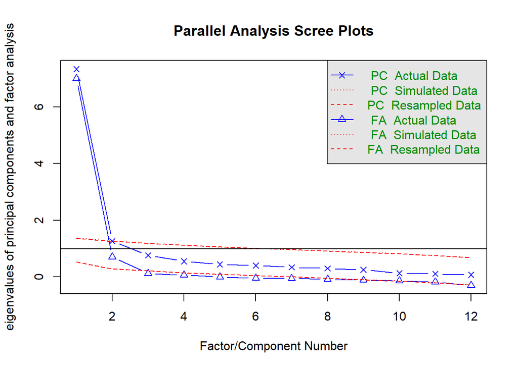

```
## Parallel analysis suggests that the number of factors =  2  and the number of components =  1
```

#### FA Output

**Initial FA run as 1 factor per item**

```
## Factor Analysis with confidence intervals using method = fa(r = TIAS_Items_Study_1_DF, nfactors = 12, n.iter = 25, rotate = "oblimin",
##     fm = "ml")
## Factor Analysis using method =  ml
## Call: fa(r = TIAS_Items_Study_1_DF, nfactors = 12, n.iter = 25, rotate = "oblimin",
##     fm = "ml")
## Standardized loadings (pattern matrix) based upon correlation matrix
##           ML1   ML2   ML4   ML3   ML5 ML6 ML7 ML8 ML9 ML10 ML11 ML12   h2   u2
## TiAS_1  -0.12  0.70 -0.09  0.04 -0.04   0   0   0   0    0    0    0 0.63 0.37
## TiAS_2   0.01  0.77  0.06  0.01  0.00   0   0   0   0    0    0    0 0.53 0.47
## TiAS_3   0.07  0.49 -0.25 -0.14  0.19   0   0   0   0    0    0    0 0.63 0.37
## TiAS_4  -0.46  0.21  0.05 -0.12  0.28   0   0   0   0    0    0    0 0.71 0.29
## TiAS_5  -0.15  0.40 -0.01 -0.20  0.20   0   0   0   0    0    0    0 0.59 0.41
## TiAS_6   0.74 -0.03  0.11  0.13  0.03   0   0   0   0    0    0    0 0.88 0.12
## TiAS_7   0.17 -0.01  0.62  0.00 -0.11   0   0   0   0    0    0    0 0.67 0.33
## TiAS_8   0.10 -0.12  0.60  0.10  0.11   0   0   0   0    0    0    0 0.62 0.38
## TiAS_9   0.96 -0.03 -0.02  0.01  0.04   0   0   0   0    0    0    0 0.90 0.10
## TiAS_10  0.95  0.00  0.01 -0.05 -0.03   0   0   0   0    0    0    0 0.88 0.12
## TiAS_11  0.68  0.00  0.20  0.08 -0.08   0   0   0   0    0    0    0 0.89 0.11
## TiAS_12  0.21  0.15  0.06  0.39  0.02   0   0   0   0    0    0    0 0.28 0.72
##         com
## TiAS_1  1.1
## TiAS_2  1.0
## TiAS_3  2.1
## TiAS_4  2.3
## TiAS_5  2.4
## TiAS_6  1.1
## TiAS_7  1.2
## TiAS_8  1.3
## TiAS_9  1.0
## TiAS_10 1.0
## TiAS_11 1.2
## TiAS_12 1.9
##
##                        ML1  ML2  ML4  ML3  ML5  ML6  ML7  ML8  ML9 ML10 ML11
## SS loadings           3.88 1.94 1.38 0.59 0.41 0.00 0.00 0.00 0.00 0.00 0.00
## Proportion Var        0.32 0.16 0.11 0.05 0.03 0.00 0.00 0.00 0.00 0.00 0.00
## Cumulative Var        0.32 0.49 0.60 0.65 0.68 0.68 0.68 0.68 0.68 0.68 0.68
## Proportion Explained  0.47 0.24 0.17 0.07 0.05 0.00 0.00 0.00 0.00 0.00 0.00
## Cumulative Proportion 0.47 0.71 0.88 0.95 1.00 1.00 1.00 1.00 1.00 1.00 1.00
##                       ML12
```

[output cut: 139 more lines]

```
## ML7-ML8   -2.1e-13  2.4e-22 2.5e-13
## ML7-ML9   -2.1e-13  2.4e-22 2.5e-13
## ML7-ML10  -2.1e-13  2.4e-22 2.5e-13
## ML7-ML11  -2.1e-13  2.4e-22 2.5e-13
## ML7-ML12  -2.1e-13  2.4e-22 2.5e-13
## ML8-ML9   -1.9e-19  2.4e-22 2.8e-19
## ML8-ML10  -1.9e-19  2.4e-22 2.8e-19
## ML8-ML11  -1.9e-19  2.4e-22 2.8e-19
## ML8-ML12  -1.9e-19  2.4e-22 2.8e-19
## ML9-ML10  -1.9e-19  2.4e-22 2.8e-19
## ML9-ML11  -1.9e-19  2.4e-22 2.8e-19
## ML9-ML12  -1.9e-19  2.4e-22 2.8e-19
## ML10-ML11 -1.9e-19  2.4e-22 2.8e-19
## ML10-ML12 -1.9e-19  2.4e-22 2.8e-19
## ML11-ML12 -1.9e-19  2.4e-22 2.8e-19
```

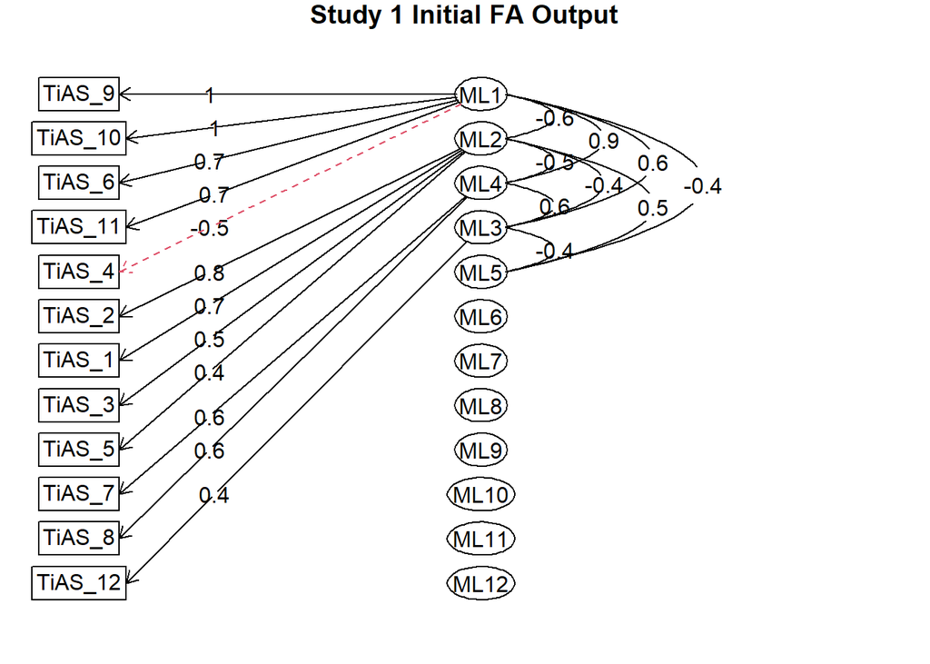

**FA run as X number of factors determined by Kaiser’s rule and parallel analysis scree plot**  
Kaiser’s rule is simply to retain factors whose eigenvalues are > 1  
(Kaiser’s rule is based on the assumption that to retain a factor that explains less variance than a single original variable is not psychometrically reasonable.)

```
## Factor Analysis with confidence intervals using method = fa(r = TIAS_Items_Study_1_DF, nfactors = 2, n.iter = 25, rotate = "oblimin",
##     fm = "ml")
## Factor Analysis using method =  ml
## Call: fa(r = TIAS_Items_Study_1_DF, nfactors = 2, n.iter = 25, rotate = "oblimin",
##     fm = "ml")
## Standardized loadings (pattern matrix) based upon correlation matrix
##           ML1   ML2   h2   u2 com
## TiAS_1  -0.11  0.71 0.63 0.37 1.0
## TiAS_2   0.16  0.84 0.56 0.44 1.1
## TiAS_3  -0.24  0.61 0.61 0.39 1.3
## TiAS_4  -0.48  0.40 0.66 0.34 1.9
## TiAS_5  -0.27  0.54 0.56 0.44 1.5
## TiAS_6   0.93  0.00 0.88 0.12 1.0
## TiAS_7   0.77  0.00 0.60 0.40 1.0
## TiAS_8   0.74  0.01 0.54 0.46 1.0
## TiAS_9   0.94  0.00 0.89 0.11 1.0
## TiAS_10  0.93 -0.01 0.88 0.12 1.0
## TiAS_11  0.93 -0.03 0.90 0.10 1.0
## TiAS_12  0.53  0.15 0.20 0.80 1.2
##
##                        ML1  ML2
## SS loadings           5.58 2.32
## Proportion Var        0.47 0.19
## Cumulative Var        0.47 0.66
## Proportion Explained  0.71 0.29
## Cumulative Proportion 0.71 1.00
##
##  With factor correlations of
##       ML1   ML2
## ML1  1.00 -0.67
## ML2 -0.67  1.00
##
## Mean item complexity =  1.2
## Test of the hypothesis that 2 factors are sufficient.
##
## The degrees of freedom for the null model are  66  and the objective function was  10.73 with Chi Square of  2834.62
## The degrees of freedom for the model are 43  and the objective function was  0.41
##
## The root mean square of the residuals (RMSR) is  0.03
## The df corrected root mean square of the residuals is  0.03
```

[output cut: 17 more lines]

```
## TiAS_2  -0.04  0.16  0.25  0.69  0.84  0.92
## TiAS_3  -0.40 -0.24 -0.05  0.35  0.61  0.91
## TiAS_4  -0.68 -0.48 -0.38  0.19  0.40  0.55
## TiAS_5  -0.46 -0.27 -0.09  0.30  0.54  0.77
## TiAS_6   0.86  0.93  0.99 -0.12  0.00  0.07
## TiAS_7   0.63  0.77  0.89 -0.15  0.00  0.10
## TiAS_8   0.62  0.74  0.87 -0.14  0.01  0.16
## TiAS_9   0.88  0.94  0.99 -0.11  0.00  0.07
## TiAS_10  0.86  0.93  0.99 -0.10 -0.01  0.06
## TiAS_11  0.88  0.93  0.98 -0.09 -0.03  0.03
## TiAS_12  0.32  0.53  0.70 -0.12  0.15  0.36
##
##  Interfactor correlations and bootstrapped confidence intervals
##         lower estimate upper
## ML1-ML2 -0.76    -0.67 -0.53
```

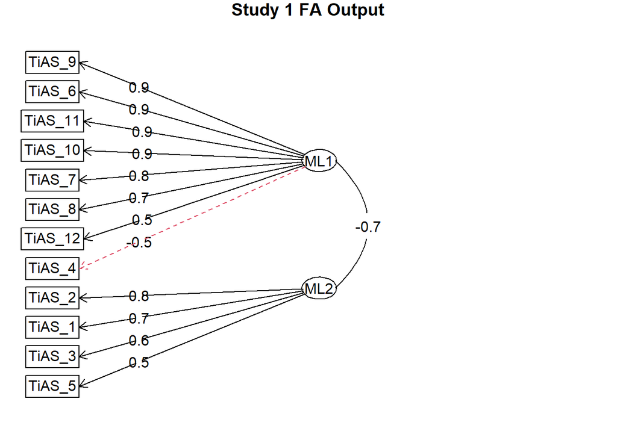

#### Cronbach’s Alpha

**Factor 1**

```
##
## Reliability analysis
## Call: psych::alpha(x = TIAS_Items_Study_1_DF[, c(1, 2, 3, 5)], na.rm = TRUE,
##     check.keys = TRUE, n.iter = 1, use = "pairwise", warnings = TRUE)
##
##   raw_alpha std.alpha G6(smc) average_r S/N   ase mean  sd median_r
##       0.84      0.84    0.81      0.57 5.2 0.016  3.5 1.4     0.58
##
##     95% confidence boundaries
##          lower alpha upper
## Feldt     0.80  0.84  0.87
## Duhachek  0.81  0.84  0.87
##
##  Reliability if an item is dropped:
##        raw_alpha std.alpha G6(smc) average_r S/N alpha se  var.r med.r
## TiAS_1      0.78      0.78    0.71      0.54 3.5    0.023 0.0051  0.51
## TiAS_2      0.81      0.81    0.75      0.59 4.3    0.020 0.0021  0.62
## TiAS_3      0.79      0.79    0.72      0.55 3.7    0.023 0.0048  0.54
## TiAS_5      0.80      0.81    0.74      0.58 4.2    0.021 0.0043  0.62
##
##  Item statistics
##          n raw.r std.r r.cor r.drop mean  sd
## TiAS_1 270  0.84  0.85  0.78   0.71  3.3 1.7
## TiAS_2 270  0.79  0.80  0.70   0.63  3.3 1.6
## TiAS_3 270  0.84  0.83  0.76   0.70  3.8 1.9
## TiAS_5 270  0.81  0.81  0.71   0.65  3.5 1.8
##
## Non missing response frequency for each item
##           1    2    3    4    5    6    7 miss
## TiAS_1 0.16 0.24 0.17 0.19 0.11 0.10 0.03    0
## TiAS_2 0.18 0.19 0.15 0.24 0.14 0.08 0.02    0
## TiAS_3 0.14 0.15 0.16 0.10 0.23 0.14 0.07    0
## TiAS_5 0.17 0.16 0.16 0.19 0.19 0.09 0.05    0
```

**Factor 2**

```
##
## Reliability analysis
## Call: psych::alpha(x = TIAS_Items_Study_1_DF[, c(4, 6, 7, 8, 9, 10,
##     11, 12)], na.rm = TRUE, check.keys = TRUE, n.iter = 1, use = "pairwise",
##     warnings = TRUE)
##
##   raw_alpha std.alpha G6(smc) average_r S/N    ase mean  sd median_r
##       0.94      0.94    0.94      0.65  15 0.0058  3.5 1.4      0.7
##
##     95% confidence boundaries
##          lower alpha upper
## Feldt     0.92  0.94  0.95
## Duhachek  0.92  0.94  0.95
##
##  Reliability if an item is dropped:
##         raw_alpha std.alpha G6(smc) average_r S/N alpha se var.r med.r
## TiAS_4-      0.93      0.93    0.94      0.66  14   0.0063 0.041  0.70
## TiAS_6       0.92      0.92    0.92      0.62  11   0.0076 0.037  0.69
## TiAS_7       0.93      0.93    0.93      0.65  13   0.0065 0.042  0.70
## TiAS_8       0.93      0.93    0.94      0.66  14   0.0063 0.042  0.71
## TiAS_9       0.92      0.92    0.92      0.62  11   0.0075 0.035  0.70
## TiAS_10      0.92      0.92    0.92      0.62  11   0.0075 0.036  0.70
## TiAS_11      0.92      0.92    0.92      0.61  11   0.0076 0.036  0.69
## TiAS_12      0.95      0.95    0.95      0.74  20   0.0043 0.012  0.71
##
##  Item statistics
##           n raw.r std.r r.cor r.drop mean  sd
## TiAS_4- 270  0.79  0.79  0.74   0.72  3.4 1.8
## TiAS_6  270  0.93  0.93  0.94   0.91  3.4 1.8
## TiAS_7  270  0.82  0.82  0.79   0.76  3.4 1.6
## TiAS_8  270  0.78  0.79  0.74   0.71  3.5 1.5
## TiAS_9  270  0.93  0.93  0.94   0.90  3.6 1.7
## TiAS_10 270  0.92  0.92  0.93   0.89  3.7 1.8
## TiAS_11 270  0.94  0.94  0.95   0.92  3.5 1.7
## TiAS_12 270  0.54  0.54  0.43   0.42  3.8 1.8
##
## Non missing response frequency for each item
##            1    2    3    4    5    6    7 miss
## TiAS_4  0.07 0.09 0.09 0.13 0.23 0.25 0.13    0
## TiAS_6  0.17 0.21 0.16 0.15 0.16 0.10 0.05    0
## TiAS_7  0.14 0.18 0.20 0.24 0.15 0.07 0.02    0
## TiAS_8  0.13 0.15 0.19 0.31 0.13 0.07 0.03    0
## TiAS_9  0.14 0.16 0.16 0.17 0.22 0.11 0.04    0
## TiAS_10 0.16 0.15 0.18 0.15 0.17 0.14 0.05    0
## TiAS_11 0.15 0.18 0.19 0.17 0.16 0.13 0.03    0
## TiAS_12 0.14 0.14 0.15 0.19 0.21 0.12 0.06    0
```

**All items**

```
##
## Reliability analysis
## Call: psych::alpha(x = TIAS_Items_Study_1_DF[, c(1, 2, 3, 4, 5, 6,
##     7, 8, 9, 10, 11, 12)], na.rm = TRUE, check.keys = TRUE, n.iter = 1,
##     use = "pairwise", warnings = TRUE)
##
##   raw_alpha std.alpha G6(smc) average_r S/N    ase mean  sd median_r
##       0.94      0.94    0.95      0.56  15 0.0055  3.9 1.3     0.57
##
##     95% confidence boundaries
##          lower alpha upper
## Feldt     0.93  0.94  0.95
## Duhachek  0.93  0.94  0.95
##
##  Reliability if an item is dropped:
##         raw_alpha std.alpha G6(smc) average_r S/N alpha se var.r med.r
## TiAS_1-      0.93      0.93    0.94      0.56  14   0.0057 0.035  0.59
## TiAS_2-      0.94      0.94    0.95      0.59  16   0.0053 0.029  0.59
## TiAS_3-      0.93      0.93    0.95      0.56  14   0.0059 0.037  0.56
## TiAS_4-      0.93      0.93    0.94      0.55  13   0.0062 0.035  0.56
## TiAS_5-      0.93      0.93    0.95      0.56  14   0.0059 0.037  0.57
## TiAS_6       0.93      0.93    0.94      0.53  13   0.0065 0.030  0.56
## TiAS_7       0.93      0.93    0.94      0.55  14   0.0060 0.034  0.57
## TiAS_8       0.93      0.93    0.95      0.56  14   0.0059 0.035  0.58
## TiAS_9       0.93      0.93    0.94      0.53  13   0.0065 0.030  0.56
## TiAS_10      0.93      0.93    0.94      0.54  13   0.0065 0.030  0.56
## TiAS_11      0.93      0.93    0.94      0.53  12   0.0066 0.030  0.56
## TiAS_12      0.94      0.94    0.95      0.61  17   0.0050 0.022  0.60
##
##  Item statistics
##           n raw.r std.r r.cor r.drop mean  sd
## TiAS_1- 270  0.72  0.72  0.69   0.66  4.7 1.7
## TiAS_2- 270  0.58  0.58  0.53   0.50  4.7 1.6
## TiAS_3- 270  0.76  0.76  0.73   0.71  4.2 1.9
## TiAS_4- 270  0.82  0.82  0.80   0.78  3.4 1.8
## TiAS_5- 270  0.75  0.75  0.72   0.70  4.5 1.8
## TiAS_6  270  0.90  0.90  0.91   0.88  3.4 1.8
## TiAS_7  270  0.78  0.78  0.76   0.73  3.4 1.6
## TiAS_8  270  0.74  0.75  0.72   0.70  3.5 1.5
## TiAS_9  270  0.90  0.90  0.91   0.88  3.6 1.7
## TiAS_10 270  0.89  0.89  0.90   0.87  3.7 1.8
## TiAS_11 270  0.92  0.91  0.92   0.89  3.5 1.7
## TiAS_12 270  0.48  0.47  0.40   0.38  3.8 1.8
##
## Non missing response frequency for each item
##            1    2    3    4    5    6    7 miss
## TiAS_1  0.16 0.24 0.17 0.19 0.11 0.10 0.03    0
## TiAS_2  0.18 0.19 0.15 0.24 0.14 0.08 0.02    0
## TiAS_3  0.14 0.15 0.16 0.10 0.23 0.14 0.07    0
## TiAS_4  0.07 0.09 0.09 0.13 0.23 0.25 0.13    0
## TiAS_5  0.17 0.16 0.16 0.19 0.19 0.09 0.05    0
## TiAS_6  0.17 0.21 0.16 0.15 0.16 0.10 0.05    0
## TiAS_7  0.14 0.18 0.20 0.24 0.15 0.07 0.02    0
## TiAS_8  0.13 0.15 0.19 0.31 0.13 0.07 0.03    0
## TiAS_9  0.14 0.16 0.16 0.17 0.22 0.11 0.04    0
## TiAS_10 0.16 0.15 0.18 0.15 0.17 0.14 0.05    0
## TiAS_11 0.15 0.18 0.19 0.17 0.16 0.13 0.03    0
## TiAS_12 0.14 0.14 0.15 0.19 0.21 0.12 0.06    0
```

### Study 2 - Intergrity

#### Suitability Checks

**Kaiser-Meyer-Olkin (KMO) (should be > ~.5 or .6)

```
## Kaiser-Meyer-Olkin factor adequacy
## Call: KMO(r = TIAS_Items_Study_2_DF)
## Overall MSA =  0.94
## MSA for each item =
##  TiAS_1  TiAS_2  TiAS_3  TiAS_4  TiAS_5  TiAS_6  TiAS_7  TiAS_8  TiAS_9 TiAS_10
##    0.94    0.94    0.96    0.93    0.96    0.94    0.96    0.95    0.92    0.92
## TiAS_11 TiAS_12
##    0.95    0.84
```

Bartlett’s test of sphericity (should be significant)**

```
##  Bartlett's Test of Sphericity
##
## Call: bart_spher(x = TIAS_Items_Study_2_DF)
##
##      X2 = 2761.258
##      df = 66
## p-value < 2.22e-16
```

Correlation matrix between TIAS items and calculated eigenvalues for factors

```
##  [1] 7.6017904 1.0168968 0.8462360 0.5233341 0.4126022 0.3766914 0.2775183
##  [8] 0.2713230 0.2240876 0.1876239 0.1338794 0.1280168
```

Parallel Analysis Scree Plots are a great way to tell factors.  
Changes in gradient indicate factors

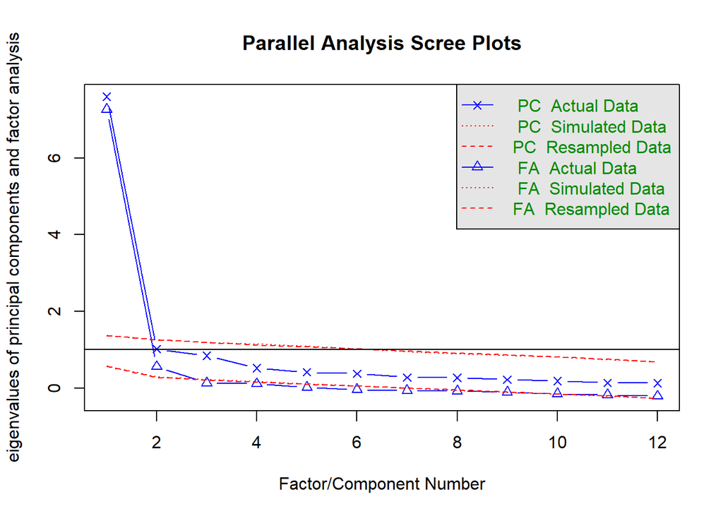

```
## Parallel analysis suggests that the number of factors =  2  and the number of components =  1
```

#### FA Output

**Initial FA run as 1 factor per item**

```
## Factor Analysis with confidence intervals using method = fa(r = TIAS_Items_Study_2_DF, nfactors = 12, n.iter = 25, rotate = "oblimin",
##     fm = "ml")
## Factor Analysis using method =  ml
## Call: fa(r = TIAS_Items_Study_2_DF, nfactors = 12, n.iter = 25, rotate = "oblimin",
##     fm = "ml")
## Standardized loadings (pattern matrix) based upon correlation matrix
##           ML2   ML1   ML4   ML5   ML3 ML6 ML7 ML8 ML9 ML10 ML11 ML12   h2   u2
## TiAS_1   0.85  0.00  0.00 -0.04 -0.09   0   0   0   0    0    0    0 0.80 0.20
## TiAS_2   0.86  0.01  0.03  0.07 -0.11   0   0   0   0    0    0    0 0.72 0.28
## TiAS_3   0.77  0.00 -0.05 -0.15  0.05   0   0   0   0    0    0    0 0.74 0.26
## TiAS_4   0.73 -0.18  0.05 -0.09  0.17   0   0   0   0    0    0    0 0.74 0.26
## TiAS_5   0.71 -0.02 -0.18  0.14  0.04   0   0   0   0    0    0    0 0.58 0.42
## TiAS_6  -0.21  0.44  0.23  0.19  0.03   0   0   0   0    0    0    0 0.83 0.17
## TiAS_7  -0.03  0.35  0.11  0.26  0.24   0   0   0   0    0    0    0 0.56 0.44
## TiAS_8  -0.30  0.31  0.06  0.05  0.33   0   0   0   0    0    0    0 0.66 0.34
## TiAS_9  -0.01  0.93 -0.02 -0.05 -0.04   0   0   0   0    0    0    0 0.78 0.22
## TiAS_10  0.01  0.82  0.07  0.05  0.06   0   0   0   0    0    0    0 0.83 0.17
## TiAS_11 -0.27  0.45  0.10  0.21  0.10   0   0   0   0    0    0    0 0.85 0.15
## TiAS_12  0.04  0.03  0.55 -0.03 -0.02   0   0   0   0    0    0    0 0.29 0.71
##         com
## TiAS_1  1.0
## TiAS_2  1.1
## TiAS_3  1.1
## TiAS_4  1.3
## TiAS_5  1.2
## TiAS_6  2.5
## TiAS_7  3.0
## TiAS_8  3.1
## TiAS_9  1.0
## TiAS_10 1.0
## TiAS_11 2.4
## TiAS_12 1.0
##
##                        ML2  ML1  ML4  ML5  ML3 ML6 ML7 ML8 ML9 ML10 ML11 ML12
## SS loadings           3.86 2.93 0.70 0.52 0.37 0.0 0.0 0.0 0.0  0.0  0.0  0.0
## Proportion Var        0.32 0.24 0.06 0.04 0.03 0.0 0.0 0.0 0.0  0.0  0.0  0.0
## Cumulative Var        0.32 0.57 0.62 0.67 0.70 0.7 0.7 0.7 0.7  0.7  0.7  0.7
## Proportion Explained  0.46 0.35 0.08 0.06 0.04 0.0 0.0 0.0 0.0  0.0  0.0  0.0
## Cumulative Proportion 0.46 0.81 0.89 0.96 1.00 1.0 1.0 1.0 1.0  1.0  1.0  1.0
##
```

[output cut: 133 more lines]

```
## ML7-ML8   -1.8e-13  6.2e-23  2.4e-13
## ML7-ML9   -1.8e-13  6.2e-23  2.4e-13
## ML7-ML10  -1.8e-13  6.2e-23  2.4e-13
## ML7-ML11  -1.8e-13  6.2e-23  2.4e-13
## ML7-ML12  -1.8e-13  6.2e-23  2.4e-13
## ML8-ML9   -8.2e-16  6.2e-23  1.0e-15
## ML8-ML10  -8.2e-16  6.2e-23  1.0e-15
## ML8-ML11  -8.2e-16  6.2e-23  1.0e-15
## ML8-ML12  -8.2e-16  6.2e-23  1.0e-15
## ML9-ML10  -8.2e-16  6.2e-23  1.0e-15
## ML9-ML11  -8.2e-16  6.2e-23  1.0e-15
## ML9-ML12  -8.2e-16  6.2e-23  1.0e-15
## ML10-ML11 -8.2e-16  6.2e-23  1.0e-15
## ML10-ML12 -8.2e-16  6.2e-23  1.0e-15
## ML11-ML12 -8.2e-16  6.2e-23  1.0e-15
```

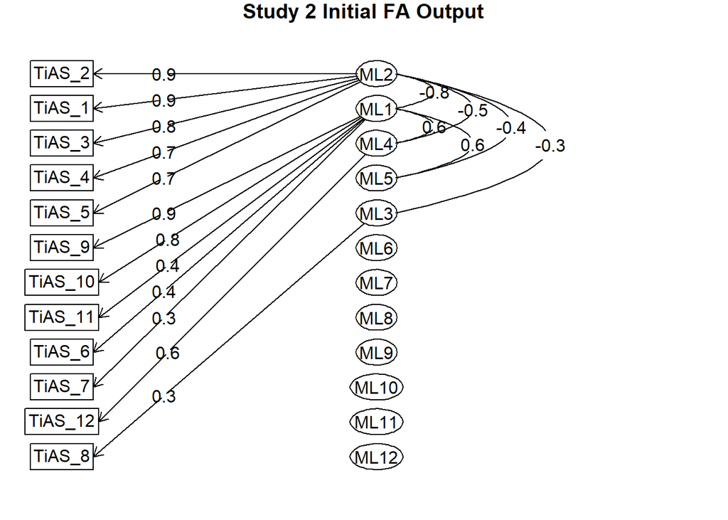

**FA run as X number of factors determined by Kaiser’s rule and parallel analysis scree plot**  
Kaiser’s rule is simply to retain factors whose eigenvalues are > 1  
(Kaiser’s rule is based on the assumption that to retain a factor that explains less variance than a single original variable is not psychometrically reasonable.)

```
## Factor Analysis with confidence intervals using method = fa(r = TIAS_Items_Study_2_DF, nfactors = 2, n.iter = 25, rotate = "oblimin",
##     fm = "ml")
## Factor Analysis using method =  ml
## Call: fa(r = TIAS_Items_Study_2_DF, nfactors = 2, n.iter = 25, rotate = "oblimin",
##     fm = "ml")
## Standardized loadings (pattern matrix) based upon correlation matrix
##           ML1   ML2   h2   u2 com
## TiAS_1  -0.01  0.91 0.83 0.17 1.0
## TiAS_2   0.10  0.93 0.73 0.27 1.0
## TiAS_3  -0.17  0.71 0.72 0.28 1.1
## TiAS_4  -0.18  0.68 0.69 0.31 1.1
## TiAS_5  -0.04  0.70 0.53 0.47 1.0
## TiAS_6   0.83 -0.10 0.83 0.17 1.0
## TiAS_7   0.73  0.03 0.51 0.49 1.0
## TiAS_8   0.49 -0.31 0.58 0.42 1.7
## TiAS_9   0.88  0.02 0.74 0.26 1.0
## TiAS_10  0.98  0.07 0.84 0.16 1.0
## TiAS_11  0.76 -0.19 0.85 0.15 1.1
## TiAS_12  0.43  0.11 0.12 0.88 1.1
##
##                        ML1  ML2
## SS loadings           4.34 3.62
## Proportion Var        0.36 0.30
## Cumulative Var        0.36 0.66
## Proportion Explained  0.55 0.45
## Cumulative Proportion 0.55 1.00
##
##  With factor correlations of
##      ML1  ML2
## ML1  1.0 -0.8
## ML2 -0.8  1.0
##
## Mean item complexity =  1.1
## Test of the hypothesis that 2 factors are sufficient.
##
## The degrees of freedom for the null model are  66  and the objective function was  10.45 with Chi Square of  2761.26
## The degrees of freedom for the model are 43  and the objective function was  0.44
##
## The root mean square of the residuals (RMSR) is  0.03
## The df corrected root mean square of the residuals is  0.04
```

[output cut: 17 more lines]

```
## TiAS_2  -0.04  0.10  0.21  0.83  0.93  0.99
## TiAS_3  -0.32 -0.17 -0.04  0.55  0.71  0.86
## TiAS_4  -0.32 -0.18 -0.07  0.52  0.68  0.82
## TiAS_5  -0.23 -0.04  0.11  0.48  0.70  0.88
## TiAS_6   0.63  0.83  1.00 -0.29 -0.10  0.05
## TiAS_7   0.58  0.73  0.86 -0.13  0.03  0.18
## TiAS_8   0.32  0.49  0.67 -0.47 -0.31 -0.14
## TiAS_9   0.73  0.88  0.99 -0.11  0.02  0.12
## TiAS_10  0.89  0.98  1.05 -0.06  0.07  0.18
## TiAS_11  0.66  0.76  0.89 -0.27 -0.19 -0.10
## TiAS_12  0.27  0.43  0.53 -0.05  0.11  0.21
##
##  Interfactor correlations and bootstrapped confidence intervals
##         lower estimate upper
## ML1-ML2  -1.2     -0.8 -0.24
```

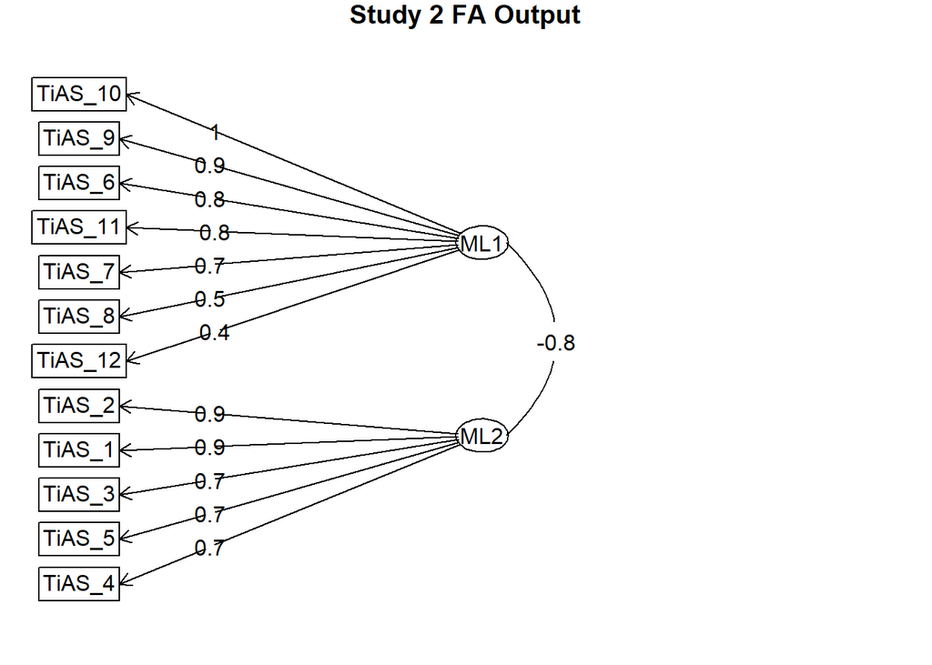

#### Cronbach’s Alpha

**Factor 1**

```
##
## Reliability analysis
## Call: psych::alpha(x = TIAS_Items_Study_2_DF[, c(1, 2, 3, 5)], na.rm = TRUE,
##     check.keys = TRUE, n.iter = 1, use = "pairwise", warnings = TRUE)
##
##   raw_alpha std.alpha G6(smc) average_r S/N    ase mean  sd median_r
##        0.9       0.9    0.88      0.69   9 0.0097  3.7 1.7     0.68
##
##     95% confidence boundaries
##          lower alpha upper
## Feldt     0.88   0.9  0.92
## Duhachek  0.88   0.9  0.92
##
##  Reliability if an item is dropped:
##        raw_alpha std.alpha G6(smc) average_r S/N alpha se  var.r med.r
## TiAS_1      0.85      0.85    0.79      0.65 5.7    0.016 0.0019  0.63
## TiAS_2      0.86      0.86    0.82      0.68 6.4    0.014 0.0044  0.66
## TiAS_3      0.87      0.87    0.83      0.69 6.7    0.013 0.0073  0.66
## TiAS_5      0.90      0.90    0.86      0.75 8.9    0.011 0.0018  0.76
##
##  Item statistics
##          n raw.r std.r r.cor r.drop mean  sd
## TiAS_1 270  0.92  0.91  0.89   0.84  3.8 2.0
## TiAS_2 270  0.89  0.89  0.85   0.80  3.7 2.0
## TiAS_3 270  0.88  0.88  0.82   0.78  4.1 2.0
## TiAS_5 270  0.82  0.83  0.73   0.70  3.3 1.7
##
## Non missing response frequency for each item
##           1    2    3    4    5    6    7 miss
## TiAS_1 0.15 0.18 0.17 0.13 0.11 0.10 0.15    0
## TiAS_2 0.19 0.14 0.16 0.18 0.08 0.13 0.13    0
## TiAS_3 0.12 0.15 0.16 0.11 0.17 0.14 0.15    0
## TiAS_5 0.20 0.18 0.18 0.19 0.12 0.09 0.04    0
```

**Factor 2**

```
##
## Reliability analysis
## Call: psych::alpha(x = TIAS_Items_Study_2_DF[, c(4, 6, 7, 8, 9, 10,
##     11, 12)], na.rm = TRUE, check.keys = TRUE, n.iter = 1, use = "pairwise",
##     warnings = TRUE)
##
##   raw_alpha std.alpha G6(smc) average_r S/N    ase mean  sd median_r
##       0.92      0.92    0.92      0.58  11 0.0075  3.8 1.3     0.64
##
##     95% confidence boundaries
##          lower alpha upper
## Feldt      0.9  0.92  0.93
## Duhachek   0.9  0.92  0.93
##
##  Reliability if an item is dropped:
##         raw_alpha std.alpha G6(smc) average_r  S/N alpha se  var.r med.r
## TiAS_4-      0.91      0.91    0.92      0.59 10.0   0.0083 0.0454  0.65
## TiAS_6       0.89      0.89    0.90      0.54  8.4   0.0098 0.0433  0.62
## TiAS_7       0.91      0.91    0.92      0.59 10.0   0.0084 0.0491  0.67
## TiAS_8       0.91      0.91    0.92      0.58  9.7   0.0086 0.0482  0.65
## TiAS_9       0.90      0.90    0.91      0.56  8.9   0.0093 0.0440  0.64
## TiAS_10      0.89      0.90    0.90      0.55  8.6   0.0096 0.0418  0.63
## TiAS_11      0.89      0.89    0.90      0.54  8.4   0.0099 0.0395  0.62
## TiAS_12      0.94      0.94    0.94      0.68 15.2   0.0059 0.0095  0.67
##
##  Item statistics
##           n raw.r std.r r.cor r.drop mean  sd
## TiAS_4- 270  0.78  0.77  0.73   0.69  3.7 2.0
## TiAS_6  270  0.91  0.91  0.92   0.88  3.8 1.7
## TiAS_7  270  0.76  0.76  0.71   0.69  3.7 1.5
## TiAS_8  270  0.79  0.79  0.75   0.72  3.5 1.7
## TiAS_9  270  0.86  0.86  0.85   0.82  4.0 1.6
## TiAS_10 270  0.89  0.89  0.90   0.85  4.1 1.7
## TiAS_11 270  0.91  0.91  0.92   0.88  3.8 1.7
## TiAS_12 270  0.45  0.45  0.33   0.31  3.8 1.7
##
## Non missing response frequency for each item
##            1    2    3    4    5    6    7 miss
## TiAS_4  0.10 0.13 0.15 0.10 0.17 0.17 0.18    0
## TiAS_6  0.11 0.11 0.18 0.23 0.19 0.13 0.04    0
## TiAS_7  0.10 0.11 0.19 0.33 0.16 0.07 0.04    0
## TiAS_8  0.19 0.12 0.15 0.27 0.14 0.08 0.05    0
## TiAS_9  0.09 0.13 0.13 0.25 0.21 0.14 0.04    0
## TiAS_10 0.10 0.11 0.10 0.24 0.24 0.14 0.07    0
## TiAS_11 0.14 0.12 0.14 0.21 0.21 0.13 0.04    0
## TiAS_12 0.10 0.16 0.16 0.22 0.20 0.11 0.05    0
```

**All items**

```
##
## Reliability analysis
## Call: psych::alpha(x = TIAS_Items_Study_2_DF[, c(1, 2, 3, 4, 5, 6,
##     7, 8, 9, 10, 11, 12)], na.rm = TRUE, check.keys = TRUE, n.iter = 1,
##     use = "pairwise", warnings = TRUE)
##
##   raw_alpha std.alpha G6(smc) average_r S/N    ase mean  sd median_r
##       0.94      0.94    0.95      0.58  17 0.0049    4 1.4     0.63
##
##     95% confidence boundaries
##          lower alpha upper
## Feldt     0.93  0.94  0.95
## Duhachek  0.93  0.94  0.95
##
##  Reliability if an item is dropped:
##         raw_alpha std.alpha G6(smc) average_r S/N alpha se  var.r med.r
## TiAS_1-      0.94      0.94    0.95      0.57  14   0.0057 0.0311  0.62
## TiAS_2-      0.94      0.94    0.95      0.58  15   0.0054 0.0319  0.63
## TiAS_3-      0.94      0.94    0.95      0.57  15   0.0056 0.0319  0.62
## TiAS_4-      0.94      0.94    0.95      0.57  15   0.0055 0.0316  0.62
## TiAS_5-      0.94      0.94    0.95      0.59  16   0.0052 0.0341  0.64
## TiAS_6       0.93      0.93    0.94      0.56  14   0.0057 0.0317  0.61
## TiAS_7       0.94      0.94    0.95      0.59  16   0.0051 0.0328  0.63
## TiAS_8       0.94      0.94    0.95      0.58  15   0.0053 0.0336  0.63
## TiAS_9       0.94      0.94    0.95      0.57  15   0.0054 0.0323  0.63
## TiAS_10      0.94      0.94    0.94      0.57  14   0.0055 0.0314  0.62
## TiAS_11      0.93      0.93    0.94      0.56  14   0.0057 0.0297  0.61
## TiAS_12      0.95      0.95    0.96      0.65  20   0.0043 0.0097  0.65
##
##  Item statistics
##           n raw.r std.r r.cor r.drop mean  sd
## TiAS_1- 270  0.86  0.85  0.85   0.83  4.2 2.0
## TiAS_2- 270  0.80  0.79  0.77   0.75  4.3 2.0
## TiAS_3- 270  0.84  0.83  0.82   0.80  3.9 2.0
## TiAS_4- 270  0.82  0.82  0.80   0.78  3.7 2.0
## TiAS_5- 270  0.74  0.73  0.70   0.69  4.7 1.7
## TiAS_6  270  0.89  0.89  0.89   0.86  3.8 1.7
## TiAS_7  270  0.70  0.71  0.68   0.65  3.7 1.5
## TiAS_8  270  0.79  0.79  0.77   0.74  3.5 1.7
## TiAS_9  270  0.82  0.83  0.82   0.79  4.0 1.6
## TiAS_10 270  0.85  0.86  0.86   0.82  4.1 1.7
## TiAS_11 270  0.90  0.90  0.90   0.88  3.8 1.7
## TiAS_12 270  0.39  0.40  0.32   0.30  3.8 1.7
##
## Non missing response frequency for each item
##            1    2    3    4    5    6    7 miss
## TiAS_1  0.15 0.18 0.17 0.13 0.11 0.10 0.15    0
## TiAS_2  0.19 0.14 0.16 0.18 0.08 0.13 0.13    0
## TiAS_3  0.12 0.15 0.16 0.11 0.17 0.14 0.15    0
## TiAS_4  0.10 0.13 0.15 0.10 0.17 0.17 0.18    0
## TiAS_5  0.20 0.18 0.18 0.19 0.12 0.09 0.04    0
## TiAS_6  0.11 0.11 0.18 0.23 0.19 0.13 0.04    0
## TiAS_7  0.10 0.11 0.19 0.33 0.16 0.07 0.04    0
## TiAS_8  0.19 0.12 0.15 0.27 0.14 0.08 0.05    0
## TiAS_9  0.09 0.13 0.13 0.25 0.21 0.14 0.04    0
## TiAS_10 0.10 0.11 0.10 0.24 0.24 0.14 0.07    0
## TiAS_11 0.14 0.12 0.14 0.21 0.21 0.13 0.04    0
## TiAS_12 0.10 0.16 0.16 0.22 0.20 0.11 0.05    0
```

## Statistical Assumption Tests

### Study 1 - Performance

#### Normality

| dataframe | column | p |
| --- | --- | --- |
| Car_HP_DF | TIAS | 6.890412e-01 |
| Car_HP_DF | Behavioural_Measure | 1.193605e-02 |
| Car_HP_DF | Human_Trust_Propensity | 3.519316e-03 |
| Car_HP_DF | Machine_Trust_Propensity | 3.368363e-01 |
| Car_LP_DF | TIAS | 1.253723e-01 |
| Car_LP_DF | Behavioural_Measure | 1.098786e-03 |
| Car_LP_DF | Human_Trust_Propensity | 8.239220e-02 |
| Car_LP_DF | Machine_Trust_Propensity | 4.847943e-03 |
| CellSelect_HP_DF | TIAS | 8.138609e-02 |
| CellSelect_HP_DF | Behavioural_Measure | 5.064289e-04 |
| CellSelect_HP_DF | Human_Trust_Propensity | 2.880009e-01 |
| CellSelect_HP_DF | Machine_Trust_Propensity | 7.071417e-04 |
| CellSelect_LP_DF | TIAS | 1.757810e-01 |
| CellSelect_LP_DF | Behavioural_Measure | 1.054990e-03 |
| CellSelect_LP_DF | Human_Trust_Propensity | 2.778294e-02 |
| CellSelect_LP_DF | Machine_Trust_Propensity | 1.212610e-02 |
| DataDoc_HP_DF | TIAS | 5.447290e-01 |
| DataDoc_HP_DF | Behavioural_Measure | 3.296527e-02 |
| DataDoc_HP_DF | Human_Trust_Propensity | 1.100942e-02 |
| DataDoc_HP_DF | Machine_Trust_Propensity | 8.765728e-03 |
| DataDoc_LP_DF | TIAS | 1.690175e-02 |
| DataDoc_LP_DF | Behavioural_Measure | 2.326121e-07 |
| DataDoc_LP_DF | Human_Trust_Propensity | 3.710249e-01 |
| DataDoc_LP_DF | Machine_Trust_Propensity | 4.266542e-03 |

#### Homogeneity of Variance

```
##
##  Bartlett test of homogeneity of variances
##
## data:  TIAS by Condition
## Bartlett's K-squared = 6.7082, df = 1, p-value = 0.009597
```

```
##
##  Bartlett test of homogeneity of variances
##
## data:  TIAS by Condition
## Bartlett's K-squared = 0.014439, df = 1, p-value = 0.9044
```

```
##
##  Bartlett test of homogeneity of variances
##
## data:  TIAS by Condition
## Bartlett's K-squared = 0.0078075, df = 1, p-value = 0.9296
```

```
##
##  Bartlett test of homogeneity of variances
##
## data:  Behavioural_Measure by Condition
## Bartlett's K-squared = 3.0829, df = 1, p-value = 0.07912
```

```
##
##  Bartlett test of homogeneity of variances
##
## data:  Behavioural_Measure by Condition
## Bartlett's K-squared = 3.5573, df = 1, p-value = 0.05928
```

```
##
##  Bartlett test of homogeneity of variances
##
## data:  Behavioural_Measure by Condition
## Bartlett's K-squared = 13.701, df = 1, p-value = 0.0002143
```

#### Regression Assumptions

##### Linearity

**Linearity of TIAS Score**

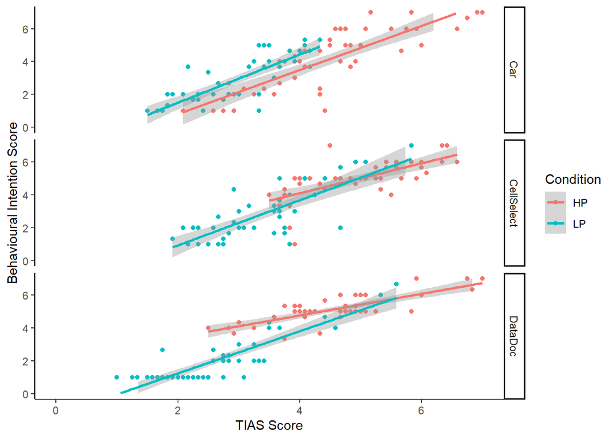

**Linearity of Human Trust Propensity Score**

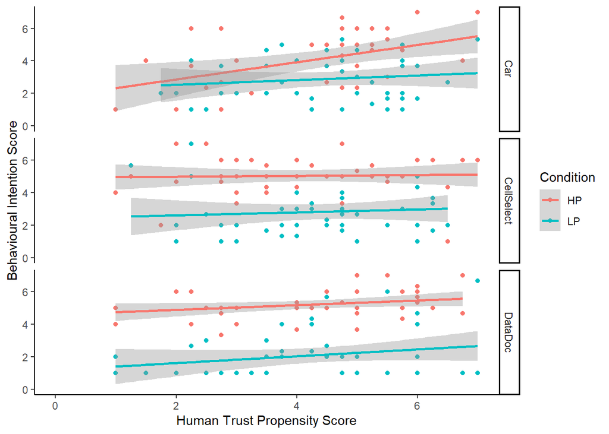

**Linearity of Machine Trust Propensity Score**

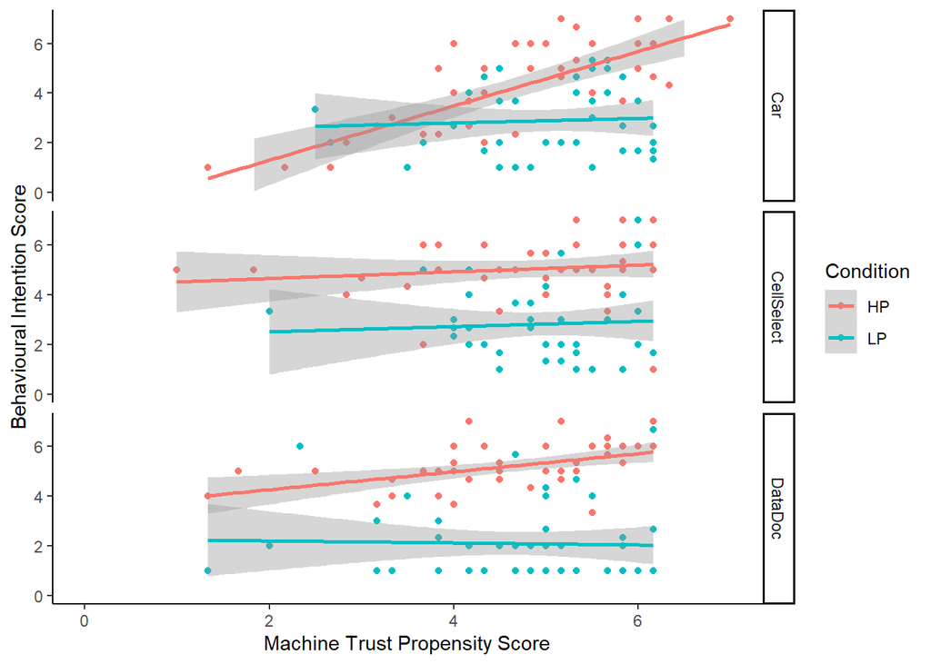

##### Multicolinearity

VIF values <5 required

```
## Collapsed Regression Study 1 VIF values:  1.032248 1.09485 1.091334 1.21608 1.158404 1.054074
## Car Regression Study 1 VIF values:  1.078979 1.0567 1.114332 1.294097 1.201339 1.100954
## Cell Select Regression Study 1 VIF values:  1.163118 1.161376 1.148731 1.317067 1.158628 1.036237
## DataDoc Regression Study 1 VIF values:  1.003162 1.128784 1.091995 1.155524 1.169113 1.071699
```

```
## Collapsed Regression Study 1 : Variables with VIF > 5 :
## Car Regression Study 1 : Variables with VIF > 5 :
## Cell Select Regression Study 1 : Variables with VIF > 5 :
## DataDoc Regression Study 1 : Variables with VIF > 5 :
```

##### Independence of Errors

We want that statistic to be as close to 2 as possible, and generally anything between 1 and 3 is fine.

```
##  lag Autocorrelation D-W Statistic p-value
##    1     -0.01322776      2.012715   0.912
##  Alternative hypothesis: rho != 0
##  lag Autocorrelation D-W Statistic p-value
##    1     -0.09975133      2.149349   0.524
##  Alternative hypothesis: rho != 0
##  lag Autocorrelation D-W Statistic p-value
##    1     -0.07069358      2.139668    0.49
##  Alternative hypothesis: rho != 0
##  lag Autocorrelation D-W Statistic p-value
##    1      -0.2308272       2.45098   0.026
##  Alternative hypothesis: rho != 0
```

##### Normality of Residuals

PP plots

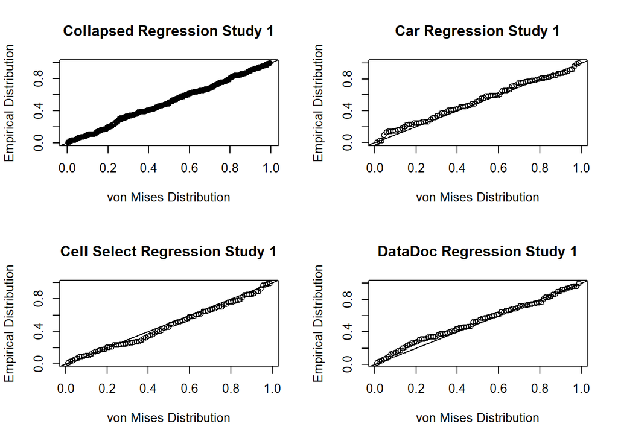

##### Homoscedasticity

Random distribution of points is required. Funelling indicates the homoscedasticity assumption is violated.

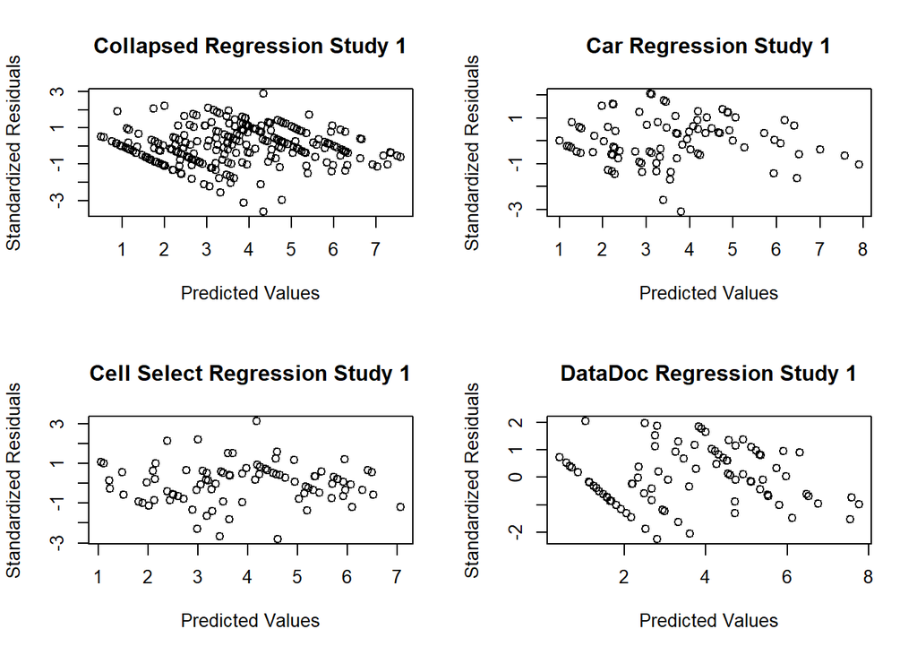

### Study 2 - Integrity

#### Normality

| dataframe | column | p |
| --- | --- | --- |
| Car_HI_DF | TIAS | 0.4947614023 |
| Car_HI_DF | Behavioural_Measure | 0.0002449378 |
| Car_HI_DF | Human_Trust_Propensity | 0.4694767524 |
| Car_HI_DF | Machine_Trust_Propensity | 0.3115905840 |
| Car_LI_DF | TIAS | 0.3000114808 |
| Car_LI_DF | Behavioural_Measure | 0.0152558120 |
| Car_LI_DF | Human_Trust_Propensity | 0.2649433761 |
| Car_LI_DF | Machine_Trust_Propensity | 0.0066940775 |
| CellSelect_HI_DF | TIAS | 0.4104841541 |
| CellSelect_HI_DF | Behavioural_Measure | 0.2230922730 |
| CellSelect_HI_DF | Human_Trust_Propensity | 0.0263839885 |
| CellSelect_HI_DF | Machine_Trust_Propensity | 0.0925482221 |
| CellSelect_LI_DF | TIAS | 0.1610759368 |
| CellSelect_LI_DF | Behavioural_Measure | 0.0089960027 |
| CellSelect_LI_DF | Human_Trust_Propensity | 0.0264711407 |
| CellSelect_LI_DF | Machine_Trust_Propensity | 0.4131108744 |
| Airline_HI_DF | TIAS | 0.4191835647 |
| Airline_HI_DF | Behavioural_Measure | 0.0017953861 |
| Airline_HI_DF | Human_Trust_Propensity | 0.1822974434 |
| Airline_HI_DF | Machine_Trust_Propensity | 0.0138457142 |
| Airline_LI_DF | TIAS | 0.1452001836 |
| Airline_LI_DF | Behavioural_Measure | 0.0003670588 |
| Airline_LI_DF | Human_Trust_Propensity | 0.2736552282 |
| Airline_LI_DF | Machine_Trust_Propensity | 0.1851323644 |

#### Homogeneity of Variance

```
##
##  Bartlett test of homogeneity of variances
##
## data:  TIAS by Condition
## Bartlett's K-squared = 0.019435, df = 1, p-value = 0.8891
```

```
##
##  Bartlett test of homogeneity of variances
##
## data:  TIAS by Condition
## Bartlett's K-squared = 1.1352, df = 1, p-value = 0.2867
```

```
##
##  Bartlett test of homogeneity of variances
##
## data:  TIAS by Condition
## Bartlett's K-squared = 12.153, df = 1, p-value = 0.0004901
```

```
##
##  Bartlett test of homogeneity of variances
##
## data:  Behavioural_Measure by Condition
## Bartlett's K-squared = 0.1197, df = 1, p-value = 0.7294
```

```
##
##  Bartlett test of homogeneity of variances
##
## data:  Behavioural_Measure by Condition
## Bartlett's K-squared = 10.787, df = 1, p-value = 0.001022
```

```
##
##  Bartlett test of homogeneity of variances
##
## data:  Behavioural_Measure by Condition
## Bartlett's K-squared = 9.2865, df = 1, p-value = 0.002308
```

#### Regression Assumptions

##### Linearity

**Linearity of TIAS Score**

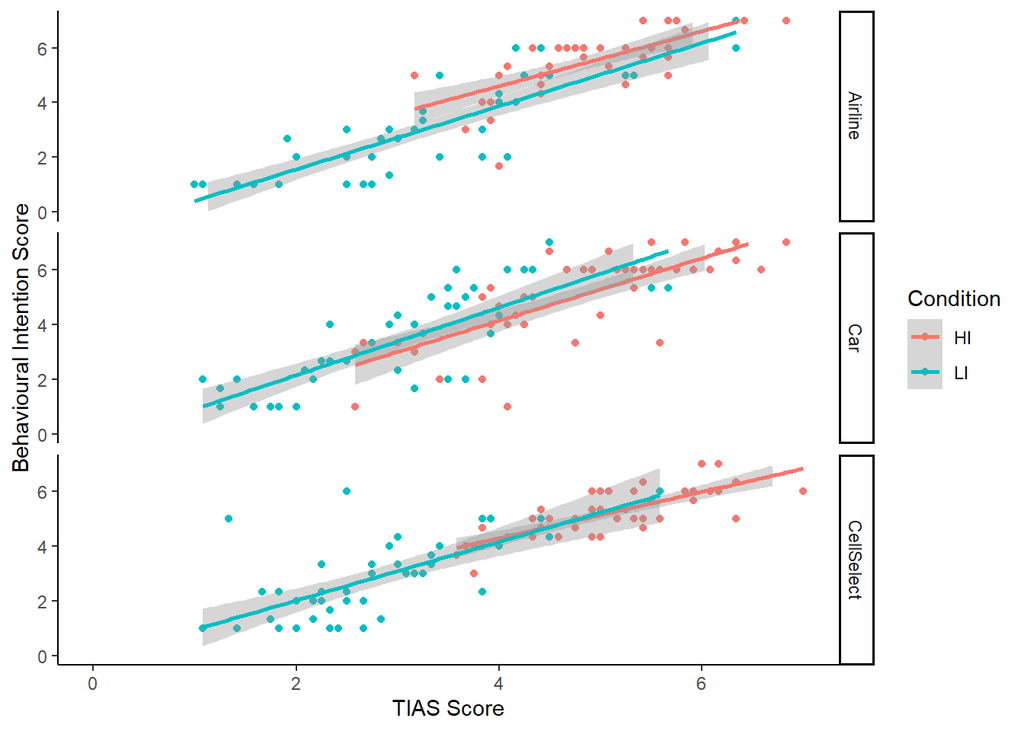

**Linearity of Human Trust Propensity Score**

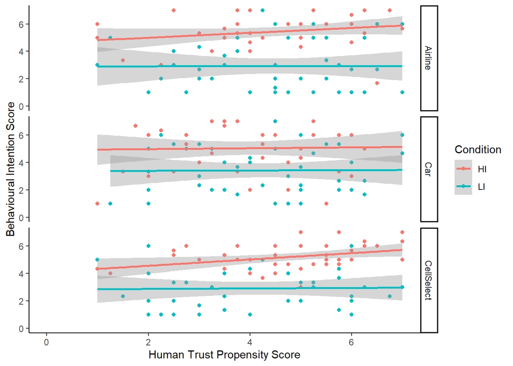

**Linearity of Machine Trust Propensity Score**

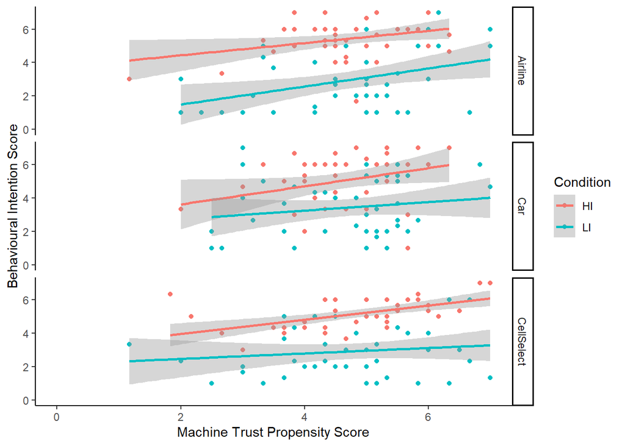

##### Multicolinearity

VIF values <5 required

```
## Collapsed Regression Study 2 VIF values:  1.014657 1.026263 1.065257 1.180931 1.073722 1.142452
## Car Regression Study 2 VIF values:  1.211362 1.071955 1.247649 1.25742 1.183889 1.159695
## Cell Select Regression Study 2 VIF values:  1.069456 1.110227 1.079187 1.223435 1.141791 1.269025
## Airline Regression Study 2 VIF values:  1.009062 1.03637 1.07152 1.242303 1.093867 1.192523
```

```
## Collapsed Regression Study 2 : Variables with VIF > 5 :
## Car Regression Study 2 : Variables with VIF > 5 :
## Cell Select Regression Study 2 : Variables with VIF > 5 :
## Airline Regression Study 2 : Variables with VIF > 5 :
```

##### Independence of Errors

We want that statistic to be as close to 2 as possible, and generally anything between 1 and 3 is fine.

```
##  lag Autocorrelation D-W Statistic p-value
##    1     -0.07085395      2.126845   0.284
##  Alternative hypothesis: rho != 0
##  lag Autocorrelation D-W Statistic p-value
##    1      -0.1230939      2.211217   0.322
##  Alternative hypothesis: rho != 0
##  lag Autocorrelation D-W Statistic p-value
##    1      -0.0917755       2.17374   0.392
##  Alternative hypothesis: rho != 0
##  lag Autocorrelation D-W Statistic p-value
##    1      -0.1661725      2.325021   0.104
##  Alternative hypothesis: rho != 0
```

##### Normality of Residuals

PP plots

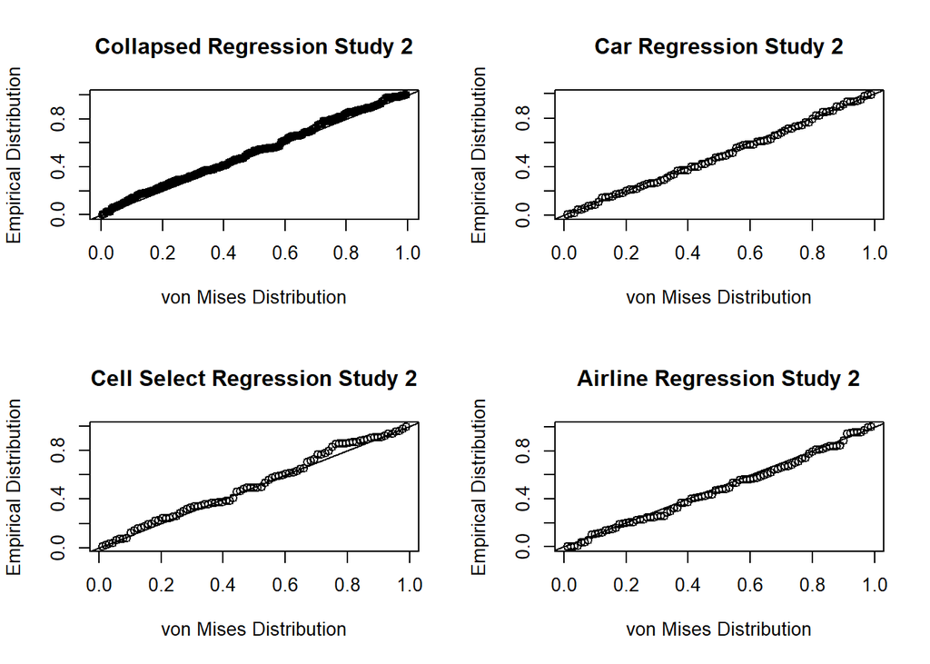

##### Homoscedasticity

Random distribution of points is required. Funelling indicates the homoscedasticity assumption is violated.

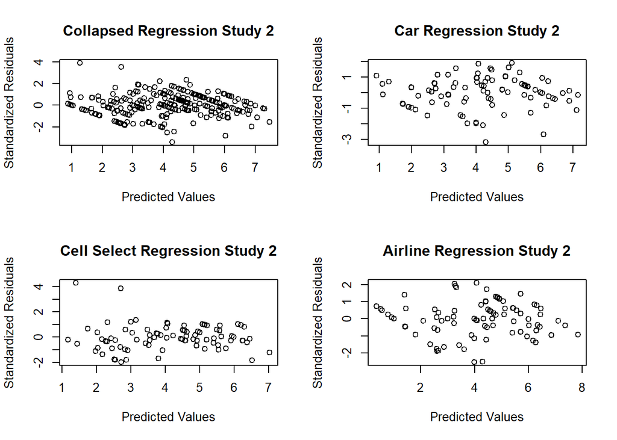

### Histograms

#### Trust

**Trust Scale Score Frequency**

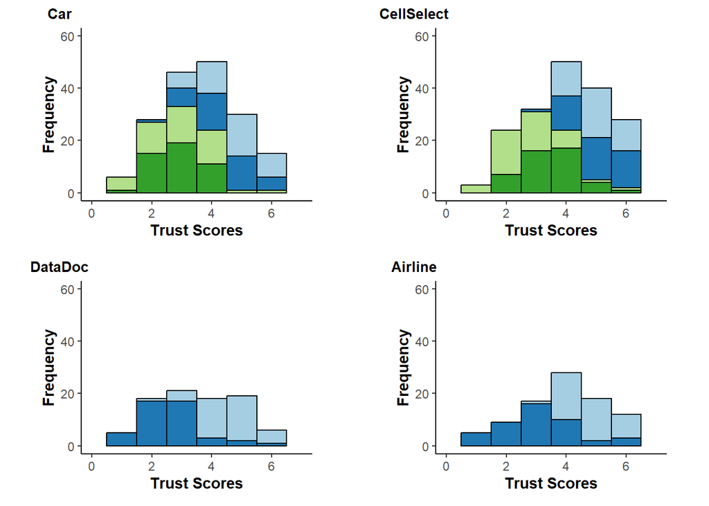

#### Behavioural Measure

**Behavioural Intention Measure Score Frequency**

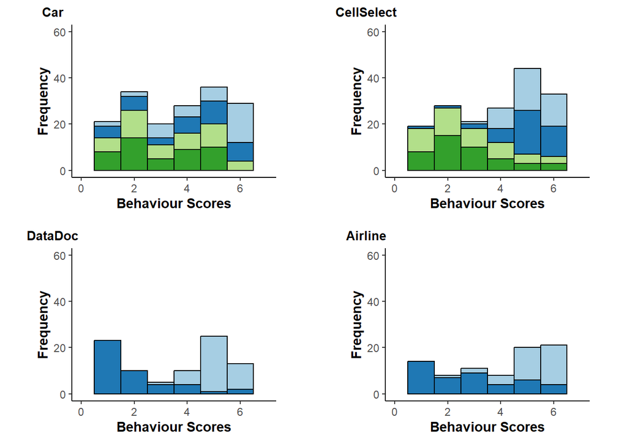

## Summary

### Analysis Summary

**T test assumptions not met**  
Study 1: DataDoc Normality Violated, Car Homogeneity of Variance Violated  
Study 2: Airline Homogeneity of Variance Violated  
**Regression assumptions not met**  
Study 1: Linearity of both trust propensity scores not clear  
Study 2: Linearity of both trust propensity scores not clear

#### **Analysis 1 - T Tests**

One-tailed T-Tests with Bonferroni Corrections

All TIAS scores between high/low performance conditions of each application were **significant (p<0.0001)**  
All TIAS scores between high/low integrity conditions of each application were **significant (p<0.0001)**

#### **Analysis 2 - Correlations**

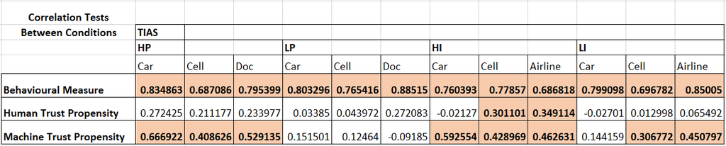

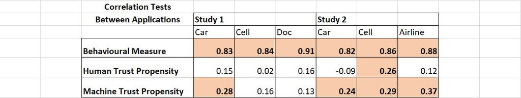

#### **Analysis 3 - Regression**

Study 1 - Collapsed Regression Overview

Collapsed Regression Model Comparison

|  | Behavioural_Measure | Behavioural_Measure | Behavioural_Measure | Behavioural_Measure | Behavioural_Measure | Behavioural_Measure | Behavioural_Measure |
| --- | --- | --- | --- | --- | --- | --- | --- |
| Predictors | p | p | p | p | p | p | p |
| (Intercept) | **<0.001** | **<0.001** | **<0.001** | **<0.001** | **0.001** | **0.002** | **0.022** |
| Gender [Male] |  | 0.348 | 0.339 | 0.328 | 0.550 | 0.578 | 0.545 |
| Education |  |  | 0.708 | 0.793 | 0.929 | 0.898 | 0.815 |
| Age |  |  |  | 0.696 | 0.736 | 0.823 | 0.360 |
| Machine Trust Propensity |  |  |  |  | **0.011** | **0.038** | 0.224 |
| Human Trust Propensity |  |  |  |  |  | 0.303 | 0.185 |
| TIAS |  |  |  |  |  |  | **<0.001** |
| Observations | 264 | 264 | 264 | 264 | 264 | 264 | 264 |
| R<sup>2</sup> / R<sup>2</sup> adjusted | 0.000 / 0.000 | 0.003 / -0.000 | 0.004 / -0.004 | 0.004 / -0.007 | 0.029 / 0.014 | 0.033 / 0.015 | 0.751 / 0.745 |
| AIC | 1076.979 | 1078.089 | 1079.947 | 1081.791 | 1077.140 | 1078.053 | 721.703 |

Study 2 - Collapsed Regression Overview

Collapsed Regression Model Comparison

|  | Behavioural_Measure | Behavioural_Measure | Behavioural_Measure | Behavioural_Measure | Behavioural_Measure | Behavioural_Measure | Behavioural_Measure |
| --- | --- | --- | --- | --- | --- | --- | --- |
| Predictors | p | p | p | p | p | p | p |
| (Intercept) | **<0.001** | **<0.001** | **<0.001** | **<0.001** | **<0.001** | **<0.001** | 0.399 |
| Gender [Male] |  | 0.478 | 0.470 | 0.599 | 0.703 | 0.695 | 0.433 |
| Education |  |  | 0.507 | 0.640 | 0.501 | 0.531 | 0.341 |
| Age |  |  |  | 0.082 | **0.031** | **0.028** | 0.903 |
| Machine Trust Propensity |  |  |  |  | **<0.001** | **<0.001** | 0.524 |
| Human Trust Propensity |  |  |  |  |  | 0.461 | 0.892 |
| TIAS |  |  |  |  |  |  | **<0.001** |
| Observations | 265 | 265 | 265 | 265 | 265 | 265 | 265 |
| R<sup>2</sup> / R<sup>2</sup> adjusted | 0.000 / 0.000 | 0.002 / -0.002 | 0.004 / -0.004 | 0.015 / 0.004 | 0.078 / 0.064 | 0.080 / 0.062 | 0.721 / 0.714 |
| AIC | 1074.964 | 1076.456 | 1078.010 | 1076.934 | 1061.471 | 1062.915 | 748.873 |

#### **Analysis 4**

Number of factors found in TIAS items = 2

**Study 1**

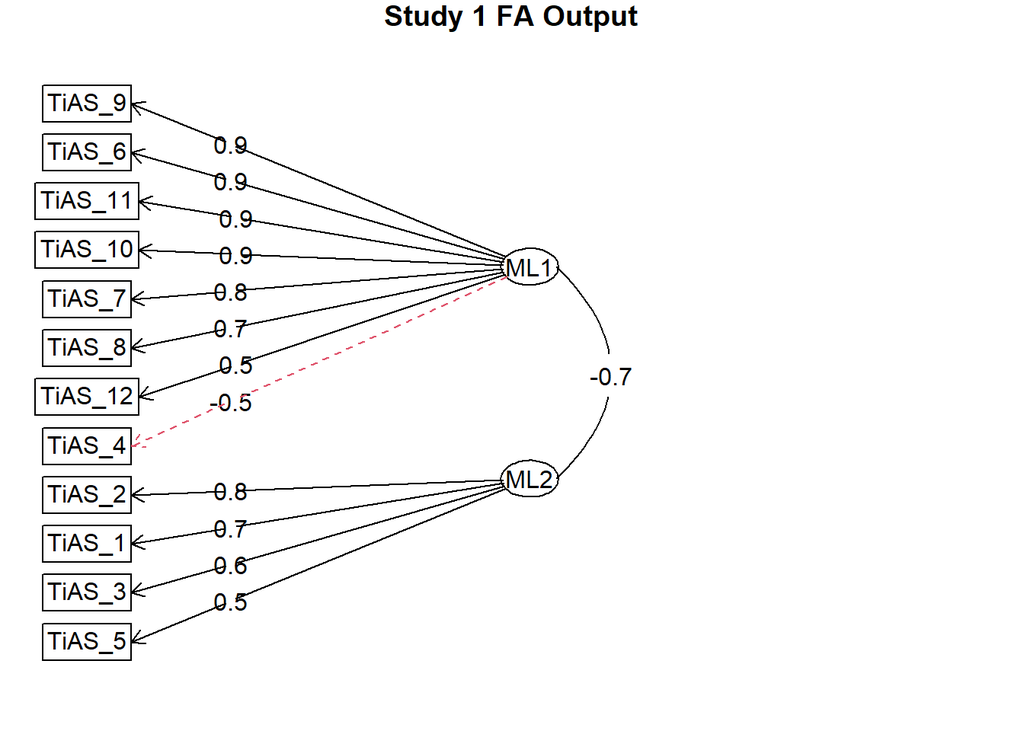

**Study 2**

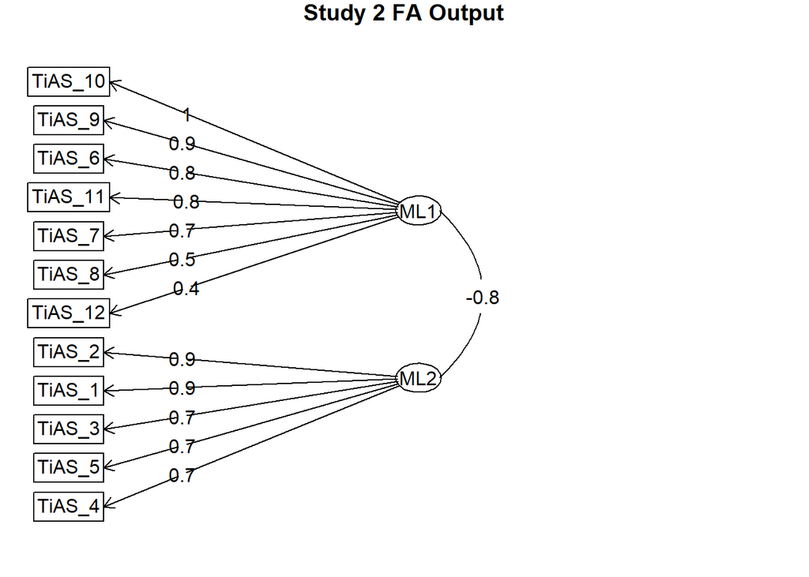

**Cronbach’s alpha estimates for TIAS scale**  
Study 1: alpha = 0.94  
Study 2: alpha = 0.94

### Study 1 Figures

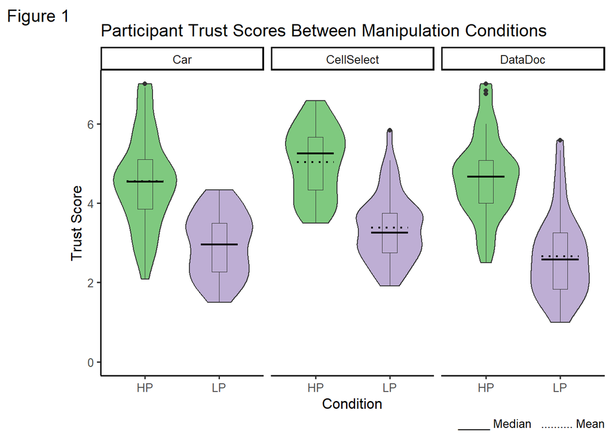

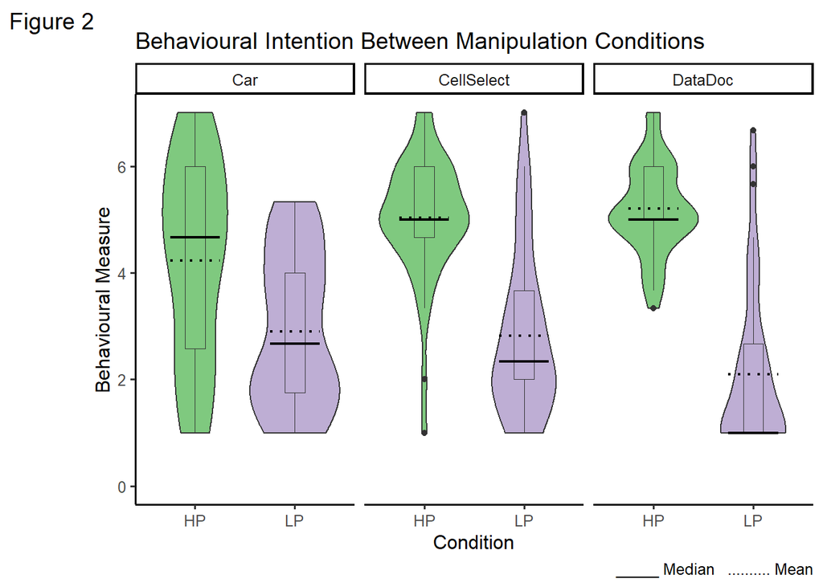

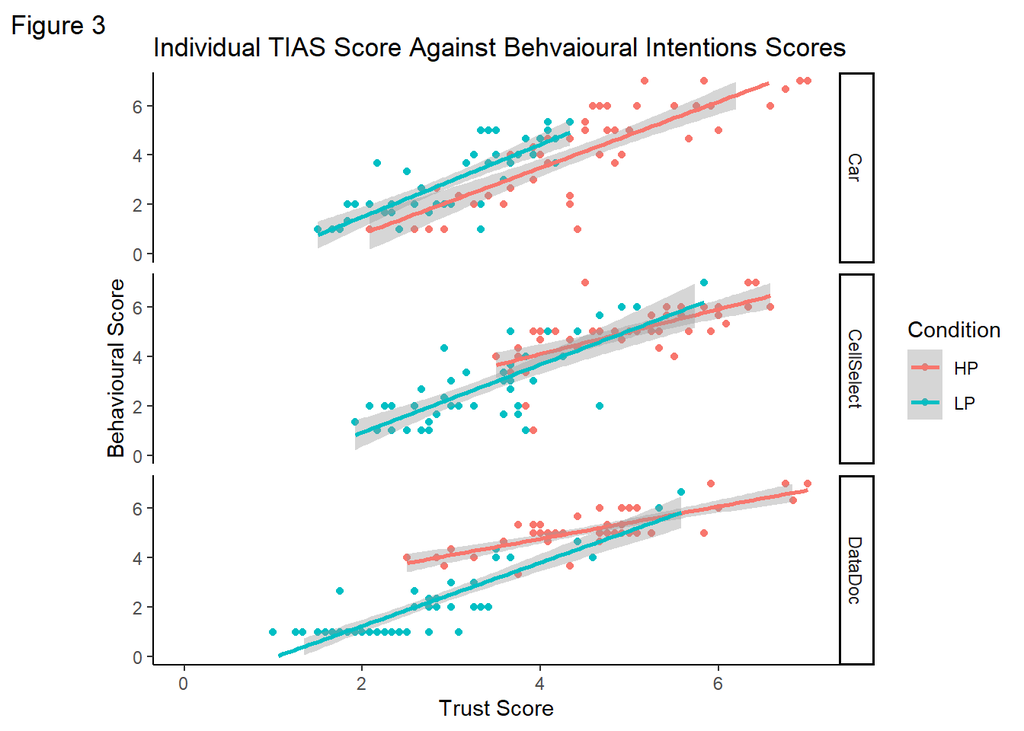

### Study 2 Figures

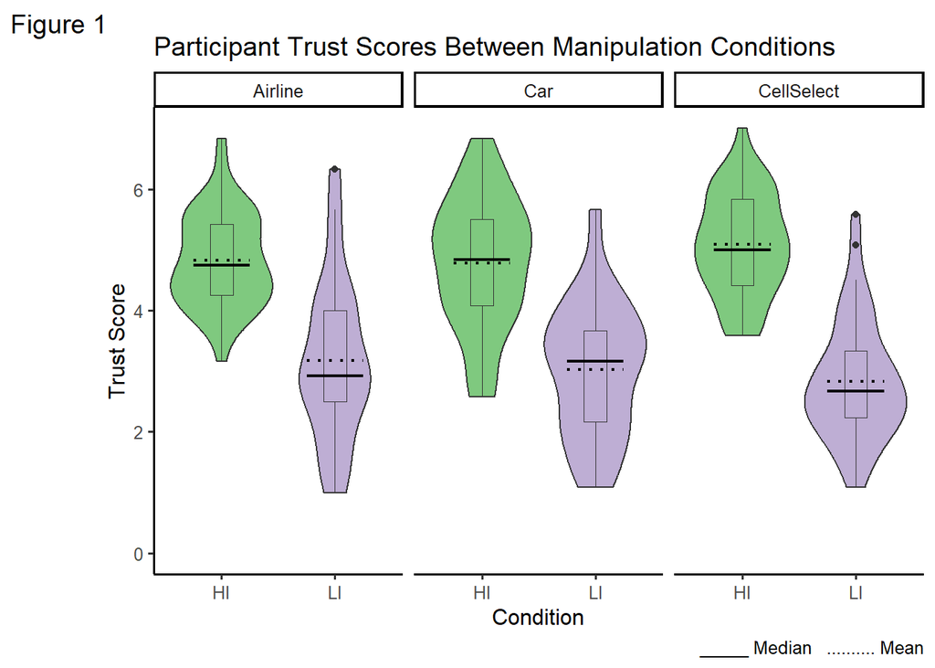

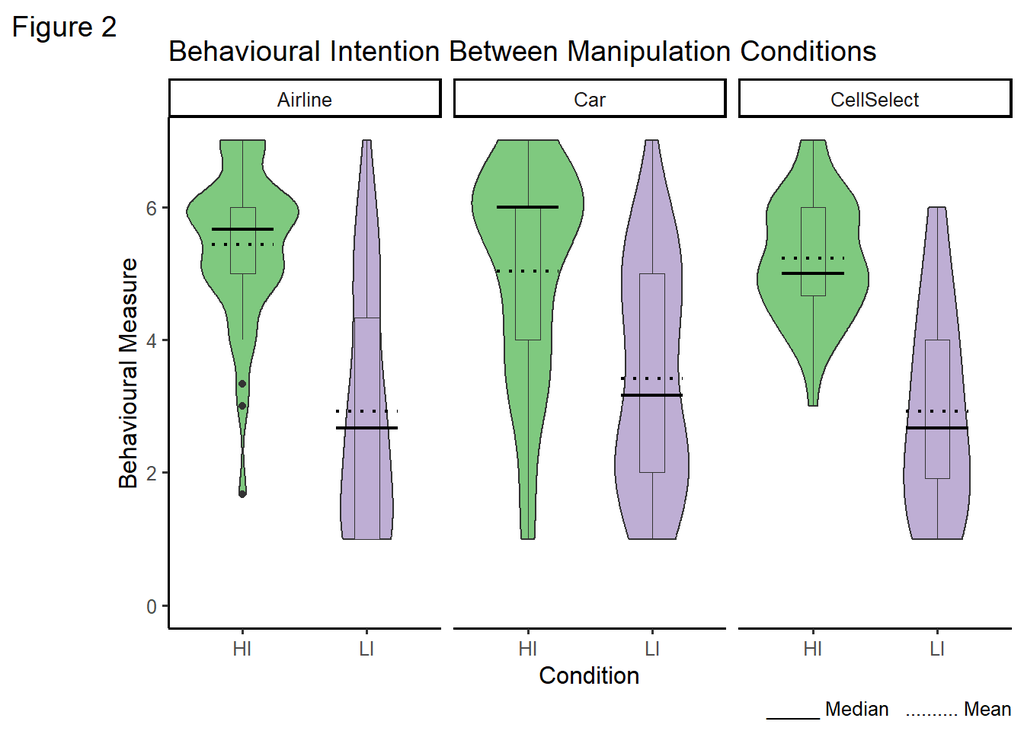

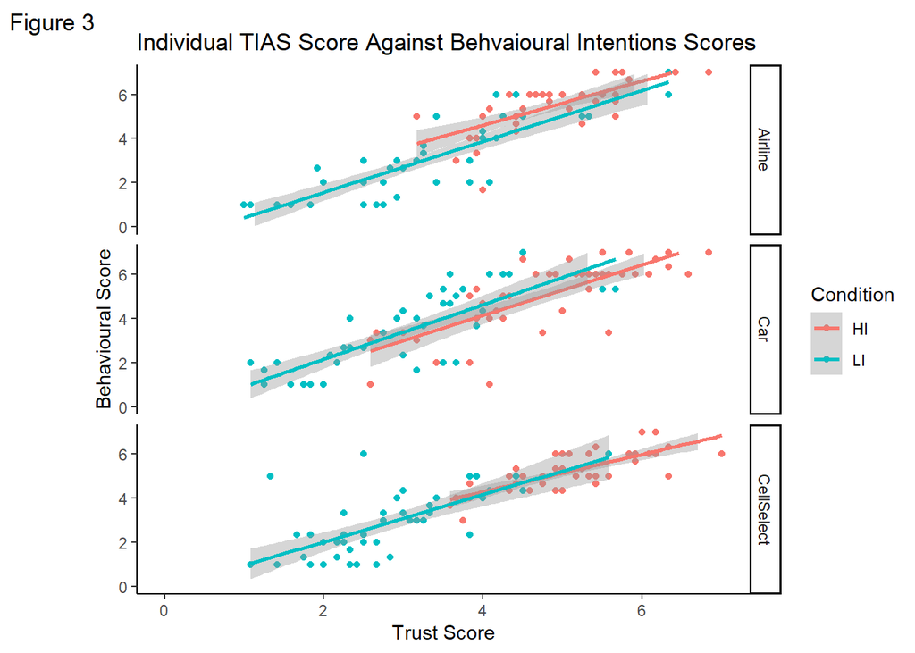

### Factors and TIAS Items

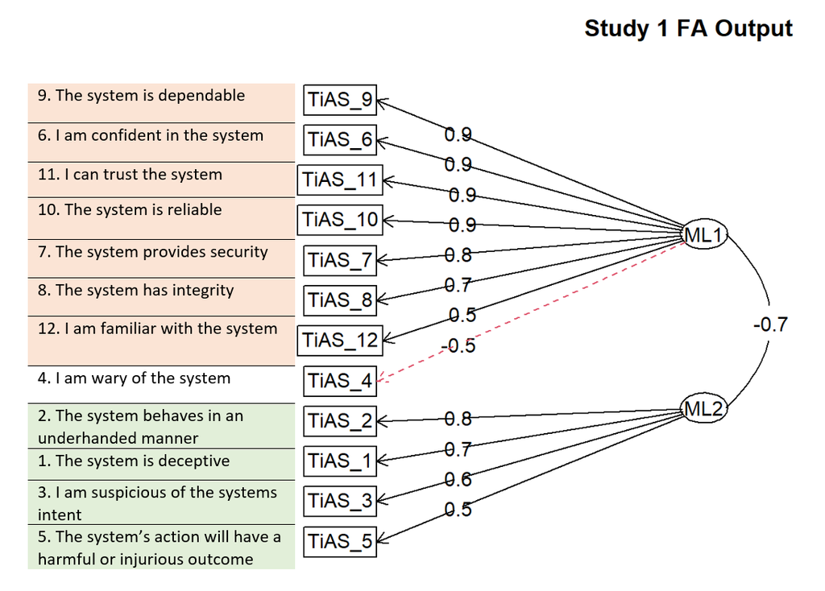

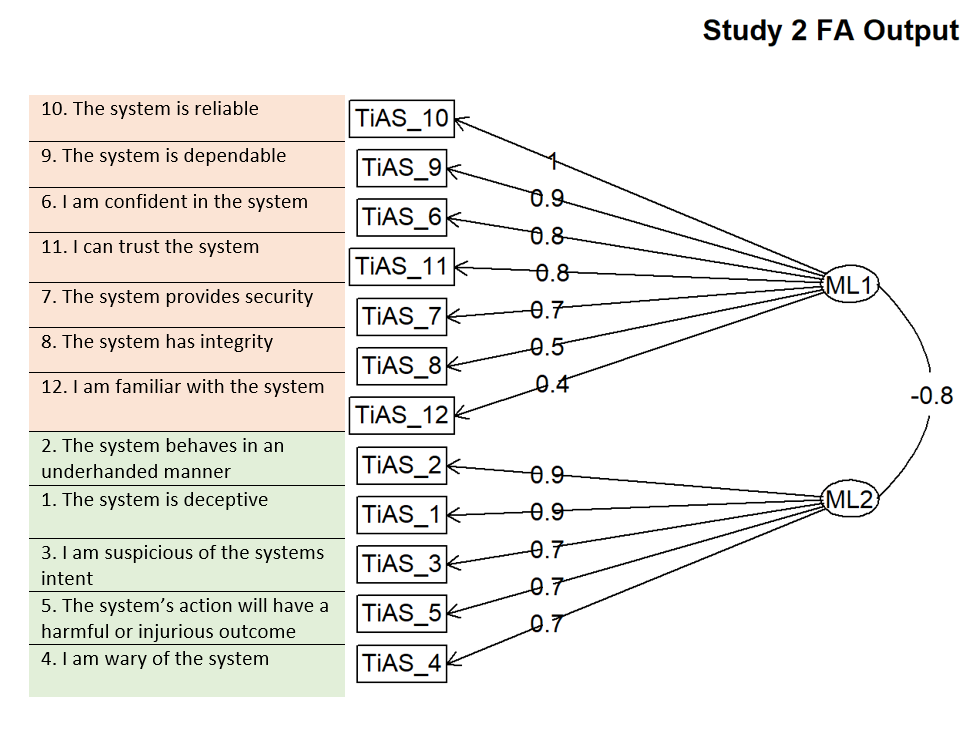

### Human vs Machine Trust Propensity

“Users who distrust other humans tend to be more positive toward machines” (Molina and Sundar 2022)

#### Figures

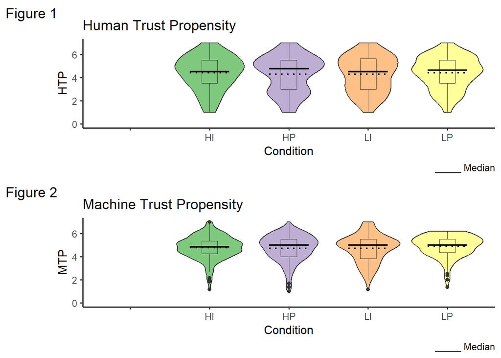

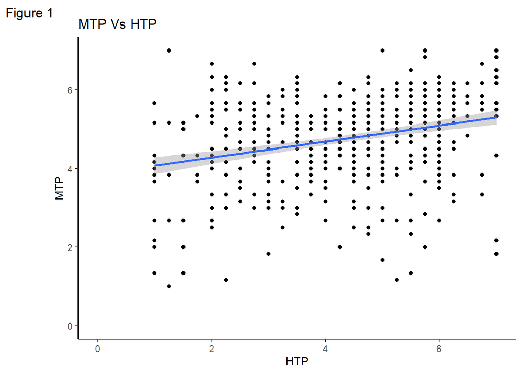

#### Analyses

**Correlation Between Human and Machine Trust Propensity**

```
##
##  Pearson's product-moment correlation
##
## data:  Qualtrics_DF$Human_Trust_Propensity and Qualtrics_DF$Machine_Trust_Propensity
## t = 6.8195, df = 538, p-value = 2.463e-11
## alternative hypothesis: true correlation is not equal to 0
## 95 percent confidence interval:
##  0.2025115 0.3579280
## sample estimates:
##       cor
## 0.2820692
```

**T test between HTP and MTP**

```
##
##  Welch Two Sample t-test
##
## data:  Qualtrics_DF$Human_Trust_Propensity and Qualtrics_DF$Machine_Trust_Propensity
## t = -5.2216, df = 982.32, p-value = 2.166e-07
## alternative hypothesis: true difference in means is not equal to 0
## 95 percent confidence interval:
##  -0.5726229 -0.2597845
## sample estimates:
## mean of x mean of y
##  4.341204  4.757407
```

**Linear Regression between MTP and HTP**

```r
summary(lm(Machine_Trust_Propensity ~ Human_Trust_Propensity, data = Qualtrics_DF))
```

```
##
## Call:
## lm(formula = Machine_Trust_Propensity ~ Human_Trust_Propensity,
##     data = Qualtrics_DF)
##
## Residuals:
##     Min      1Q  Median      3Q     Max
## -3.7764 -0.5586  0.1133  0.7162  2.8739
##
## Coefficients:
##                        Estimate Std. Error t value Pr(>|t|)
## (Intercept)             3.87077    0.13755  28.141  < 2e-16 ***
## Human_Trust_Propensity  0.20424    0.02995   6.819 2.46e-11 ***
## ---
## Signif. codes:  0 '***' 0.001 '**' 0.01 '*' 0.05 '.' 0.1 ' ' 1
##
## Residual standard error: 1.043 on 538 degrees of freedom
##   (1 observation deleted due to missingness)
## Multiple R-squared:  0.07956,    Adjusted R-squared:  0.07785
## F-statistic:  46.5 on 1 and 538 DF,  p-value: 2.463e-11
```

## Written Summary

The study aimed to investigate the Jian et al TIAS scale across various AI applications, and examine the validity, reliability, and generalizability of the TIAS measure.

**Analysis 1: One-Tailed T-Tests with Bonferroni Corrections**

The study’s first hypothesis was that the TIAS scores of the high performance/integrity conditions will be significantly higher than the low performance/integrity conditions for each AI application. To test this, we conducted one-tailed T-tests with Bonferroni corrections between the TIAS distributions of the high/low conditions for each application. The results showed that all TIAS scores between high/low performance conditions of each application were significant (p<0.0001), and all TIAS scores between high/low integrity conditions of each application were significant (p<0.0001). This supports the hypothesis and shows that the manipulation had the intended effect. It also shows that the scale is moving as expected for all three applications.

**Meeting notes:** We were all satisfied that our manipulation had worked.

**Analysis 2: The Convergent Validity of the TIAS with Other Similar Measures**

The study’s second hypothesis was that there will be a positive association between the TIAS scores and the Human Trust Propensity scale and the Machine Trust Propensity scale. To test this, we conducted correlation analyses between the TIAS scores and the Human Trust Propensity Scale, the Machine Trust Propensity Scale, and the Behavioural Intent measure. The results showed that all correlations between the TIAS and Behavioural Intent were greater than 0.8 and all significant. Correlations between collapsed TiAS scores and Machine Trust Propensity Scores were mixed, and many were not significant, though some were as expected. However, when split by high and low conditions, correlations between the high condition Machine Trust Propensity Scores and TIAS scores were between 0.4 and 0.66 and significant for all applications in both studies. Correlations between the low conditions Machine Trust Propensity Score and the TIAS scores were between -0.1-0.45 and had mixed significance between applications. All correlations between the Human Trust Propensity Scores and the TIAS were between -0.02-0.35 and had mixed significance between applications. The results from the correlations support the second hypothesis, showing adequate positive association between the TIAS scores and the Human Trust Propensity Scale and the Machine Trust Propensity Scale.

**Meeting notes:** Discussing whether it is worth reporting the correlations as collapsed and justifying them being slightly weaker than suggested by the literature and using non-significant p-values. OR Reporting the correlations split by condition, therefore reporting twice as many but having to provide justification for why the data looks different between the high and low conditions and why the low condition does not correlate in most cases.

We also discussed the implications of not finding the human trust propensity score correlations as suggested by the literature, implying that human trust propensity may not be as relevant for trust in machines or may be pulled in different directions.

**Analysis 3: Predictive Validity of TIAS**

The study’s third hypothesis was that the TIAS scores will be an independent positive predictor of behavioural intention to use the system. To test this, we conducted hierarchical regression analyses. The behavioural intent measure was used as the dependent variable and the TIAS scores, Human Trust Propensity scores, Machine Trust Propensity scores, Age, Gender, and Level of education as independent variables. The results showed that the TIAS scores explained a significant proportion of variance in the behavioural intent measure in every model between applications. The variance explained by the TIAS Score in all regressions was between than 66%-82%. This supports the hypothesis that the TIAS scores will be an independent positive predictor of intention to use the system.

**Meeting notes:** None of the other variables explained much variation within any of the models, however, this is different when split by condition, where machine trust propensity explains a considerable portion of variance in a few models. This is likely due to the weird data patterns found in the correlation. Again, there was a discussion of trade off of needless analysis complexity (and higher likeliness of errors) against better explaining what is occurring in the data and showing that we are still getting the relationships we are expecting.

**Analysis 4: Reliability of TIAS**

The study aimed to assess whether the TIAS is a reliable measure of trust in AI. To test this, we calculated the Cronbach’s Alpha for TIAS scale responses. The results showed that the Cronbach’s alpha for all the items of the scale was 0.94. The alphas for the items split by study were 0.94. An exploratory factor analysis for each study was run and indicated 2 factors. The first FA for study 1 indicated that items 1,2,3,5 loaded onto one factor, items 6-12 loaded onto the second factor, and item 4 was split between the factors. The second FA for study 2 indicated that items 1-5 loaded onto one factor and items 6-12 loaded onto the second factor. The results from the Cronbach’s alpha and exploratory factor analysis support that the TIAS is a reliable measure of trust in AI.

**Meeting notes:** We discussed the possibility of the two factors being due to methodology (negative items or positive items) or being trust and distrust. It was suggested the best course of action may be to present both options with supporting literature but remaining noncommittal as the purpose of the paper is not to engage in the trust vs distrust debate. The high Cronbach’s alpha suggests that we may just be measuring one latent construct, but other literature suggests we may be measuring two.